*Note: These are notes live-tex’d from a graduate course in topics in representation theory taught by Scott Larson at the University of Georgia in Fall 2021. Any errors or inaccuracies are almost certainly my own.*

# Flag Varieties, Equivariant Cohomology, and K Theory

Lectures by Scott Larson. University of Georgia, Fall 2021

D. Zack Garza

University of Georgia  
dzackgarza@gmail.com

Last updated: 2021-12-04

# 1 First Examples of Flag/Schubert Varieties (Wednesday, August 18)

Course description from Scott’s syllabus:

> Schubert varieties are key examples of algebraic varieties that on one hand have an intrinsic interest and beauty, and on the other hand have many applications to algebraic geometry, algebraic topology, and representation theory; e.g., category ${\mathcal{O}}$, infinite dimensional representation theory of real reductive groups, modular representation theory, polar varieties, Chern classes, Schubert calculus, etc.

> The course goal is to understand Schubert varieties and their algebraic geometry, equivariant cohomology, and equivariant K-theory. There are many open problems related to basic geometry of Schubert varieties, so we will of course not complete this goal. One of the key applications of equivariant cohomology and equivariant K-theory of flag varieties is the complete description of the singular locus of any Schubert variety, and we will settle on learning this theory as our goal. This result was originally obtained by the author of our course textbook, and is described completely by him in Chapter XII.

> The language of this result is naturally and originally described in the ominous generality of (possibly infinite dimensional) Kac-Moody groups - which are becoming increasingly more important in many areas - and the result at the time was new even for the finite dimensional case. In fact much recent literature on Schubert varieties is written in this language and at the same time is new for the finite dimensional case.

The goal of this course: describe the singular locus of arbitrary Schubert varieties. Note that we’ll assume all varieties and schemes are reduced!

**References:**

- *Introduction to Lie Algebras and Representation Theory*, Humphreys.
- *Representations of Semisimple Lie Algebras in the BGG Category ${\mathcal{O}}$*, Humphreys.
- *Linear Algebraic Groups*, Humphreys.
  - *Linear Algebraic Groups*, Springer.
- *Kac-Moody Groups, their Flag Varieties, and their Representation Theory*, Shrawan Kumar.
- *Chries-Ginzburg.*, particularly for ${\mathsf{K}}{\hbox{-}}$theory of abelian categories. See Youtube lectures and course notes from Geordie’s course!
- Brian’ Conrad’s notes on group schemes: http://math.stanford.edu/~conrad/papers/luminysga3.pdf
- Björner and Brenti: *Combinatorics of Coxeter Groups*

First up, defining the words in the course title: flag varieties, equivariant cohomology, ${\mathsf{K}}{\hbox{-}}$theory.

- Flag variety: complete homogeneous algebraic variety, i.e. with a transitive algebraic group action.
- Cohomology: it suffices to work with $H^*_{\mathrm{sing}}(X, A; {\mathbb{R}})$, the relative singular cohomology. See also Borel-Moore homology.
- ${\mathsf{K}}{\hbox{-}}$theory: The study of coherent sheaves (take the Grothendieck group on the category $\mathsf{C} = {\mathsf{Coh}}(X)$)

For $T \cong ({\mathbb{C}}^{\times})^n$ a torus, define a **$T{\hbox{-}}$space** $X$ as a space $X$ with an action $T \times X\to X$ which is also an algebraic morphism.

Notions of *equivariance* will take into account this action. For cohomology, we’ll consider a space $E\times^T X = (E\times X)/T$ where $T$ acts by $(e, x)t \mathrel{\vcenter{:}}=(et, t^{-1}x)$. This is not a variety, but instead an *Ind-variety*.

For ${\mathsf{K}}{\hbox{-}}$theory, the version we’ll work with is the following:

Let $m: T\times T\to T$ be the multiplication map. For $X$ a $T{\hbox{-}}$space, a sheaf ${\mathcal{F}}\in{\mathsf{Sh}}({\mathsf{{\mathcal{O}}_X}{\hbox{-}}\mathsf{Mod}})$, **$T{\hbox{-}}$equivariant** iff

1. There is a given isomorphism of sheaves on $T\times X$ written $I: a^* {\mathcal{F}}\to{\operatorname{pr}}_2 {\mathcal{F}}$ where ${\operatorname{pr}}_2^* :T\times X\to X$ is projection onto the second coordinate and $a:T\times X\to X$ is the given action map.
2. The pullbacks by $\operatorname{id}\times a$ and $m\times\operatorname{id}$ if the isomorphism $I$ are given by the equation
   $$\begin{align*}
   {\operatorname{pr}}_{23}^* I \circ (\operatorname{id}_G \times a) I = (m\times\operatorname{id}_X)^* I
   .\end{align*}$$
3. There is an isomorphism $I_{e\times X} = \operatorname{id}$ and ${\mathcal{F}}= a^* {\mathcal{F}}{ \left.{{}} \right|_{{e\times X}} } \xrightarrow{\sim} {\mathcal{F}}_{e\times X} = {\mathcal{F}}$.

Note that for $f: X\to Y$ and ${\mathcal{F}}\in {\mathsf{Sh}}(Y)$, then
$$\begin{align*}
f^{\star} {\mathcal{F}}= {\mathcal{O}}_X \otimes_{f^* {\mathcal{O}}_Y} f^* {\mathcal{F}}
.\end{align*}
For any \(T{\hbox{-}}\)space \(X\), \({\mathcal{O}}_X\) has a canonical \(T{\hbox{-}}\)equivariant structure given by
\begin{align*}
{\operatorname{pr}}_2^* {\mathcal{O}}_X \cong {\mathcal{O}}_{T\times X} \cong a^\star {\mathcal{O}}_X
.\end{align*}$$

Take $X\mathrel{\vcenter{:}}={\operatorname{pt}}\cong G/G$, since any group action is transitive and we get a complete space. This is a silly but important example! We can take $H_G^* = H_G^*({\operatorname{pt}}) \mathrel{\vcenter{:}}= H^*_{\mathrm{sing}}({\mathbf{B}}G)$. For $G = {\mathbb{C}}^{\times}$, this is a polynomial ring, and for $T = ({\mathbb{C}}^{\times})^n$ it’s just a polynomial ring in more variables. One can then take the constant sheaf $\underline{{\mathbb{C}}} \in {\mathsf{Sh}}(X)$ which is ${\mathbb{C}}$ for $U=X$ and $0$ otherwise.

$X\mathrel{\vcenter{:}}={\mathbb{P}}^1$ with an action by $G\mathrel{\vcenter{:}}={\operatorname{SL}}_2({\mathbb{C}})$:

[figure not shown]

In the coordinate chart ${\left[ {z_1, z_2} \right]}$ with $z_2\neq 0$, we can scale $z_2$ to 1 and set
$$\begin{align*}
{
\begin{bmatrix}
{a} & {b}
\\
{c} & {d}
\end{bmatrix}
} {\left[ {z, 1} \right]} = {\left[ {{az+b\over cz+d}, 1} \right]} && cz +d\neq 0
.\end{align*}
Then$$

- $G\curvearrowright X$ transitively, and
- $B\mathrel{\vcenter{:}}={\operatorname{Stab}}_G({\left[ {0, 1} \right]})$ is a nontrivial Borel given by upper triangular matrices, and $X = G/B$.

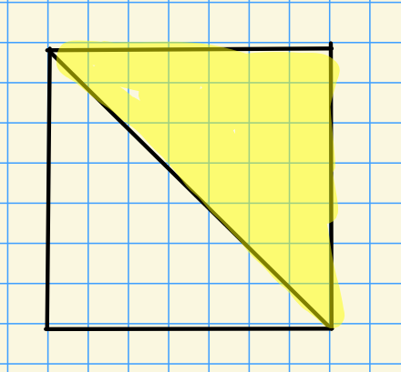

Note that ${\mathcal{O}}_X({\mathbb{P}}^1) = {\mathbb{C}}$ by Liouville’s theorem, and ${\mathcal{O}}_X(U) \cong {\mathbb{C}}[x]$ for $U \subseteq {\mathbb{P}}^1$.

The Grassmannian of $k{\hbox{-}}$planes, given by
$$\begin{align*}
X^Y\mathrel{\vcenter{:}}={\operatorname{Gr}}_k({\mathbb{C}}^n) = \left\{{E \subseteq {\mathbb{C}}^n {~\mathrel{\Big\vert}~}\dim(E) = k}\right\}
.\end{align*}
This has the structure of an algebraic group, either by taking some transitive algebraic group action and lifting structure from the quotient, or taking a Segre embedding. For notation, write \({\mathbb{C}}^i \mathrel{\vcenter{:}}={\operatorname{span}}_{\mathbb{C}}\left\{{e_1,\cdots, e_i}\right\}\) for the span of the first \(i\) standard basis vectors.$$

- $G\mathrel{\vcenter{:}}=\operatorname{GL}_n$ acts transitively by $g.E \mathrel{\vcenter{:}}= gE$, for example by extending a basis from $E$ to ${\mathbb{C}}^n$ and using that $\operatorname{GL}_n$ sends bases to bases, thus sending $E\to E'$ another $k{\hbox{-}}$plane.
- ${\operatorname{Stab}}_G({\mathbb{C}}^2)$ are upper block-triangular matrices:

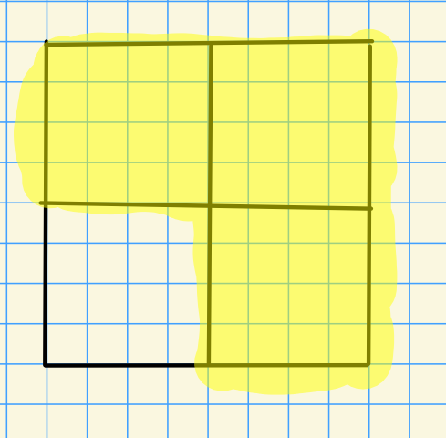

Then define $X^Y \mathrel{\vcenter{:}}= G/P$, noting that here $P$ is a parabolic.

Much study of Schubert varieties reduces to studies of the combinatorics of the Weyl group. Write $W^Y$ for the Young diagrams on an set of $k\times(n-k)$ blocks.

For example, for $n=4, k=2$:

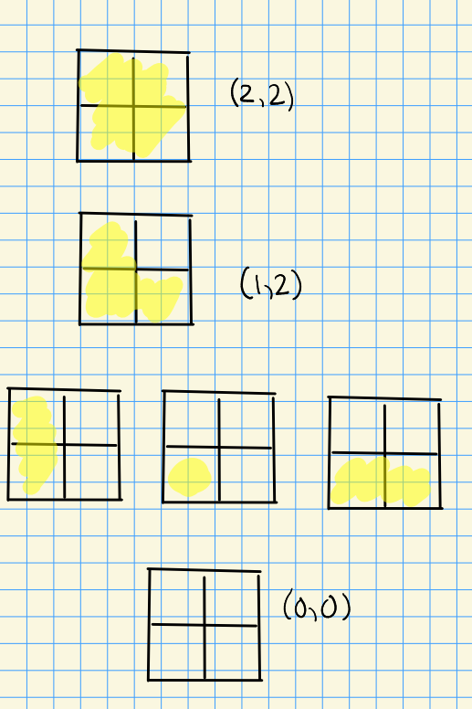

For every $\lambda\in W^Y$, define
$$\begin{align*}
X_\lambda^Y = \left\{{E\in X^Y {~\mathrel{\Big\vert}~}\forall i=1,\cdots, k,\, \dim({\mathbb{C}}^{\sum \lambda_i + i} \cap E )\geq i}\right\}
.\end{align*}$$

For $\lambda = (1, 2)$, we have
$$\begin{align*}
X_\lambda^Y = \left\{{ E \in {\operatorname{Gr}}_2({\mathbb{C}}^4) {~\mathrel{\Big\vert}~}\dim({\mathbb{C}}^2 \cap E) \geq 1, \dim({\mathbb{C}}^4 \cap E) \geq 2 }\right\}
.\end{align*}$$

# 2 Friday, August 20

Recall that we were discussing example 3, Grassmannians, and defined $W^Y$ as Young diagrams in a $k\times (n-k)$ grid. We write
$$\begin{align*}
X^Y_{\lambda} = \left\{{ E \in X^Y = {\operatorname{Gr}}_k({\mathbb{C}}^n) {~\mathrel{\Big\vert}~}\forall 1\leq i \leq k ,\, \dim({\mathbb{C}}^{\lambda_i + i} \cap E) \geq i}\right\}
.\end{align*}$$

$$\begin{align*}
X_{(1, 2)}^Y = \left\{{ E {~\mathrel{\Big\vert}~}\dim({\mathbb{C}}^2 \cap E) \geq 1, \dim({\mathbb{C}}^4 \cap E)\geq 2 }\right\}
.\end{align*}
Note that the second condition is redundant since \(E \subset {\mathbb{C}}^4\) is a 2-plane. Why is this a closed variety? Perhaps the easiest way to see this is using Plucker relations. Using more technology later, this allows follows from looking at \(B{\hbox{-}}\)orbits and Bruhat decompositions.$$

Note that for the rank function ${\operatorname{rank}}: \operatorname{Mat}(m\times n)\to {\mathbb{Z}}$, one can compute the closure
$$\begin{align*}
\mkern 1.5mu\overline{\mkern-1.5mu\operatorname{rank}^{-1}(r)\mkern-1.5mu}\mkern 1.5mu = \operatorname{rank}^{-1}\qty{[0, r)}
.\end{align*}
Also note that \({\operatorname{pr}}_2: {\mathbb{C}}^r\to {\mathbb{C}}^q\), we have \(\ker ({ \left.{{{\operatorname{pr}}_2}} \right|_{{E}} }) = {\mathbb{C}}^2 \cap E\).$$

## 2.1 Example 4: The Full Flag Variety

Define the full flag variety
$$\begin{align*}
X \mathrel{\vcenter{:}}=\left\{{ F^\bullet = \qty{0 \subseteq F^1 \subseteq F^2 \subseteq \cdots \subseteq F^{n-1} \subseteq {\mathbb{C}}^n } {~\mathrel{\Big\vert}~}\dim(F^k) = k}\right\}
.\end{align*}$$

Write ${\mathbb{C}}^\bullet \mathrel{\vcenter{:}}=\qty{0 \subseteq {\mathbb{C}}^1 \subseteq \cdots \subseteq {\mathbb{C}}^n}$ for a distinguished basepoint.

- This is a complete homogeneous space,
- $GL_n\curvearrowright X$ transitively,
- ${\operatorname{Stab}}_G({\mathbb{C}}^\bullet) = B$, the Borel of upper triangular matrices.
- $X \cong G/B$.

For $G$ a linear algebraic group and $B$ a closed subgroup, $G/B$ will generally be a variety.

The Weyl group is generally given by $W = N_G(T)/T$ for $T$ a torus.

Some facts:

- $N_G(T)$ is the set of permutation matrices with arbitrary nonzero entries.
- $W = S_n$ in general, and can be written $W = \left\{{ (w(1), w(2), \cdots, w(n) ) {~\mathrel{\Big\vert}~}w\in S_n }\right\}$.
- $W \hookrightarrow X$ sits in the flag variety via $w\mapsto c {\mathbb{C}}^\bullet$, i.e. acting on the distinguished basepoint.

As an example, we can write permutation matrices in one-line notation, using that $w(e_i) = e_{w(i)}$:

$$\begin{align*}
A = {\left[ {e_4, e_1, e_2, e_3} \right]} \leadsto (4,1,2,3)
.\end{align*}$$

Using that $B/B \cong {\mathbb{C}}^\bullet$ is the basepoint, we have $w{\mathbb{C}}^{\bullet} = wB/B \in BwB/B$.

$$\begin{align*}
BwB / B \cong \left\{{ F^\bullet \in X {~\mathrel{\Big\vert}~}\forall i,j,\,\, \dim({\mathbb{C}}^i \cap F^j) \cap\dim({\mathbb{C}}^i \cap w{\mathbb{C}}^j) }\right\}
.\end{align*}$$

Moreover, $\dim({\mathbb{C}}^i \cap w{\mathbb{C}}^j) = \#\left\{{ k {~\mathrel{\Big\vert}~}k\leq i, w(k) \leq j}\right\}$. Just compute $\left\langle{e_1}\right\rangle \cap w\left\langle{e_1}\right\rangle = \left\langle{e_4}\right\rangle = 0$ for entry $1, 1$, and continue:
$$\begin{align*}
\begin{bmatrix}
0 & 1 & 1 & 1 \\
0 & 1 & 2 & 2 \\
0 & 1 & 2 & 3 \\
1 & 2 & 3 & 4 \\
\end{bmatrix}
.\end{align*}$$

Now check that counting $\left\{{k {~\mathrel{\Big\vert}~}k\leq j,\, w(k) \leq i}\right\}$ yields the same entries in the $i, j$ spot, and thus the same matrix.

## 2.2 Combining Examples 3 and 4

There is a map
$$\begin{align*}
\pi: X &\to X^Y \\
F^\bullet &\mapsto F^k
,\end{align*}
which is equivalently sending a Borel to its corresponding parabolic, and geometrically corresponding to sending \(T{\hbox{-}}\)fixed points to \(T{\hbox{-}}\)fixed points. This induces a map \(W\to W^Y\), and since \(W\cong S_n\), this is sending a Young diagram to a partition.$$

Given $\lambda$ and $1\leq i \leq k$, let $w(i) = \lambda_i + i$ and extend $w$ by filling in the remaining numbers in increasing order, so $w(k+1) < w(k+2) < \cdots < w(n)$. For example, take $(1, 2)\mapsto w = (2, 4 {~\mathrel{\Big\vert}~}1, 3)$, recalling that $(1, 2)$ has this form:

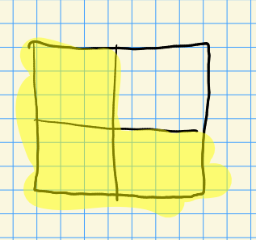

One could also do $w_{\max} = (4, 2 {~\mathrel{\Big\vert}~}3, 1)$.

Note that the Hasse diagrams under a given diagram give the closure relations under $B{\hbox{-}}$orbits: For $\lambda = (1, 2)$, the $B{\hbox{-}}$orbits in $X_\lambda^Y$ are given by the following:

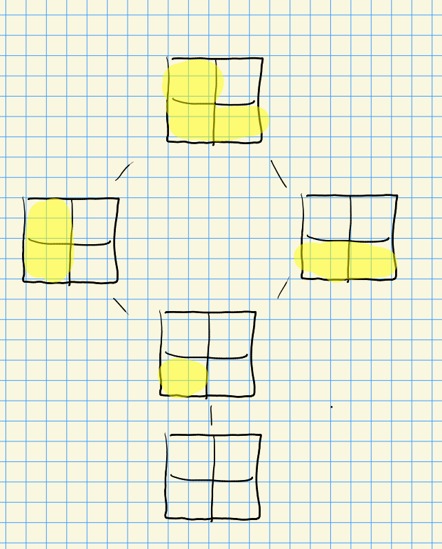

We get $BwP/P = {\mathbb{C}}^{\ell(w^r)}$, and we in fact get a CW structure. Since $H_{\mathrm{sing}}^2(X_\lambda^Y; {\mathbb{Z}}) \neq H_{\mathrm{sing}}^4(X_\lambda^Y; {\mathbb{Z}})$, this doesn’t satisfying Poincare duality, so it can not be a smooth manifold. So what is the singular locus?

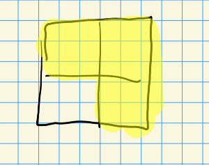

One can determine that the singular locus is the single point $\left\{{{\mathbb{C}}^2}\right\}$ corresponding to the empty diagram:

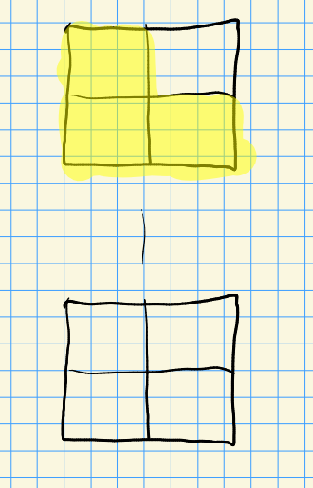

# 3 Lecture 2 (Monday, August 23)

## 3.1 A Lightning Introduction to Groups and Representations

Throughout, *finite type* means finitely generated over the base field.

Which $G$ are important for equivariant cohomology of the flag variety, and equivariant ${\mathsf{K}}{\hbox{-}}$theory. We’ll consider only connected reductive groups, and work over $k \mathrel{\vcenter{:}}={\mathbb{C}}$.

- A group $G \in {\mathsf{Alg}}{\mathsf{Grp}}$ be is a **linear algebraic group** if
  - The coordinate ring ${\mathbb{C}}[G]$ is a reduced (so no nonzero nilpotents) ${\mathbb{C}}{\hbox{-}}$algebra of finite type.
  - $G$ is a group where multiplication $m:G^{\times 2}\to G$ and inverseion $i:G\to G$ are algebraic morphisms
- A **maximal torus** of $G$ is a torus not properly contained in any other torus of the form $({\mathbb{C}}^{\times})^{\times n}$.
- A **Cartan** subgroup is the centralizer of a maximal torus. Note that maximal torii are the same as Cartans in the connected reductive case.
- $G$ is **unipotent** if every representation has a nonzero fixed vector.
- The **unipotent radical** $R_u(G)\leq G$ is a maximal closed connected normal subgroup of $G$.
- $G$ is **reductive** iff $R_u(G) = \left\{{e}\right\}$.

To study ${\mathsf{Rep}}(G)^{{\mathrm{irr}}}$ for $G\in {\mathsf{Alg}}{\mathsf{Grp}}$ linear, we can assume that $G$ is reductive.

Let $V\in {\mathsf{Rep}}(G)^{{\mathrm{irr}}}$, we’ll show that the unipotent radical acts trivially. Then $V$ is the data of

1. $G\to \operatorname{GL}(V)$ for some $V$, a morphism of varieties and algebraic groups
2. There is an action map $G\times V\to V$.

Let $V_0 = \mathrm{Fix} (R_u(G)) \subseteq V$ be the fixed points of $R_u(G)$, by restricting the $G$ action to an $R_u(G)\leq G$ action by a subgroup. We know $V_0 \neq 0$, and we have for every $g\in G, r\in R_u(G), v\in V_0$. We’d like to show $V_0 = V$, which means that $R_u(G)$ acts trivially. So we’ll show $r$ fixes every $gv$:
$$\begin{align*}
r(gv) = g(g^{-1}r g)v \in g R_u(G) v = gv
,\end{align*}
using that \(R_u(G)\) fixes \(v\). So \(V_0\) is \(G{\hbox{-}}\)stable, and since \(V_0\) is irreducible and \(V\) is irreducible, we get equality.$$

So $R_u(G)$ won’t matter for irreducible representations, or in turn for equivariant ${\mathsf{K}}{\hbox{-}}$theory, and we can assume $R_u(G) = \left\{{e}\right\}$ is trivial. If $G$ is not reductive, just replace it with $R/R_u(G)$, which is a reductive linear algebraic group when $G$ is a linear algebraic group since $R_u(G) {~\trianglelefteq~}G$.

Next question: how can we relate compact groups to complex reductive groups?

Let $K \in \operatorname{Lie}{\mathsf{Grp}}$ be compact, and set ${\mathbb{C}}[K]$ to be the ${\mathbb{C}}{\hbox{-}}$span of matrix coefficients of finite dimensional representations of $K$. For $V$ a finite-dimensional representation of $K$ (just a continuous representation of a compact group), define
$$\begin{align*}
\phi: V {}^{ \vee }\otimes_{\mathbb{C}}V &\to {\mathbb{C}}[K] \\
f\otimes v &\mapsto \qty{k \xrightarrow{\phi_{f, v}} f(kv)}
.\end{align*}$$

${\mathbb{C}}[K]$ is a finite type reduced algebra. Such algebras correspond to an affine variety, i.e. it is the ring of functions on some affine variety. Thus ${\mathbb{C}}[K] = {\mathbb{C}}[G]$ for $G\in {\mathsf{Aff}}{\mathsf{Var}}_{/ {{\mathbb{C}}}}$ where $K \subseteq G$.

1. $G$ is a *reductive* algebraic group.
2. Every locally finite continuous representation of $K$ extends uniquely to an algebraic representation of $G$, and every algebraic representation of $G$ restricts to a locally finite representation of $K$.

So despite ${\mathbb{C}}[G]$ being infinite dimensional, every representation is contained in some finite dimensional piece. Note that there is an equivalence of categories between algebraic and compact groups, but there are differences: e.g. there are no irreducible infinite dimensional representations of compact groups.

> Side note, see stuff by David Vogan!

The next result reduces representations to Cartans, which are *almost* tori, and is along the lines of what Langlands was originally thinking about.

There is a bijection
$$\begin{align*}
\widehat{G} \mathrel{\vcenter{:}}=\left\{{\substack{
\text{Irreducible representations} \\
\text{of }G
}}\right\}
&\rightleftharpoons
\left\{{\substack{
\text{Irreducible dominant representations} \\
\text{of a Cartan subgroup } H\leq G
}}\right\}
\end{align*}$$

Moreover,

1. If $G$ is finite, $\left\{{e}\right\} = B \supseteq = \left\{{e}\right\}$, so there is no reduction in this case, noting that the centralizer ends up being the whole group.
2. If $G$ is connected reductive, then $T=H$ and there reduce to dominant characters of a torus.

See David Vogan’s orange book on unitary representations of real reductive groups.

Try proving this directly!

Define
$$\begin{align*}
X(T) \mathrel{\vcenter{:}}=\left\{{T \xrightarrow{f} {\mathbb{C}}^{\times}{~\mathrel{\Big\vert}~}f \text{ is algebraic}}\right\}
,\end{align*}
which is a moduli of irreducible representations of \(G\). Then
\begin{align*}
X(T) \supseteq D_{\mathbb{Z}}\mathrel{\vcenter{:}}=\left\{{\chi \in X {~\mathrel{\Big\vert}~}\chi \text{ is dominant for } B}\right\}
.\end{align*}
Note that this may make more sense after seeing root systems.$$

Given $\lambda \in D_{\mathbb{Z}}$, define a $G{\hbox{-}}$equivariant line bundle on the flag variety as ${\mathcal{L}}(\lambda) \mathrel{\vcenter{:}}=(G\times{\mathbb{C}}_{-\lambda})/B$, where $(-\lambda)t \mathrel{\vcenter{:}}=\lambda(t)^{-1}$. This can be extended to a representation of $B$ by
$$\begin{align*}
B \to B/R_u(B) \cong T \xrightarrow{\lambda} {\mathbb{C}}^{\times}
.\end{align*}
This makes sense thinking of a Borel as upper-triangular matrices, tori as diagonal matrices, and unipotent as strictly upper triangular. So we can extend representations by making them trivial on a normal subgroup?$$

We refer to $\lambda$ as the map and ${\mathbb{C}}_{\lambda}$ as the vector space in the representation $G\to \operatorname{GL}(V)$. Note that $B$ acts on the right of $G\times {\mathbb{C}}_{-\lambda}$ by
$$\begin{align*}
(g, z)b \mathrel{\vcenter{:}}=(gb, b^{-1}z) \mathrel{\vcenter{:}}=(gb, \lambda(b)^{-1}z)
.\end{align*}$$

${\mathcal{L}}(\lambda)$ is an algebraic variety.

# 4 More Broad Overview (Wednesday, August 25)

We’ll assume background in affine varieties, but not necessarily sheaves. Today’s material: see Springer.

Let $X\in {\mathsf{Top}}$, then a **ringed space** is the data of $X$ and for all $U\in {\mathsf{Open}}(X)$ an assignment ${\mathcal{O}}(U) \in {\mathsf{Alg}}_{{\mathbb{C}}}$ a ${\mathbb{C}}{\hbox{-}}$algebra of complex functions satisfying *restriction* and *extension*, also known as a sheaf of ${\mathbb{C}}{\hbox{-}}$valued functions. A **morphism** of ringed spaces $\xi:X\to Y$ is a continuous function such that for all $W\in {\mathsf{Open}}(Y)$, one can form the pullback
$$\begin{align*}
\xi_W^*f: \xi^{-1}(W) \xrightarrow{\xi} W \xrightarrow{f} {\mathbb{C}}
,\end{align*}
and we require that there is a well-defined induced map \(\xi_W^*: {\mathcal{O}}_Y(W) \to {\mathcal{O}}_X(\xi^{-1}(W))\).$$

For $X$ an affine variety, the sheaf ${\mathcal{O}}_X$ of regular functions satisfies this property. Note that ${\mathcal{O}}$ can be an arbitrary sheaf though, not necessarily just regular functions.

A **prevariety** $X$ is a quasicompact space $X$ such that every $x\in X$ admits a neighborhood $U \subseteq X$ such that $(U, \mathop{\mathrm{Res}}({\mathcal{O}}_X, U))$ is isomorphic to an affine variety. A prevariety is a **variety** if it is additionally separated, so $\Delta_X \subseteq X^{\times 2}$ is closed.

Last time we said that ${\mathcal{L}}(\lambda)$ is an *algebraic variety*, so it satisfies the above definitions.

From now on $G$ will be a connected reductive group. $\pi: G\to {\mathcal{L}}(\lambda)$ will always be the map from the group to the flag variety.

Let $X \in {\mathsf{Alg}}{\mathsf{Var}}_{/ {{\mathbb{C}}}}$ and $H\in {\mathsf{Alg}}{\mathsf{Grp}}$ be linear where $H\curvearrowright X$. Then $X/H$ is a quotient in ${\mathsf{Top}}$, by just taking the quotient topology. Let $\rho: X\to X/H$ be the projection, then define the ring of functions as
$$\begin{align*}
{\mathcal{O}}_{X/H}(U) \mathrel{\vcenter{:}}=\left\{{f\in \mathop{\mathrm{Hom}}(U, {\mathbb{C}}) {~\mathrel{\Big\vert}~}\mathop{\mathrm{Res}}(f \circ \rho, \rho^{-1}(U) ) \in {\mathcal{O}}_X(\rho^{-1}(U))}\right\}
.\end{align*}
In this way \({\mathcal{O}}_{X/H}(U)\) can be identified with \(H{\hbox{-}}\)invariant functions \({\mathcal{O}}_X(\rho^{-1}(U))^H\). This makes \(X/H\) a ringed space, which is often (but not necessarily) an algebraic variety.$$

This is not always an algebraic variety, e.g. taking ${\mathbb{C}}^{\times}\curvearrowright{\mathbb{C}}$ by multiplication. This yields two orbits (0 and everything else) and isn’t a variety.

If $\pi: G\to G/H$ has local sections, then $(G\times X)/H \in {\mathsf{Alg}}{\mathsf{Var}}$ using $(g, x)h \mathrel{\vcenter{:}}=(gh, h^{-1}x)$. Note that this is a fiber bundle for the Zariski topology, and doesn’t have local sections (contrasting the analytic topology).

The map $\pi: G\to G/B$ has local sections (but no global sections).

Side note: we have the Bruhat decomposition $G = {\textstyle\coprod}_{w\in W} BwB$ as a partition into double cosets, quotienting by an action of $B\times B$. The theorem is that these are parameterized by the Weyl group.

Let $B = TU$ where $T$ is a torus and $U$ unipotent (so upper triangular, ones along the diagonal) and set $U^-$ to be the *opposite unipotent radical* (e.g. lower triangular, ones along diagonal). Define a map
$$\begin{align*}
\phi: U^i \times B &\to G \\
(\mkern 1.5mu\overline{\mkern-1.5muu\mkern-1.5mu}\mkern 1.5mu, b) &\mapsto \mkern 1.5mu\overline{\mkern-1.5muu\mkern-1.5mu}\mkern 1.5mub^{-1}
.\end{align*}
Then \(\operatorname{im}(\phi) = U^- B\), and \(\phi\) is injective since \(U^- \cap B = \left\{{e}\right\}\). The argument on matrices holds more generally: \(B\) are the upper triangular matrices and \(U^-\) has ones on the diagonal, so these intersect only at the identity. \(\phi\) is an open embedding: one can show that the derivative is surjective:
\begin{align*}
d\phi(1, 1): {\mathfrak{u}}^- \times {\mathfrak{b}}&\to {\mathfrak{y}}\\
(x, y) &\mapsto x-y
.\end{align*}
Rewriting the target as \({\mathfrak{u}}^- \oplus {\mathfrak{h}}\oplus {\mathfrak{u}}^+\) where \({\mathfrak{b}}= {\mathfrak{h}}\oplus {\mathfrak{u}}^+\), one can find preimages of any element.$$

Define a local section: $\sigma: U\to G$ where $U \subseteq G/B$. Use the composite $U^- \times B\to G \to G/B \supseteq U^-$ to view $U^-$ as a subset of the flag variety. An explicit formula for section is the following:
$$\begin{align*}
\sigma(\mkern 1.5mu\overline{\mkern-1.5muu\mkern-1.5mu}\mkern 1.5mu) \mathrel{\vcenter{:}}=(\mkern 1.5mu\overline{\mkern-1.5muu\mkern-1.5mu}\mkern 1.5mu, 1) \in U^- \times B \subseteq G
.\end{align*}
Although this only constructs a section for one open set, translating by elements of \(g\) yields an open cover, and everything is equivariant.$$

Using this, $(G\times X)/B$ is always an algebraic variety, since $G\to G/B$ always has local sections. For other groups, $X$ quasiprojective will also make the quotient algebraic, but the proof is more difficult. However it still involves constructing local sections. It turns out that $G{ \underset{\scriptscriptstyle {B} }{\times} }X\to G/B$ is a locally trivial fiber bundle.

A note on notation: $(G\times X)B$ is sometimes written $G{ \underset{\scriptscriptstyle {B} }{\times} } X$ (as above), but this is *not* a fiber product. In this notation, ${\mathcal{L}}(\lambda) = G{ \underset{\scriptscriptstyle {B} }{\times} } {\mathbb{C}}_{- \lambda}$. Note that this is a line bundle on $G/B$, so we can take sections.

1. There is a correspondence
   $$\begin{align*}
   H^0(G/B; {\mathcal{L}}(\lambda)) \cong \left\{{f:G\to {\mathbb{C}}{~\mathrel{\Big\vert}~}f(g) = bf(gb) }\right\} && G \in {\mathbb{C}}[G]
   .\end{align*}$$

A section $\sigma: G/B \to G{ \underset{\scriptscriptstyle {B} }{\times} } {\mathbb{C}}_{- \lambda}$ gets sent to $\sigma(gB/B) = [g, f(g)]$. Use that the quotient acts like a tensor over $B$, so
$$\begin{align*}
gB/B = gbB/B = [gb, f(gb)] = [g, b f(gb)]
.\end{align*}$$

2. $H^0(G/B; {\mathcal{L}}(\lambda)) = L_{\lambda} {}^{ \vee }$ for $\lambda$ a dominant character in $D_{\mathbb{Z}}$, where $L_\lambda$ is the irreducible finite dimensional representation of $G$ with highest weight $\lambda$. Note that in the finite case, we have $L_\lambda {}^{ \vee }= L_{w_0 \lambda}$, but in the Kac-Moody case one doesn’t have $w_0$.

For $\lambda = 0 \in X(T)$ a character, we get
$$\begin{align*}
\left\{{f:G\to {\mathbb{C}}{~\mathrel{\Big\vert}~}f(g) = f(gb)}\right\} = {\mathbb{C}}[G/B] = {\mathcal{O}}_{G/B}(G/B)={\mathbb{C}}
.\end{align*}$$

Chapter 1 of Kumar, Cartan matrices.

# 5 Starting Kumar (Friday, August 27)

## 5.1 1.1: Definition of Kac-Moody Algebras

Let $A\in \operatorname{Mat}(\ell\times\ell, {\mathbb{C}})$ be rank $r$. A **realization** of $A$ is a triple $({\mathfrak{h}}, \pi, \pi {}^{ \vee })$ where $h\in{\mathsf{{\mathbb{C}}}{\hbox{-}}\mathsf{Mod}}$, $\pi = \left\{{\alpha_1, \cdots, \alpha_\ell}\right\} \subseteq {\mathfrak{h}} {}^{ \vee }$ are column vectors, and $\left\{{ \alpha_1 {}^{ \vee }, \cdots, \alpha_\ell {}^{ \vee }}\right\} \subseteq {\mathfrak{h}}$ are row vectors are indexed sets satisfying

1. $\pi, \pi {}^{ \vee }$ are linearly independent sets.
2. $\alpha_j( \alpha_i {}^{ \vee }) = a_{i, j}$
3. $\ell - r = \dim_{\mathbb{C}}({\mathfrak{h}}) - \ell$

There exists a realization of $A$ that is unique up to isomorphism. Moreover, realizations of $A, B$ are isomorphic iff $B$ is similar to $A$ via a permutation of the index set.

Assume $A$ is of the form
$$\begin{align*}
A =
\begin{bmatrix}
A_1
\\
A_2
\end{bmatrix}
,\end{align*}
where \(A_1\) is \(r\times \ell\) block where \(\operatorname{rank}A_1 = r\) and \(A_2\) is \(l-r\times \ell\) Set
\begin{align*}
C \mathrel{\vcenter{:}}=
\begin{bmatrix}
A_1 & 0
\\
A_2 & I_{\ell-r}
\end{bmatrix}\in \operatorname{Mat}(\ell \times (2\ell - r))
.\end{align*}
For \({\mathfrak{h}}= {\mathbb{C}}^{2\ell - r}\), set \(\alpha_1, \cdots, \alpha_\ell\) to be the first \(\ell\) coordinate functions \(\alpha_1 {}^{ \vee },\cdots\) as the rows of \(C\). This is a realization.$$

Conversely, given a realization $({\mathfrak{h}}, \pi, \pi {}^{ \vee })$, we can produce a matrix: complete $\pi$ to a basis of ${\mathfrak{h}} {}^{ \vee }$. This can done in such a way that $\alpha_j(\alpha_i {}^{ \vee }) = [A_1, B; A_2, D^{-1}]\in \operatorname{Mat}(\ell \times 2\ell -r$. Using column operations, i.e. multiplication on the right, this can be mapped to $[A_1, 0; A_2, I]$.

Let $V\in {\mathsf{{\mathbb{C}}}{\hbox{-}}\mathsf{Mod}}$ and $T^\bullet(V)$ be its (associative) tensor algebra. Set $[ab] = ab-ba$ and take $F(V) \subseteq T(V)$ to be the free Lie algebra generated by $T^1(V)$. We call $F(V)$ the **free Lie algebra generated by $V$**. There is a universal property: for any linear hom $\theta: V\to {\mathfrak{sl}}$, there is a commuting diagram

[figure not shown]

> Link to Diagram

Note that $U(F(V)) = T(V)$.

This can be constructed as
$$\begin{align*}
{\mathfrak{h}}\oplus \left\langle{e_1, \cdots, e_\ell}\right\rangle \bigoplus \left\langle{f_1, \cdots, f_\ell}\right\rangle / \sim
\\ \\
\sim \mathrel{\vcenter{:}}=
\begin{cases}
[e_i f_i] = \delta_{ij} \alpha_i {}^{ \vee }& i, j = 1,\cdots, \ell
\\
[hh'] = 0 & h,h'\in{\mathfrak{h}}
\\
[he_i = \alpha_i(h)e_i &
\\
[hf_i = \alpha_i(h)f_i & i=1,\cdots,\ell, h\in {\mathfrak{h}}
\end{cases}
.\end{align*}
Then set \(\tilde {\mathfrak{g}}(A) \mathrel{\vcenter{:}}= F(V)/\sim\) We’ll find that this only depends on the realization of \(A\).$$

A matrix $A = (\alpha_{ij})$ is a **generalized Cartan matrix (GCM)**:

- $\alpha_{ii} = 2$
- $\alpha_{ij} \leq 0, i\neq j$
- $\alpha_{ij} = 0$ if $\alpha_{ji} =0$

The **Kac-Moody Lie algebra** is defined by ${\mathfrak{g}}\mathrel{\vcenter{:}}={\mathfrak{g}}(A) \mathrel{\vcenter{:}}=\tilde{\mathfrak{g}}(A)/\sim$, where we mod out by the **Serre relations**:
$$\begin{align*}
(\operatorname{ad}e_i)^{1 - a_{ij}}(e_j) &= 0\\
(\operatorname{ad}f_i)^{1 - a_{ij}}(f_j) &= 0
.\end{align*}$$

- There is an injection ${\mathfrak{h}}\hookrightarrow{\mathfrak{g}}$, so we refer to ${\mathfrak{h}}$ as the **Cartan subalgebra**.
- The $e_i, f_i$ are **Chevalley generators**.
- The **nilradicals** are ${\mathfrak{n}}\mathrel{\vcenter{:}}=\left\langle{\left\{{e_1,\cdots,e_\ell}\right\}}\right\rangle$ and ${\mathfrak{n}}^- \mathrel{\vcenter{:}}=\left\langle{ \left\{{f_1, \cdots, f_\ell}\right\}}\right\rangle$.
- ${\mathfrak{b}}\mathrel{\vcenter{:}}={\mathfrak{h}}\oplus {\mathfrak{n}}$ is the **standard Borel**.
- ${\mathfrak{b}}^- \mathrel{\vcenter{:}}={\mathfrak{h}}\oplus {\mathfrak{n}}$
- $\tilde {\mathfrak{n}}, \tilde {\mathfrak{n}}^-, \tilde {\mathfrak{b}}, \tilde {\mathfrak{b}}^-$ can similarly be defined for $\tilde {\mathfrak{g}}$.

A big theorem from algebraic groups: a connected reductive group $G$ corresponds to a root datum$({\mathfrak{g}}, \left\{{\alpha_i}\right\}_{i\leq \ell}, \left\{{ \alpha_i {}^{ \vee }}\right\}_{i\leq \ell} )$ where $\alpha_i, \alpha_i {}^{ \vee }\in {\mathbb{Z}}^n$ such that $a_{ij} \mathrel{\vcenter{:}}={\left\langle {\alpha_i},~{\alpha_i {}^{ \vee }} \right\rangle}$ form a Cartan matrix $A \mathrel{\vcenter{:}}=(a_{ij})$.

Consider pairs of $K, G$ where $G$ is the complexification of $K$:

Here we take the simply connected groups for the last 5, and the last 4 have cyclic centers.

There exist

1. Simple, simply connected, connected groups $G_1, \cdots, G_k$,
2. A finite central subgroup $F \subseteq \prod G_i \times T'$ where $T'$ is a (not necessarily maximal) torus,

such that $G\cong (\prod G_i \times T')/F$. All connected reductive groups arise this way!

Let $G\mathrel{\vcenter{:}}=\operatorname{GL}_n = {\operatorname{SL}}_n \cdot {\mathbb{C}}^{\times}$, and they intersect at roots of unity, so
$$\begin{align*}
\operatorname{GL}_n = ({\operatorname{SL}}_n \times {\mathbb{C}}^{\times}) / \left\langle{\zeta_n I_n, \zeta_n^{-1}}\right\rangle
.\end{align*}
The map (in the reverse direction) is \((g, z)\mapsto gz\), and if \(gz= I\) in \(\operatorname{GL}_n\) then \(g = \zeta_n^k I_n\) and \(z = \zeta_k^{-1}\).$$

Assume $G$ is semisimple, simply connected, and connected. Then

1. The equivariant cohomology is
   $$\begin{align*}
   H^*_T(G/B; {\mathbb{Q}}) \cong S_{\mathbb{Q}}\otimes_{S_{\mathbb{Q}}^W} S_{\mathbb{Q}}
   \end{align*}$$
2. The equivariant ${\mathsf{K}}{\hbox{-}}$theory
   $$\begin{align*}
   K^T(G/B) = A(T) \otimes_{A(T)^W}A(T)
   \end{align*}$$

Note that
$$\begin{align*}
W &= N_G(T)/T \\
S &= S({\mathfrak{h}} {}^{ \vee }), && \pi \subseteq {\mathfrak{h}} {}^{ \vee }\\
A(T) &= {\mathbb{Z}}[X(T)]
.\end{align*}$$

Think about semisimple, simply connected, and connected groups most of the semester.

# 6 Kac-Moody Groups (Monday, August 30)

See exercises in first two sections, 1.1 and 1.2. See also the proof of the Borel-Weil theorem.

## 6.1 1.2: Root Space Decompositions

Starting with a generalized Cartan matrix $A$, we produced a Lie algebra $\tilde{\mathfrak{g}}(A)$ by taking the free Lie algebra and modding out by certain relations. This algebra only depended on the realization of $A$, namely $({\mathfrak{g}}, \pi, \pi {}^{ \vee })$, which we thought of as $({\mathfrak{g}},{\mathfrak{h}} {}^{ \vee }, {\mathfrak{h}})$, yielding ${\mathfrak{g}}(A)$ modulo Serre relations.

Define
$$\begin{align*}
Q &\mathrel{\vcenter{:}}={\mathbb{Z}}\pi \subseteq {\mathfrak{h}} {}^{ \vee }&& \text{the root lattice }\\
Q^+ &\mathrel{\vcenter{:}}={\mathbb{Z}}_{\geq 0} \pi \subseteq {\mathfrak{h}} {}^{ \vee }\\
{\mathfrak{g}}_\alpha &\mathrel{\vcenter{:}}=\left\{{x\in g {~\mathrel{\Big\vert}~}\forall h\in{\mathfrak{h}}, [hx] = \alpha(h) x}\right\} && \text{for }\alpha\in{\mathfrak{h}} {}^{ \vee }
.\end{align*}$$

1. ${\mathfrak{g}}= {\mathfrak{n}}^- \oplus {\mathfrak{h}}\oplus {\mathfrak{n}}$, which are all nonzero.
2. ${\mathfrak{n}}^{\pm \alpha} = \bigoplus_{\alpha\in Q^+\setminus\left\{{{\operatorname{pt}}}\right\}} {\mathfrak{g}}_{\pm \alpha}$.
3. $\dim_{\mathbb{C}}{\mathfrak{g}}_\alpha < \infty$.
4. ${\mathfrak{n}}\mathrel{\vcenter{:}}=\left\langle{e_1,\cdots, e_\ell}\right\rangle$ subject *only* to the Serre relations, i.e. no additional relations are needed for this subalgebra.

First step: prove for $\tilde {\mathfrak{g}}$ and put a tilde on everything appearing in the theorem statement.

Let $\left\{{v_1, \cdots, v_\ell}\right\}$ be a basis for $V$ and fix $\lambda \in {\mathfrak{h}} {}^{ \vee }$. Define an action of generators of $\tilde {\mathfrak{g}}$ on $T(V)$ in the following way:

1. $\alpha:$ Set $f_i(\alpha) \mathrel{\vcenter{:}}= v_i\otimes a$ for $a\in T(V)$
2. $\beta:$ set $h(1) \mathrel{\vcenter{:}}={\left\langle {\lambda},~{h} \right\rangle}1 \mathrel{\vcenter{:}}=\lambda(h)\cdot 1$, and inductively on $s$ set
   $$\begin{align*}
   h(v_j \otimes a) \mathrel{\vcenter{:}}=- {\left\langle {\alpha_j},~{h} \right\rangle} v_j \otimes a + v_j \otimes h(a) && a\in T^{s-1}(V), h\in {\mathfrak{h}}, 1\leq j \leq \ell
   .\end{align*}$$
3. $\gamma:$ Set $e_i(1) \mathrel{\vcenter{:}}= 0$ to kill constants, and inductively on $s$,
   $$\begin{align*}
   e_i(v_j \otimes a) = \delta_{ij}\alpha {}^{ \vee }_{i}(a) + v_j\otimes e_i(a) && a\in T^{s-1}(V), 1\leq j \leq \ell
   .\end{align*}$$

One should show that these define a representation by checking the Serre relations. Consider instead how this works in the ${\mathfrak{g}}= {\mathfrak{sl}}_2$ case:

For ${\mathfrak{sl}}_2$, take the realization $({\mathbb{C}}, \left\{{\alpha}\right\}, \left\{{ \alpha {}^{ \vee }}\right\} )$ corresponds to the matrix $A = (s)$. Here $T(V) = {\mathbb{C}}[x]$, and since there are no Serre relations, $\tilde {\mathfrak{g}}= {\mathfrak{g}}$. We have $e = [0,1; 0,0], f = [0,0; 1,0]$ which generate the positive/negative unipotent parts respectively. Then $h = \left\{{ \operatorname{diag}(h, -h) }\right\}$. Checking the action:

1. $\alpha: { \begin{bmatrix} {0} & {0} \\ {1} & {0} \end{bmatrix} } p = xp$ which raises degree by 1. M
2. $$\begin{align*}
   \beta:
   h(1) = \lambda(h)1
   \implies
   h(xp) = -\alpha(h)xp + x(hp)
   ,\end{align*}
   where \(p\in {\mathbb{C}}[x]_{g-1}\). For example,
   \begin{align*}
   h(x) &= -\alpha(x) + x \lambda(h) = (\lambda - \alpha)(h)x \\
   h(x^2) &= (\lambda - 2\alpha)(h)x^2
   ,\end{align*}
   so this acts diagonally and preserves degree.$$
3. Check
   $$\begin{align*}
   {
   \begin{bmatrix}
   {0} & {1}
   \\
   {0} & {0}
   \end{bmatrix}
   } \cdot (1) &= 0 \\
   {
   \begin{bmatrix}
   {0} & {1}
   \\
   {0} & {0}
   \end{bmatrix}
   } \cdot (xp) &= p + x {
   \begin{bmatrix}
   {0} & {1}
   \\
   {0} & {0}
   \end{bmatrix}
   } p
   .\end{align*}$$

Check that $ex = 1+0$ and $ex^2 = x+x = 2x$, so $e$ acts by differentiation.

Note that ${\mathfrak{h}}$ forms a subalgebra since it’s a nondegenerate map. This follows from the fact that we get a representation $\rho_{\lambda}$ of $\tilde{\mathfrak{g}}$ on $T(V)$, which for each $h$ acts nontrivially on some $T(V)$. So use $\rho_{\lambda}$ to deduce the theorem for $\tilde{\mathfrak{g}}$:
$$\begin{align*}
\left\{{ [ x, y] {~\mathrel{\Big\vert}~}x,y\in {\mathfrak{h}}= \left\langle{\left\{{e_i, f_i}\right\}_{i=1}^\ell}\right\rangle }\right\} \subseteq
\tilde {\mathfrak{n}}^- + {\mathfrak{h}}+ \tilde{\mathfrak{n}}
= {\mathfrak{g}}
,\end{align*}
we’ll show this sum is direct.$$

Let $u = n^- + h + n^+ = 0$, then in $T(V)$ we have $u(1) = n^-(1) + {\left\langle {\lambda},~{h} \right\rangle}1$, which forces ${\left\langle {\lambda},~{h} \right\rangle} = 0$ for all $\lambda\in{\mathfrak{h}} {}^{ \vee }$ and thus $h = 0$. Use the restriction $\tilde{\mathfrak{g}}\to \tilde{\mathfrak{n}}$ to get a map $U(\tilde{\mathfrak{n}}^-)\to T(V)$ out of the enveloping algebra, using that $T(V)$ is an associative algebra. Using $f_i \mapsto v_i$, this is surjective and in fact an isomorphism. Sending ${\mathfrak{n}}^- \mapsto {\mathfrak{n}}^-(1)$ yields $\tilde{\mathfrak{n}}^- \subseteq U(\tilde{\mathfrak{n}}^-) = T(V)$. This yields $n^- = 0$, making the sum direct.

We can write $\tilde{\mathfrak{n}}^- = F\left\langle{f_1,\cdots, f_\ell}\right\rangle$
and $\tilde{\mathfrak{n}}= F\left\langle{e_1,\cdots, e_\ell}\right\rangle$ and by the PBW theorem, $\dim \tilde{\mathfrak{g}}_\alpha < \infty$. This uses that the weight spaces for $\tilde{\mathfrak{n}}^-$ are contained in $U(\tilde{\mathfrak{n}}^-)$. Note that there is a *Cartan involution*
$$\begin{align*}
\tilde\omega: \tilde{\mathfrak{g}}&{\circlearrowleft}\\
e_i &\mapsto -f_i \\
f_i &\mapsto -e_i \\
h &\mapsto -h
.\end{align*}$$

Now to prove the theorem for ${\mathfrak{g}}$ itself, write $\tilde {\mathfrak{r}}\mathrel{\vcenter{:}}=\ker( \tilde{\mathfrak{g}}\xrightarrow{\gamma} {\mathfrak{g}}_\alpha) {~\trianglelefteq~}\tilde{\mathfrak{g}}$. This is an ideal, and thus ${\mathfrak{h}}{\hbox{-}}$stable. We can thus write
$$\begin{align*}
\tilde{\mathfrak{r}}=
\qty{
\bigoplus_{\alpha\in Q^+ \setminus\left\{{{\operatorname{pt}}}\right\}} {\mathfrak{r}}_{-\alpha}
}
\oplus
\tilde{\mathfrak{r}}_0
\oplus
\qty{
\bigoplus_{\alpha\in Q^+ \setminus\left\{{{\operatorname{pt}}}\right\}} {\mathfrak{r}}_{\alpha}
}
\end{align*}
where \(\tilde{\mathfrak{r}}_{\beta} \mathrel{\vcenter{:}}=\tilde{\mathfrak{r}}\cap\tilde{\mathfrak{g}}_{\beta}\) and \(\tilde {\mathfrak{r}}_0 = \tilde{\mathfrak{r}}\cap{\mathfrak{h}}\). We have ideals \(\tilde{\mathfrak{r}}^{\pm} {~\trianglelefteq~}\tilde{\mathfrak{n}}^{\pm}\), which are respectively generated by
\begin{align*}
\left\{{e_{i, j} = (\operatorname{ad}e_i)^{1 - a_{i, j}} (e_{j}) {~\mathrel{\Big\vert}~}i\neq j }\right\}
&&
\left\{{f_{i, j} = (\operatorname{ad}f_i)^{1 - a_{i, j}} (f_{j}) {~\mathrel{\Big\vert}~}i\neq j }\right\}
,\end{align*}
where \(\operatorname{ad}f_k (e_{i, j}) = 0\) for all \(k\) and \(i\neq j\). Skipping a few things that are spelled out in the book, e.g. that \(\tilde {\mathfrak{r}}_0 = 0\), we conclude that \(\tilde{\mathfrak{r}}= \tilde{\mathfrak{r}}^+ \oplus \tilde{\mathfrak{r}}^-\), both of which are ideals in \(\tilde{\mathfrak{g}}\). Since \(\tilde{\mathfrak{r}}_0 = 0\), we get \({\mathfrak{h}}\subseteq {\mathfrak{g}}\), and using that \(\gamma\) is surjective we have an isomorphism of \({\mathbb{C}}{\hbox{-}}\)modules
\begin{align*}
{\mathfrak{g}}= \tilde{\mathfrak{g}}/\tilde{\mathfrak{r}}= \tilde{\mathfrak{n}}^-/ \tilde{\mathfrak{r}}^- \oplus {\mathfrak{h}}\oplus \tilde{\mathfrak{n}}/ \tilde{\mathfrak{r}}^+
.\end{align*}$$

Write $\Delta \mathrel{\vcenter{:}}=\left\{{\alpha\in Q\setminus\left\{{{\operatorname{pt}}}\right\} {~\mathrel{\Big\vert}~}{\mathfrak{g}}_\alpha \neq 0}\right\}$ the *set of roots* and ${\mathfrak{g}}_{\alpha}$ the *root space*, then set \begin{align*} \Delta^+ &\mathrel{\vcenter{:}}=\Delta \cap Q^+ \\ \Delta^- &\mathrel{\vcenter{:}}=\Delta \cap(-Q^+) \\ \Delta &\mathrel{\vcenter{:}}=\Delta^+ \cup\Delta^- .\end{align*} Also for $Y \subseteq \left\{{1,\cdots,\ell}\right\}$ write \begin{align*} \Delta_Y &\mathrel{\vcenter{:}}=\Delta \cap\qty{\bigoplus_{i\in Y} {\mathbb{Z}}\alpha_i } \\ {\mathfrak{g}}_Y &\mathrel{\vcenter{:}}={\mathfrak{h}}\oplus \qty{ \bigoplus_{\alpha\in \Delta_Y} {\mathfrak{g}}_\alpha } .\end{align*} We say $Y$ is *finite type* if ${\mathfrak{g}}_Y$ is finite dimensional, and given $A$ we can associate some matrix $(a_{i, j})_{i, j\in Y}$.

See Ch. 13 for how this generalizes the semisimple case.

# 7 Weyl Groups, 1.3 (Wednesday, September 01)

We’ll spend a few days discussing Weyl groups, since they’re important in the study of Schubert varieties. For other references, see

- Björner and Brenti: *Combinatorics of Coxeter Groups*

## 7.1 Root Systems

Recall that given a generalized Cartan matrix $A$, there is an associated realization $({\mathfrak{h}}, \pi \subseteq {\mathfrak{h}} {}^{ \vee }, \pi {}^{ \vee })$.

For $1\leq i \leq \ell$, define a **reflection** $s_i\in \mathop{\mathrm{Aut}}({\mathfrak{h}} {}^{ \vee })$ as
$$\begin{align*}
s_i(\chi) \mathrel{\vcenter{:}}=\chi - {\left\langle {\chi},~{\alpha_i {}^{ \vee }} \right\rangle}\alpha_i && \forall \chi \in {\mathfrak{h}} {}^{ \vee }
.\end{align*}$$

One can check that this fixes a hyperplane, and $s_i^2 = \operatorname{id}$.

A subset $\Phi$ of Euclidean space $(V, {\left\langle {{-}},~{{-}} \right\rangle})$ is a **crystallographic root system** in $V$ iff

1. $\Phi$ is finite, ${\operatorname{span}}_{\mathbb{R}}\Phi = V$, and $0\not\in\Phi$.
2. If $\alpha \in \Phi$, then ${\mathbb{R}}\alpha \cap\Phi = \pm \alpha$.
3. If $\alpha \in \Phi$, then $s_\alpha$ leaves $\Phi$ invariant
4. If $\alpha, \beta\in \Phi$, then ${(\beta, \alpha) \over 2(\alpha, \alpha)} \in {\mathbb{Z}}$.

Note that for a Kac Moody Lie algebra, $\Phi$ is often infinite, so condition 1 can fail. Condition 2 can fail if $\alpha$ is imaginary, in which case $n\alpha \in \Phi$ for some $n\in {\mathbb{Z}}$.

Let $W \subseteq \mathop{\mathrm{Aut}}({\mathfrak{h}} {}^{ \vee })$ be the subgroup generated by $\left\{{s_i {~\mathrel{\Big\vert}~}1\leq i\leq \ell}\right\}$, then $W$ is said to be the **Weyl group** of ${\mathfrak{g}}$.

Let ${\mathcal{W}}$ be the group generated by a fixed set $S$ of elements of order 2 in $W$. Then for $w\in {\mathcal{W}}$, the **length** $\ell(w)$ is the smallest number $\ell$ such that $w = \prod_{i=1}^\ell s_i$.

Note that $\ell(1) = 0$, and for $Y \subseteq S$, we set ${\mathcal{W}}_Y$ to be the subgroup generated by $\left\{{s{~\mathrel{\Big\vert}~}s\in Y}\right\}$. We’ll prove that any Weyl group is a Coxeter group, but for now $W$ is a Weyl group and ${\mathcal{W}}$ is a Coxeter group.

Let $({\mathcal{W}}, S)$ be as above, then TFAE:

1. The Coxeter condition: ${\mathcal{W}}$ is a quotient of the free group $\widehat{{\mathcal{W}}}$ generated by $S$, modulo the following relations:
- $s^2= 1$ for all $s\in S$.
- $(st)^{m_{s, t}} = 1$ for all $s\neq t$ in $S$ and for some integers $m_{t, s} = m_{s, t} \geq 2$ (or possibly $\infty$).
2. The root system condition: There exists a representation $V$ of ${\mathcal{W}}$ over ${\mathbb{R}}$ together with a subset $\Delta \subseteq V\setminus\left\{{{\operatorname{pt}}}\right\}$ such that
- Symmetric: $\Delta = -\Delta$
- ${\mathcal{W}}{\hbox{-}}$invariance/stability: there exists a subset $\pi \mathrel{\vcenter{:}}=\left\{{\alpha_s}\right\}_{s\in S} \subseteq \Delta$ such that for any $\alpha \in \Delta$ exactly one of $\alpha$ or $-\alpha$ belongs to the set of positive linear combinations of “simple roots” $\sum_{s\in S} {\mathbb{R}}_{>0} \alpha_s$. If $\alpha$ is in this subset, we’ll say $\alpha$ is **positive**, and if $-\alpha$ is in it, we’ll say $\alpha$ is **negative**.
- For every $s\in S$, if $\alpha \neq \alpha_s$ and $\alpha > 0$ is positive, then $s\alpha_s <0$ is negative and $s\alpha > 0$.[^1]
- For $s, t\in S$ and $w\in {\mathcal{W}}$, then $w \alpha_s = \alpha_t$ implies that $wsw^{-1}= t$, so the group action is captured in a conjugation action.
3. The *strong exchange* condition: For $s\in S$ and $v, w\in {\mathcal{W}}$ with $\ell(vsv^{-1}w) \leq \ell(w)$, for any expression $w = \prod_{i=1}^n s_i$ with $s_i \in S$, we have $vsv^{-1}w = \prod_{i\neq j}^n s_i$ for some $j$.
4. The *exchange condition*: For $s\in S, w\in {\mathcal{W}}$ with $\ell(sw) \leq \ell(w)$, then for any reduced expression $w = \prod_{i=1}^n s_i$, we have $sw = \prod_{i\neq j}^n s_i$ for some $j$.

These conditions show up in a lot of proofs!

If $S$ is finite (which it will be for us), we can take $V$ to be finite dimensional. Writing $S \mathrel{\vcenter{:}}=\left\{{s_1, \cdots, s_\ell}\right\}$ and set $m_{ij} \mathrel{\vcenter{:}}={\operatorname{Ord}}(s_i s_j)$. If every $m_{ij}$ is one of $\left\{{2,3,4,6,\infty}\right\}$, call the Coxeter group **crystallographic**.

An open problem is that all Coxeter groups *should* come from geometry, e.g. from projective varieties (?), but it’s not clear what these varieties should be. The crystallographic ones will precisely come from Kac-Moody Lie algebras. This is closely related to problems concerning KL polynomials: take an Ind variety, stratify it, and take intersection cohomology.

Every *finite* irreducible Coxeter group (with exceptions $H_3, H_4, I_2(m)$) occur as Weyl groups of crystallographic root systems.

Let $V$ be the ${\mathbb{R}}{\hbox{-}}$module with basis $\left\{{\alpha_s {~\mathrel{\Big\vert}~}s\in S}\right\}$. For any $s\in S$, define an inner product by extending the following ${\mathbb{R}}{\hbox{-}}$bilinearly:
$$\begin{align*}
(\alpha_s, \alpha_s) &= 1 \\
(\alpha_{s_1}, \alpha_{s_2}) &= \cos({\pi \over m_{s_1s_2}}) && s_1\neq s_2
.\end{align*}$$

For $s, v\in V$, define
$$\begin{align*}
s(v) \mathrel{\vcenter{:}}= v - 2(v, \alpha_s) \alpha_s
.\end{align*}
A quick computation shows
\begin{align*}
s( \alpha_s) = \alpha_s - 2 (\alpha_s, \alpha_s) \alpha_s = - \alpha_s
.\end{align*}
One can check that the formula is \({\mathbb{R}}{\hbox{-}}\)linear, and using this we have
\begin{align*}
s^2(v)
&= s(v - 2(v, \alpha_s) \alpha_s) \\
&= s(v) - 2(v, \alpha_s) s(\alpha_s) \\
&= (v -2(v, \alpha_s) \alpha_s) - 2(v, \alpha_s)s( \alpha_s) \\
&= (v -2(v, \alpha_s) \alpha_s) - 2(v, \alpha_s)(- \alpha_s) \\
&= v
,\end{align*}
so \(s^2 = \operatorname{id}\). By assumption, we have \((s_1 s_2)^{m_{s_1 s_2}}(v) = v\). Using that this formula factors through the relations, we can extend this to an action \({\mathcal{W}}\curvearrowright V\). Then
\begin{align*}
(s(v), s(v'))
&= (v - 2(v, \alpha_s) \alpha_2, v' - 2(v', \alpha_s) \alpha_s) \\
&= (v, v') - 2(v', \alpha_s)(v, \alpha_s) - 2(v, \alpha_s)(\alpha_s, v') + 4(v, \alpha_s)(v', \alpha_s)(\alpha_s, \alpha_s) \\
&= (v, v') - 4(v', \alpha_s)(v, \alpha_s) + 4(v, \alpha_s)(v', \alpha_s)\\
&= (v, v')
,\end{align*}
where we’ve used that \(({-}, {-})\) is symmetric. Thus \((wv, wv') = (v, v')\).$$

Let $\Delta\mathrel{\vcenter{:}}=\displaystyle\bigcup_{s\in S} \mathcal{W} ( \alpha_s)$, we’ll work with this more next time.

# 8 Wednesday, September 08

Today: finish chapter one.

For $v, w\in W$ we set $v\leq w \iff$ there exists ${ {t}_1, {t}_2, \cdots, {t}_{p}} \in T$ such that

- $v = t_p\cdots t_1 w$
- $\ell(t_{j} \cdots t_1 w) \leq \ell(t_{j-1} \cdots t_1 w)$.

For $Y \subseteq S$ we set
$$\begin{align*}
W'_Y \mathrel{\vcenter{:}}=\left\{{\ell(wv) \geq \ell(w) \forall v\in W_Y}\right\}
.\end{align*}$$

Consider $W = S_3$ with $S\mathrel{\vcenter{:}}=\left\{{s_1, s_2}\right\} = \left\{{1, 2}\right\}$. The Hasse diagram is the following:

[figure not shown]

> Link to Diagram

We have

- $\emptyset \subseteq \left\{{1}\right\} \subseteq {1, 2}$
- $$\begin{align*}
  G/B = \left\{{0 \subseteq F^1 \subseteq F^2 \subseteq {\mathbb{C}}^3}\right\} \to \left\{{0 \subseteq F^2 \subseteq {\mathbb{C}}^3}\right\} \mathrel{\vcenter{:}}={\operatorname{Gr}}_2({\mathbb{C}}^3) \to \left\{{0 \subseteq {\mathbb{C}}^3}\right\} = G/G
  .\end{align*}
  Note that Kumar writes
  \begin{align*}
  X^{\emptyset} &\mathrel{\vcenter{:}}= G/B \\
  X^{\left\{{1}\right\}} &= {\operatorname{Gr}}_2({\mathbb{C}}^3)\\
  X^{\left\{{1,2}\right\}} &= G/G
  .\end{align*}$$
- For $Y\mathrel{\vcenter{:}}=\left\{{1}\right\}$, we just have to check how lengths change upon swapping the first two positions. Thus $W_Y = \left\{{e, s_1}\right\}$ since $(2,3,1)$ is minimal length. Similarly $(1,3,2)$ and $(1,2,3)$ are minimal length.

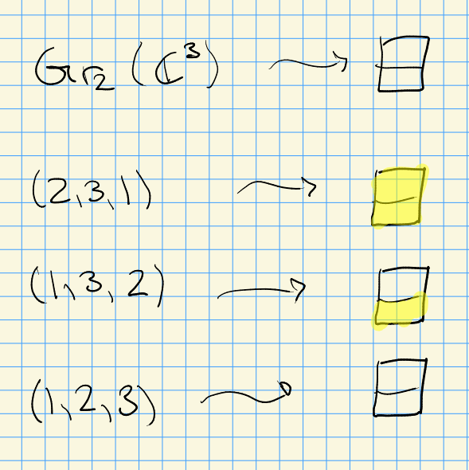

- For $Y = \left\{{1, 2}\right\}$, we get $W_Y = W$ with a minimal element $(1,2,3)$.

Fix a reduced expression $w = \prod_{i\leq n} s_i$. Then $v\leq w$ iff there exist indices $1\leq j_1 < j_2 < \cdots < j_p \leq n$ such that $v = \prod_{i\neq j_k} s_i$.

For $m_{12} = 3$, if $(s_1 s_2)^{m_{12} = 3} = e$, so $s_1 s_2 s_1 = s_2 s_1 s_2$, which is a braid relation that corresponds to $(3,2,1)$. Let $w_0$ be the maximal element (which generally only works when the Coxeter group is finite), so here $w_0 = s_1 s_2 s_1$. We can cross out various reflections to get closure relations:

[figure not shown]

> Link to Diagram

Here for $Y = \left\{{1}\right\} = \left\{{s_1}\right\}$, we get minimal length elements $e, s_2, s_1 s_2$.

In general, we start with a GCM $A$, take a realization $({\mathfrak{h}}, \pi, \pi {}^{ \vee })$, get Kac-Moody Lie algebra ${\mathfrak{g}}$, and extract a group $W$ which we now know is a Coxeter group. Write $\left\{{{ {\alpha}_1, {\alpha}_2, \cdots, {\alpha}_{\ell}}}\right\} \subseteq {\mathfrak{h}} {}^{ \vee }$ and $S = \left\{{s_1, \cdots, s_\ell}\right\}$, then for any $1\leq i\leq \ell$ set
$$\begin{align*}
s_i(\chi) \mathrel{\vcenter{:}}=\chi - {\left\langle {\chi},~{\alpha_i {}^{ \vee }} \right\rangle}\alpha_i && \forall \chi\in{\mathfrak{h}} {}^{ \vee }
.\end{align*}
Fix a real form \({\mathfrak{h}}_{\mathbb{R}}\) of \({\mathfrak{h}}\) satisfying$$

- $\pi {}^{ \vee }\subseteq {\mathfrak{h}}_{\mathbb{R}}$,
- $\alpha_i({\mathfrak{h}}_{\mathbb{R}}) \subseteq {\mathbb{R}}$ for all $1\leq i \leq \ell$.

Define the **dominant chamber** $D_{\mathbb{R}}\subseteq {\mathfrak{h}}_{\mathbb{R}} {}^{ \vee }\mathrel{\vcenter{:}}=\mathop{\mathrm{Hom}}_{{\mathsf{{\mathbb{R}}}{\hbox{-}}\mathsf{Mod}}}({\mathfrak{h}}_{\mathbb{R}}, {\mathbb{R}})$ as
$$\begin{align*}
D_{\mathbb{R}}\mathrel{\vcenter{:}}=\left\{{ \lambda\in {\mathfrak{h}}_{\mathbb{R}} {}^{ \vee }{~\mathrel{\Big\vert}~}\lambda(\alpha_i) \geq 0 \, \forall i}\right\}
.\end{align*}$$

Define the **Tits cone** as
$$\begin{align*}
C \mathrel{\vcenter{:}}=\displaystyle\bigcup_{w\in W} wD_{\mathbb{R}}
.\end{align*}$$

Consider the reductive group ${\mathsf{Sp}}_4({\mathbb{C}})$, which is semisimple, simply connected, and connected. One way to realize this group is as
$$\begin{align*}
{\mathsf{Sp}}_4({\mathbb{C}}) \mathrel{\vcenter{:}}=\left\{{ g\in \operatorname{GL}_4({\mathbb{C}}) {~\mathrel{\Big\vert}~}\Theta(g) = g}\right\}
\end{align*}
for \(\Theta\) some involution of \(\operatorname{GL}_4({\mathbb{C}})\). Noting that we always have associated root datum \((n, \left\{{ \alpha_i}\right\}_{i=1}^\ell ,\left\{{\alpha_i {}^{ \vee }}\right\}_{i=1}^\ell )\), here we have
\begin{align*}
{\mathsf{Sp}}_4({\mathbb{C}}) = (2, \left\{{ (1,-1), (0, 2)}\right\}, \left\{{(1, -1), (0, 1)}\right\} )
.\end{align*}
This yields a GCM
\begin{align*}
A = {
\begin{bmatrix}
{2} & {-2}
\\
{-1} & {2}
\end{bmatrix}
}
,\end{align*}
which comes from computing \((A)_{ij} \mathrel{\vcenter{:}}=\alpha_i(\alpha_j {}^{ \vee })\). Here
\begin{align*}
G/Z(G) = (2, \left\{{ (1, 0), (0, 1) }\right\} , \left\{{ (2, -2), (-1, 2) }\right\} )
.\end{align*}
Note that these two root data are distinct over \({\mathbb{Z}}\). We can consider the real form \({\mathfrak{h}}_{\mathbb{R}} {}^{ \vee }\):$$

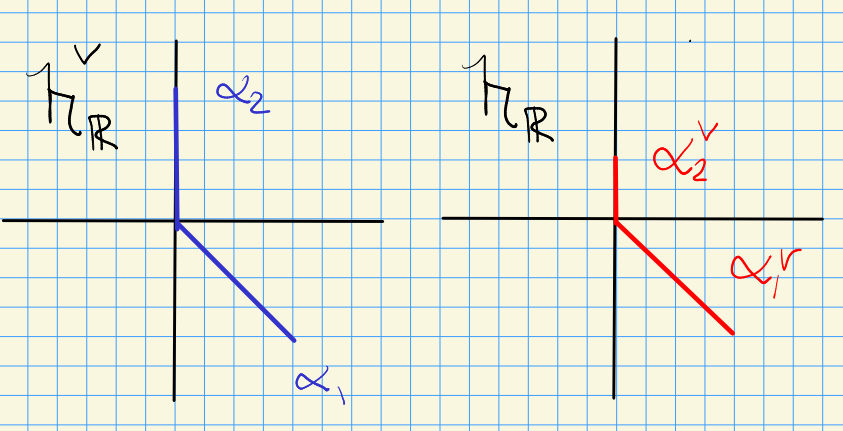

We have

- $\chi \in {\mathfrak{h}}_{\mathbb{R}} {}^{ \vee }= \left\{{(x, y)}\right\}$,
- $s_1(x, y) = (x, y) - {\left\langle {(x, y)},~{(1, -1)} \right\rangle}(1, -1) = (y, x)$
- $s_2(x, y) = (x, y) - {\left\langle {(x, y)},~{(0, 1)} \right\rangle}(0, 2) = (x, -y)$

We can look at the $W{\hbox{-}}$orbits of these, and it turns out to recover all of the roots:

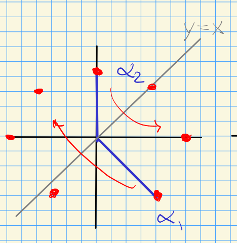

$W \subseteq \mathop{\mathrm{Aut}}({\mathfrak{h}}_{\mathbb{R}} {}^{ \vee })$ is the subgroup given by $\left\{{s_1, s_2}\right\}$, and there are maps
$$\begin{align*}
s_1 s_2: (x, y) &\mapsto (-y, x)\\
s_2 s_1 s_2: (x, y) &\mapsto (y, -x)\\
s_1s_2 s_1 s_2: (x, y) &\mapsto (-x, -y)\\
s_2 s_1s_2 s_1 s_2: (x, y) &\mapsto (-x, y)\\
\vdots &\quad \vdots \\
(s_1s_2)^4: (x, y) &\mapsto (x, y) \implies m_{12} = 4
.\end{align*}
Here we’ve used that \((s_1 s_2)^2 = (s_2 s_1)^2\). We can then find the dominant chamber:$$

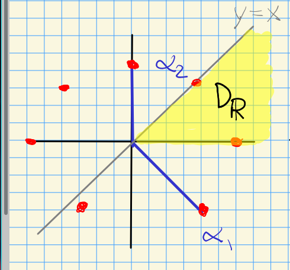

For $\lambda \in D_{\mathbb{R}}$, we set $W_\lambda \mathrel{\vcenter{:}}=\left\{{w\in W {~\mathrel{\Big\vert}~}w(\lambda) = \lambda}\right\}$. This is generated by the simple reflections it contains. Setting $Y = Y(\lambda) = \left\{{s_i \in S {~\mathrel{\Big\vert}~}\lambda( \alpha_i {}^{ \vee }) = 0}\right\}$, we actually get $W_\lambda = W_Y$.

Recall what regular weights are!

# 9 Category ${\mathcal{O}}$ (Friday, September 10)

Counterexamples: Kac Moodys that aren’t usual Lie algebras: affine Kac Moodys.

Our setup: $A \leadsto ({\mathfrak{h}},\pi,\pi {}^{ \vee })$. Fix $\lambda \in {\mathfrak{h}} {}^{ \vee }$ and $c\in {\mathbb{C}}_{ \lambda} \ni z$ a representation of ${\mathfrak{h}}$ by $x.\cdot \mathrel{\vcenter{:}}=\lambda(x)z$. Recall that we have a triangular decomposition ${\mathfrak{g}}= {\mathfrak{n}}^- \oplus {\mathfrak{h}}\oplus {\mathfrak{n}}$ with ${\mathfrak{h}}\oplus {\mathfrak{n}}\leq {\mathfrak{b}}$ a subalgebra of the Borel. Since ${\mathfrak{n}}{~\trianglelefteq~}{\mathfrak{b}}$ is an ideal, we can quotient to extend the representation
$$\begin{align*}
{\mathfrak{b}}\to {\mathfrak{b}}/{\mathfrak{n}}\cong {\mathfrak{h}}\xrightarrow{\lambda} {\mathbb{C}}_{\lambda}
.\end{align*}
This extends from \({\mathfrak{h}}\) to \({\mathfrak{b}}\) by making it zero on \({\mathfrak{n}}\), and generally one can do this with nilradicals.$$

$$\begin{align*}
M(\lambda) \mathrel{\vcenter{:}}= U({\mathfrak{g}}) \otimes_{U({\mathfrak{b}})} {\mathbb{C}}_{\lambda} \in {\mathsf{{\mathfrak{g}}}{\hbox{-}}\mathsf{Mod}}
,\end{align*}
where \({\mathfrak{b}}\curvearrowright{\mathbb{C}}_{\lambda}\) extends to the universal enveloping algebra.$$

The PBW theorem implies that every $M(\lambda)\cong U({\mathfrak{n}}^-) \otimes_{\mathbb{C}}{\mathbb{C}}_{\lambda}$ as vector spaces, which is in fact an isomorphism in ${\mathsf{{\mathfrak{b}}^-}{\hbox{-}}\mathsf{Mod}}$. This means $M( \lambda)$ is a weight module for ${\mathfrak{h}}$, i.e. there is a decomposition $M(\lambda) = \bigoplus_{\mu \in {\mathfrak{h}} {}^{ \vee }}M(\lambda)_{ \mu}$ where
$$\begin{align*}
M(\lambda)_{\mu} \mathrel{\vcenter{:}}=\left\{{v\in M( \lambda) {~\mathrel{\Big\vert}~}h\cdot v = \mu(h) v,\,\quad h\in {\mathfrak{h}}}\right\}
.\end{align*}$$

Any nonzero quotient $L$ of $M(\lambda)$ in ${\mathsf{{\mathfrak{g}}}{\hbox{-}}\mathsf{Mod}}$ is a **highest weight module** with highest weight $\lambda$.

There is a full subcategory ${\mathcal{O}}\leq {\mathsf{{\mathfrak{g}}}{\hbox{-}}\mathsf{Mod}}$ where every $M\in {\operatorname{Ob}}({\mathcal{O}})$ satisfies the following:

- (Finite multiplicities) $M$ is a weight module with finite-dimensional weight spaces.
- There exist finitely many weights ${ {\lambda}_1, {\lambda}_2, \cdots, {\lambda}_{k}}\in {\mathfrak{h}} {}^{ \vee }$ (depending on $M$) such that $P(M) \subseteq \displaystyle\bigcup_{1\leq j\leq k} {\mathfrak{h}} {}^{ \vee }_{\leq \lambda_j}$:

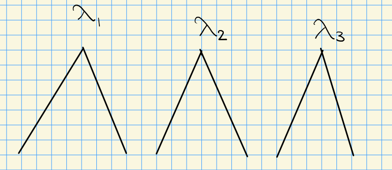

Any $M(\lambda)$ has a unique proper maximal ${\mathfrak{g}}{\hbox{-}}$submodule $M'(\lambda)$. In particular, $\lambda\not \in M'(\lambda)$, and there is a unique irreducible quotient $L(\lambda) \mathrel{\vcenter{:}}= M( \lambda)/M'( \lambda)$.

> The proof is easy: use that $\lambda$ generated $M(\lambda)$ as a ${\mathfrak{g}}{\hbox{-}}$module.

For any irreducible $L \in {\operatorname{Ob}}({\mathcal{O}})$, there exists a unique $\lambda \in {\mathfrak{h}} {}^{ \vee }$ such that $L \cong L(\lambda)$.

Define the **dominant integral weights**
$$\begin{align*}
D \mathrel{\vcenter{:}}=\left\{{ \lambda\in {\mathfrak{h}} {}^{ \vee }{~\mathrel{\Big\vert}~}\forall \alpha_i {}^{ \vee }\in \pi {}^{ \vee },\,\, {\left\langle { \lambda},~{\alpha_i {}^{ \vee }} \right\rangle} \in {\mathbb{Z}}_{> 0} }\right\}
.\end{align*}$$

For $\lambda \in D$, define $M_1(\lambda) \subseteq M( \lambda)$ as the submodule generated by $\left\{{ f_i^{ \lambda(\alpha_i {}^{ \vee }) + 1 } \otimes 1}\right\}_{i=1}^\ell$, and define
$$\begin{align*}
L^{\max}( \lambda) \mathrel{\vcenter{:}}={M(\lambda) \over M_1( \lambda)}
,\end{align*}
the operators that act locally nilpotently (so there is an exponent depending on the vector)$$

Let $A = {\left[ {2} \right]}$ be a $1\times 1$ GCM, which yields $({\mathbb{C}}, \left\{{ 2}\right\}, \left\{{ 1}\right\})\leadsto {\mathfrak{sl}}_2({\mathbb{C}})$. Given $\lambda\in {\mathbb{C}},$ we have
$$\begin{align*}
M( \lambda)
&= U({\mathfrak{sl}}_2) \otimes_{U({\mathfrak{b}})} {\mathbb{C}}_{\lambda} \\
&\cong U({\mathfrak{n}}^-) \otimes_{\mathbb{C}}{\mathbb{C}}_{\lambda} \\
&= {\mathbb{C}}[y] \otimes_{\mathbb{C}}{\mathbb{C}}_{ \lambda}
.\end{align*}
where noting that \({\mathfrak{n}}^- = \left\langle{f_i}\right\rangle\) and \({\mathfrak{n}}= \left\langle{e_i}\right\rangle\), we identify the variable \(y\) with \(f\).$$

This has weights $\lambda, \lambda-2, \lambda-4, \cdots$, identifying elements as $y^k \otimes 1$. How do $e,f,h \in {\mathfrak{g}}$ act in this basis?

- $h(y^k \otimes 1) = (hy^k) \otimes 1 = (\lambda - 2k)(y^k\otimes 1)$.
- $f(y^k\otimes 1) = y(y^k\otimes 1) = y^{k+1}\otimes 1$.
- $e$: more complicated!

The game: move $e$s across the tensor product to kill terms:

- For $k=0$:
  $$\begin{align*}
  e(1\otimes 1) = e\otimes 1 = 1\otimes e(1) = 0
  \end{align*}
  since we extended \(\lambda\) by zero on \({\mathfrak{n}}\).$$
- For $k=1$:
  $$\begin{align*}
  e(y\otimes 1)
  &= e(f\otimes 1) \\
  &= (ef)\otimes 1 \\
  &= ([ef] + fe)\otimes 1 \\
  &= [ef] \otimes 1 \\
  &= \alpha {}^{ \vee }\otimes 1 \\
  &= 1\otimes\alpha {}^{ \vee }\cdot 1 \\
  &= \lambda( \alpha {}^{ \vee })(1\otimes 1) \\
  &= \lambda
  ,\end{align*}
  using \(ef = [e,f] + fe = ef-fe + fe\) and \(fe\otimes 1 = f\otimes e(1) = 0\).$$
- For $k=2$:
  $$\begin{align*}
  eff\otimes 1
  &= ([ef] + fe)f \otimes 1 \\
  &=( \alpha {}^{ \vee }f + fef )\otimes 1 \\
  &= ( \alpha {}^{ \vee }f + f([ef] + fe) ) \otimes 1 \\
  &= (\alpha {}^{ \vee }f + f[ef]) \otimes 1 \\
  &= (\alpha {}^{ \vee }f + f \alpha {}^{ \vee }) \otimes 1 && f \alpha {}^{ \vee }\in {\mathfrak{h}}\\
  &= ( \alpha {}^{ \vee }f + \lambda f) \otimes 1 \\
  &= ( [\alpha {}^{ \vee }, f] + f \alpha {}^{ \vee }+ \lambda f) \otimes 1 \\
  &= ( - \alpha( \alpha {}^{ \vee }) f + 2 \lambda f) \otimes 1 && \text{using Kac-Moody relns.} \\
  &= 2( \lambda- 1)f \otimes 1
  .\end{align*}$$

Then general pattern is $e(y^k \otimes 1) = k ( \lambda - (k-1) ) \qty{ y^{k-1} \otimes 1 }$.

Here
$$\begin{align*}
D =\left\{{ \lambda\in {\mathfrak{h}} {}^{ \vee }= {\mathbb{C}}{~\mathrel{\Big\vert}~}{\left\langle { \lambda},~{ \alpha {}^{ \vee }} \right\rangle} \in {\mathbb{Z}}_{>0} }\right\} = {\mathbb{Z}}_{>0} \subseteq {\mathbb{C}}= {\mathfrak{h}} {}^{ \vee }
\end{align*}
and for \(\lambda \in D\),
\begin{align*}
M_1( \lambda) = \left\{{f^{ \lambda( \alpha_i {}^{ \vee }) + 1} \otimes 1}\right\}_{1\leq i \leq \ell = 1} = \left\{{f^{\lambda+ 1} \otimes 1}\right\}
.\end{align*}
Note that \(e\cdot f^{ \lambda+1}\otimes 1 = 0\), which can be checked from the above formula:
\begin{align*}
e(y^{\lambda+1} \otimes 1) = ( \lambda+1)( \lambda- \lambda) y^{ \lambda} = 0
.\end{align*}
Thus \(M_1( \lambda) = {\mathbb{C}}\left\langle{y^{\lambda+1}, y^{ \lambda+2}, \cdots}\right\rangle\). Finally,
\begin{align*}
{M( \lambda) \over M_1( \lambda)} = L^{\max}( \lambda) = L( \lambda)
.\end{align*}$$

# 10 Tits Systems, 5.1 (Monday, September 13)

The basic setup from the book:
$$\begin{align*}
A\leadsto ({\mathfrak{h}}, \pi, \pi {}^{ \vee }) \leadsto {\mathfrak{g}}\leadsto (W, S)
.\end{align*}
We’ll think of \(G\leadsto ({\mathfrak{h}}, \pi, \pi {}^{ \vee })\) as the root data associated to a semisimple simply connected connected algebraic group. Warning: this association isn’t unique in the non-semisimple case! Noting that \((W, S)\) is a Coxeter group, is there a way to recover an algebra \({\mathfrak{g}}\) and a Kac-Moody group \({\mathcal{G}}\)?$$

For today: take

- $G\mathrel{\vcenter{:}}=\operatorname{GL}_n$, Note that $G$ is not semisimple or simply connected.
- $B$ the fixed Borel (maximum connected closed solvable subgroup) of upper-triangular matrices. Flag varieties are homogeneous projective spaces, so $G/B$ is a flag variety.
- $T$ the maximal torus of diagonal matrices
- $N = N_G(T)$ to be the subgroup generated by all permutation and scalar matrices.
- The Weyl group $W\mathrel{\vcenter{:}}= N/ B \cap N = N/T$ since $B \cap N = T$. Note that $W\cong S_n$ is a Coxeter group.
- $S \subseteq W$ is the subset of simple reflections, writing $w = (w_1, \cdots, w_n)$ and taking only those permutations that transpose two adjacent coordinates, so
  $$\begin{align*}
  \tau_{k}: (w_1, \cdots, w_k, w_{k+1}, \cdots, w_n) &\mapsto
  (w_1, \cdots, w_{k+1}, w_{k}, \cdots, w_n)
  .\end{align*}$$

  This can be written as $\left\langle{\tau_k}\right\rangle \mathrel{\vcenter{:}}=\left\langle{(k, k+1) {~\mathrel{\Big\vert}~}{1\leq k \leq n-1}}\right\rangle$.

More generally, $G \supseteq B \supseteq T$ and we set $W \mathrel{\vcenter{:}}= N_G(T) / Z_G(T)$ and show $Z_G(T) = T$, but what is $B \cap N$ generally? Maybe use the fact that $N_G(B) = B$? Or that the unipotent radical intersects it trivially.

A **Tits system** is a tuple $(G,B,N,S)$ where $B,N\leq G$ are subgroups and $S \subseteq W = N/B \cap N$, which collectively adhere to the following axioms:

1. $B \cap N {~\trianglelefteq~}N$,
2. $B, N$ generate $G$,
3. For all $s_i\in S$, we have $sBs^{-1}\not\subseteq B$
4. For $w\in S_n$ and $s\in S$, defining $C(x) \mathrel{\vcenter{:}}= B \mkern 1.5mu\overline{\mkern-1.5mux\mkern-1.5mu}\mkern 1.5mu B \subseteq G$ for any coset representative $\mkern 1.5mu\overline{\mkern-1.5mux\mkern-1.5mu}\mkern 1.5mu$ of $x$ in $N$, we require $C(s) C(w) \subseteq C(w) \cup C(sw)$.

Consider elements in $BN$ for $\operatorname{GL}_n$: $B$ is upper triangular, $N$ has one (possibly) nonzero entry in each row/column, and multiplying this can “smear” the entries upward by filling a column above an entry:

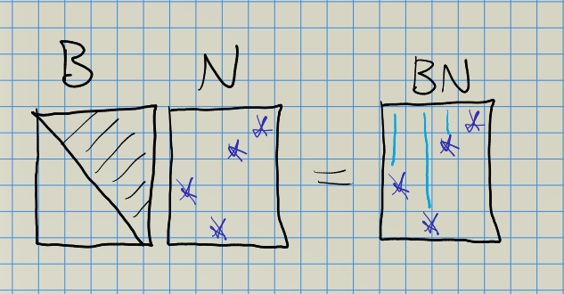

Similarly, multiplying on the right smears rightward, and it’s not so hard to convince yourself that these generate $\operatorname{GL}_n$.

For the conjugation axiom, consider the following:

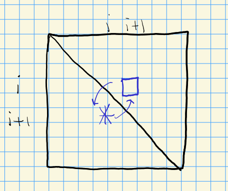

We also have $B\mkern 1.5mu\overline{\mkern-1.5mus\mkern-1.5mu}\mkern 1.5mu B\mkern 1.5mu\overline{\mkern-1.5muw\mkern-1.5mu}\mkern 1.5mu B \subseteq B\mkern 1.5mu\overline{\mkern-1.5muw\mkern-1.5mu}\mkern 1.5mu B \cup B \mkern 1.5mu\overline{\mkern-1.5mus\mkern-1.5mu}\mkern 1.5mu \mkern 1.5mu\overline{\mkern-1.5muw\mkern-1.5mu}\mkern 1.5mu B$. To prove this, we’ll show

- $\mkern 1.5mu\overline{\mkern-1.5mus\mkern-1.5mu}\mkern 1.5mu B \mkern 1.5mu\overline{\mkern-1.5muw\mkern-1.5mu}\mkern 1.5mu \subseteq$ the RHS,
- The right-hand side is stable under the $B\times B$ action of left/right multiplication.

To see the first, consider the example:

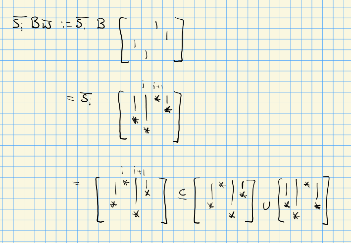

For the second, consider
$$\begin{align*}
(1,3,2,4)(3,4,1,2) = (2,4,1,3)
.\end{align*}
The hard case is when lengths of the result change.$$

Any $B \subseteq P \subseteq G$ is called a **standard parabolic**. Any subgroup $Q$ conjugate to $P$ is called **parabolic**.

Standard parabolics correspond to subsets $Y$ of simple reflections $\emptyset \subseteq Y \subseteq S$. Any subgroup containing the upper triangular matrices looks like the following:

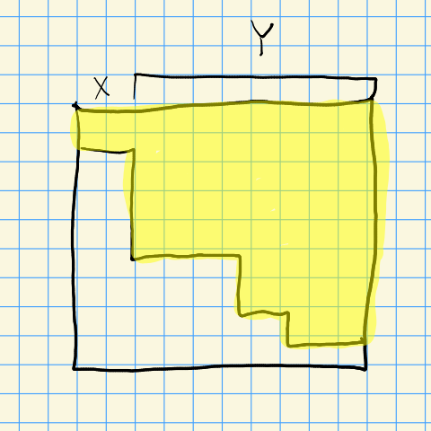

For $P_Y$, we take everything but skip the first index.

# 11 Generalized Flag Varieties, 7.1 (Wednesday, September 15)

Most of the things we’ll look at will be motivated by the finite-type case, but the statements still go through more generally. The setup: $A$ a GCM $\leadsto$ root datum $({\mathfrak{h}}, \pi, \pi {}^{ \vee }) \leadsto {\mathfrak{g}}$ a Kac-Moody Lie algebra $\leadsto (W, S)$ a Coxeter group $\leadsto T \subseteq B$ a maximal torus, where $T = \mathop{\mathrm{Hom}}_{\mathbb{Z}}({\mathfrak{h}}_{\mathbb{Z}}, {\mathbb{C}}^{\times})$ and $B$ plays the role of the Borel, $\leadsto {\mathcal{G}}$ a Kac-Moody group. Here ${\mathfrak{h}}_{\mathbb{Z}}$ is the integer span of coroots, using that ${\mathfrak{h}}\subseteq \pi {}^{ \vee }$. Note that since ${\mathcal{G}}$ arises from a Tits system, so even though we haven’t described it set-theoretically yet, we know many nice properties it has by previous propositions.

For $G\in {\mathsf{Alg}}{\mathsf{Grp}}$ arbitrary and $H\leq G$, the quotient space $G/H$ is a variety (See Springer’s book for a proof). Write $G/H = (X, a)$ where $a= H/H$ is a distinguished point. Quotients have a universal property: for any pair $(Y, b)$ of pointed $G{\hbox{-}}$spaces whose isotropy (stabilizer) group contains $H$, there exists a unique equivariant pointed morphism $\phi: G/H\to Y$ such that $\phi(a) = b$.

Today: we defined a flag variety to be any projective homogeneous space, and today we’ll see that $G/B$ is a *projective* variety. In fact, we’ll show that ${\mathcal{G}}/P_Y$ is a projective *ind-variety*, where $P_Y$ is the standard parabolic coming from the Tits system.

An **Ind-variety** is a set with a countable filtration $X_0 \subseteq X_1 \subseteq \cdots$ such that

- $X = \colim_n X_n = \displaystyle\bigcup_n X_n$,
- Each $X_n \hookrightarrow X_{n+1}$ is a closed embedding of finite-dimensional varieties.

$X$ will be projective/affine iff its filtered pieces are projective/affine.

Note that we don’t require a stratification here, but there will be a stratification on the flag varieties we’ll use, which induces a filtration.

Infinite affine space ${\mathbb{A}}^\infty_{/ {k}}$ can be written as
$$\begin{align*}
{\mathbb{A}}^\infty_{/ {k}} = \left\{{ (a_1,a_2,\cdots) {~\mathrel{\Big\vert}~}a_i \in k, \text{ finitely many } a_i\neq 0}\right\}
.\end{align*}
The filtration is given by
\begin{align*}
{\mathbb{A}}^1 &\hookrightarrow{\mathbb{A}}^\infty \\
x &\mapsto (x,0,0,\cdots) \\ \\
{\mathbb{A}}^2 &\hookrightarrow{\mathbb{A}}^\infty \\
(x, y) &\mapsto (x,y,0,\cdots) \\
\vdots &
\end{align*}$$

For $V\in {\mathsf{{\mathbb{C}}}{\hbox{-}}\mathsf{Mod}}$ with $\dim_{\mathbb{C}}V = \infty$, we have $V\cong {\mathbb{A}}^\infty_{/ {{\mathbb{C}}}}$ as Ind-varieties.

For any $V\in {\mathsf{{\mathbb{C}}}{\hbox{-}}\mathsf{Mod}}$, the space ${\mathbb{P}}(V) \mathrel{\vcenter{:}}={\operatorname{Gr}}_1(V)$ (the space of lines in $V$) is a projective Ind-variety.

For any integrable highest weight ${\mathfrak{g}}{\hbox{-}}$module $V = V(\lambda)$ for $\lambda \in D_{\mathbb{Z}}$ an integral dominant weight, this will yield a ${\mathcal{G}}{\hbox{-}}$module. Here for ${\mathfrak{g}}$ semisimple, it integrates to the simply connected ${\mathcal{G}}$.

For any $v_\lambda \neq 0\in V$, define
$$\begin{align*}
\mkern 1.5mu\overline{\mkern-1.5mu\iota\mkern-1.5mu}\mkern 1.5mu_v: {\mathcal{G}}&\to {\mathbb{P}}(V) \\
g &\mapsto [gv_\lambda]
,\end{align*}$$

For any $Y \subseteq \left\{{1,\cdots,\ell}\right\}$, define $D_Y^0$ the **$Y{\hbox{-}}$regular weights** by
$$\begin{align*}
D_Y^0 \mathrel{\vcenter{:}}=\left\{{ \lambda\in D_{\mathbb{Z}}{~\mathrel{\Big\vert}~}{\left\langle { \lambda},~{ \alpha_i} \right\rangle} = 0 \iff i \in Y}\right\}
.\end{align*}
This partitions the integral dominant chamber:$$

[figure not shown]

For $\lambda \in D_Y^0$ the map $\mkern 1.5mu\overline{\mkern-1.5mu\iota\mkern-1.5mu}\mkern 1.5mu_v$ factors through ${\mathcal{G}}/P_Y$ to give an injection
$$\begin{align*}
\iota_v: G/P_Y \hookrightarrow{\mathbb{P}}(V)
.\end{align*}
So any Kac-Moody maps into an Ind-variety.$$

We’ll show that $\operatorname{im}\iota_v \subseteq {\mathbb{P}}(V)$ is closed, i.e. that its intersection with any finite filtered piece is closed. The variety structure will be induced from this embedding.

We have a distinguished point $[v_\lambda] \in {\mathbb{P}}(V)$, so ${\operatorname{Stab}}_G([v_ \lambda]) \supseteq P_Y$. Showing this amounts to showing that for all $s\in Y$, $\mkern 1.5mu\overline{\mkern-1.5mus\mkern-1.5mu}\mkern 1.5mu\in G$ fixes $[v _{\lambda} ]$, but this follows from the definition of $v_\lambda$.

A great class of varieties: Bott-Samelson-Demazure-Hansen varieties, which capture the geometry of words in Coxeter groups. We’ll have $w\in W, \mkern 1.5mu\overline{\mkern-1.5muw\mkern-1.5mu}\mkern 1.5mu\in N$, and we’ll define ${\mathfrak{W}}\ni w$ as words: \begin{align*} {\mathfrak{W}}\mathrel{\vcenter{:}}=\left\{{w = (s_{i_1}, \cdots, s_{i_n} ) {~\mathrel{\Big\vert}~}n\geq 0}\right\} ,\end{align*} which is a poset under deleting symbols. For any $w\in {\mathfrak{W}}$, define $Z_w \mathrel{\vcenter{:}}=\prod_{k\leq n} P_{i_k} / B{ {}^{ \scriptscriptstyle\times^{n} } }$, where the action of the Borel is the *right mixed space action*:
$$\begin{align*}
(p_1, \cdots, p_n)(b_1, \cdots, b_n) = (p_1 b_1, b_1^{-1}p_2 b_2, b_2^{-1}p_3 b_3,\cdots, b_{n-1}^{-1}p_n b_n)
.\end{align*}$$

Take $G = \operatorname{GL}_3({\mathbb{C}})$, so $S = (s_1, s_2)$ and $w= (s_{i_1}, s_{i_2})$, then
$$\begin{align*}
Z_w = (P_{i_1} \times P_{i_2})/B{ {}^{ \scriptscriptstyle\times^{2} } } = P_{i_1} \overset{\scriptscriptstyle {B} }{\times} P_{i_2}/B = P_{i_1}{ \underset{\scriptscriptstyle {B} }{\times} } P_{i_2}/B \to P_{i_1}/M \cong {\mathbb{P}}^1
,\end{align*}
so these are all bundles over \({\mathbb{P}}^1\) with fibers \({\mathbb{P}}^1\), and are in fact Hirzebruch surfaces.$$

1. $Z_w$ is an irreducible smooth variety with a $P_{i_1}{\hbox{-}}$action.
2. $Z_w\to P_{i_1}/B$ is locally trivial with fiber $Z_{w'}$ where $w'$ is obtained from $w$ by deleting the first reflection, so $s' = (s_{i_2}, \cdots, s_{i_n})$.
3. $Z_w \xrightarrow{\psi} Z_{w_1}$ where $w_1 \mathrel{\vcenter{:}}= w[n-1] \mathrel{\vcenter{:}}=(s_1, \cdots, s_{i_n - 1})$ where $[p_1,\cdots, p_n] \xrightarrow{\psi} [p_1,\cdots, p_{n-1}]$. This admits a section $[p_1,\cdots, p_{n-1}] \xrightarrow{\sigma} [p_1,\cdots, p_{n-1}, 1]$.
4. $Z_w$ is a projective variety.

Why projective: it’s a fiber bundle of compact varieties, thus compact and complete. A bit more goes into fully showing projectivity.

Define a map
$$\begin{align*}
m_w: Z_w &\to {\mathcal{G}}/B \\
[p_1, \cdots, p_n] &\mapsto p_1\cdots p_n B
,\end{align*}
then \(\operatorname{im}m_w = \displaystyle\bigcup_{v\leq w} BvB/B \subseteq {\mathcal{G}}/B\).$$

This is where the projective variety structure comes from, and we’ll discuss when the image hits Schubert varieties.

# 12 7.1 (Friday, September 17)

See Fulton, Young Tableaux.

Given $A$ we produce ${\mathcal{G}}$ a Kac-Moody group, with standard parabolics $P_{\lambda} \subseteq {\mathcal{G}}$. We’ll show $G/P_{\lambda} \hookrightarrow{\mathbb{P}}(V)$ for some projective space over $V$ an integrable highest weight space in ${\mathsf{{\mathfrak{g}}}{\hbox{-}}\mathsf{Mod}}$, which is generally an Ind-variety, and if we show it’s closed it will inherit the structure of a projective variety. Write $V = L^{\max}( \lambda) = V_{ \lambda}$ as a highest weight module.

Idea: for $m_w: Z_w \to {\mathcal{G}}/B$ for $Z_w$ a BSDH, for any word $w\in {\mathcal{W}}$, if $w\in W_Y'$ is reduced, compose the above map with ${\mathcal{G}}/B \to {\mathcal{G}}/ P_{Y}$ to get a map
$$\begin{align*}
m_w^Y: Z_w \to {\mathcal{G}}/P_Y
.\end{align*}$$

We’ll show $Z_w$ is projective, which is easier since it’s an iterated line bundle. Let $v_0 \in V_\lambda$ (thought of in the finite type case as a highest weight vector in the irreducible, but may generally not coincide) consider the maps

$$\begin{align*}
\mkern 1.5mu\overline{\mkern-1.5mu\iota\mkern-1.5mu}\mkern 1.5mu_V: {\mathcal{G}}&\to {\mathbb{P}}(V) \\
\iota_V: {\mathcal{G}}/P_Y &\to {\mathbb{P}}(V) \\
m_w(v_0) = \iota_{v_0} \circ m_w^Y: Z_w &\to {\mathbb{P}}(V)
.\end{align*}$$

1. $m_w(v_0)$ a morphism of varieties: easy to believe, hard to show! See the book.
2. $$\begin{align*}
   \operatorname{im}(m_w(v_0)) = \displaystyle\bigcup_{v\leq w, v\in W_Y'} BvP_Y/P_Y \subseteq {\mathcal{G}}/P_Y
   ,\end{align*}
   which is some subvariety of the flag variety which we’ll define as the Schubert variety \(X_W^Y\).$$

For $Y \subseteq S, w\in W_Y'$, and let $w = w_1\cdots w_k$ a reduced decomposition, $\ell(w) = \sum \ell(w_i)$. Let $Z_i \subseteq P_{w_i} \mathrel{\vcenter{:}}= P_{\left\{{w_i}\right\}}$ be a subset of a simple parabolic such that $Z_i \twoheadrightarrow P_{w_i}/B$.[^2]

Then
$$\begin{align*}
\operatorname{im}\qty{\prod Z_i \xrightarrow{\text{mult}} G \twoheadrightarrow G/P_Y} = \displaystyle\bigcup_{v\leq w} BvP_Y/P_Y
.\end{align*}$$

Where does the additional condition $v\in W_Y'$ come from in the theorem statement? Take a Bruhat decomposition
$$\begin{align*}
{\mathcal{G}}/B = \displaystyle\coprod_{\substack{ v\leq w \\ v\in \dcoset{W}{W_Y}{W_Y} }} P_{Y'}vP_V
.\end{align*}$$

Take $G = \operatorname{GL}_n$, then

- $\lambda\in X {}^{ \vee }(T)$
- $\lambda(t) = t_1\cdots t_k$ for $1\leq k\leq n$,
- $\lambda \in D_{\mathbb{Z}}$ and $V_{\lambda} = \bigwedge\nolimits^k {\mathbb{C}}^n$.
- $S = \left\{{1, \cdots, \ell}\right\}$ where $\ell = n-1$.
- $G/P_Y \subseteq {\mathbb{P}}( \bigwedge\nolimits^k {\mathbb{C}}^n)$,
- $Y( \lambda) \mathrel{\vcenter{:}}=\left\{{1\leq i \leq \ell {~\mathrel{\Big\vert}~}\lambda(\alpha_i {}^{ \vee }) = 0}\right\}$.

Then
$$\begin{align*}
\lambda &\in (1, \cdots_k, 1, 0, \cdots_{n-k}, 0)\\
\alpha_i {}^{ \vee }&= (0, \cdots, 1, -1, 0, \cdots, 0)
,\end{align*}
so we can write \(Y( \lambda) = \left\{{1,\cdots, k-1, k+1, \cdots, n-1}\right\} = \mkern 1.5mu\overline{\mkern-1.5muk\mkern-1.5mu}\mkern 1.5mu\). Then set \(F^k \in {\mathbb{P}}(\bigwedge\nolimits^k {\mathbb{C}}^n) = {\operatorname{Gr}}_k({\mathbb{C}}^n)\), so \(0 \subseteq F^k \subseteq {\mathbb{C}}^n\), and define the map
\begin{align*}
\iota_{\lambda}(F^k) = [f_1 \vee f_2 \vee\cdots \vee f_k]
,\end{align*}
where \(\left\{{f_i}\right\}\) is a choice of ordered basis.$$

Some facts about $Z_w = \prod^B_{1\leq k\leq m} P_{i_k}/B$, recalling the action of $B$ given last time. Set $w= (s_{i_1}, \cdots, s_{i_m}) \in {\mathcal{W}}$. There is a map
$$\begin{align*}
\varphi: P_{i_1}\overset{\scriptscriptstyle {B} }{\times} \cdots \overset{\scriptscriptstyle {B} }{\times} P_{i_m} &\to B/B \times G/B \times \cdots \times G/B \\
[p_1,\cdots, p_m] &\mapsto [B/B, p_1 B/B, p_1p_2 B/B, \cdots, p_1\cdots p_m B/B]
.\end{align*}$$

Showing this is well-defined: follows from universal property of quotients, looking at where point stabilizers are contained. Then
$$\begin{align*}
\operatorname{im}\varphi =
B/B { \underset{\scriptscriptstyle {G/P_{i_1}} }{\times} }
G/B { \underset{\scriptscriptstyle {G/P_{i_2}} }{\times} }
\times \cdots
{ \underset{\scriptscriptstyle {G/P_{i_m}} }{\times} } G/B
.\end{align*}$$

How to define the BSDH: construct a lattice by deleting elements in the sequence of flags corresponding to various words, and take the right-most flag in the result:

[figure not shown]

> Link to Diagram

Here the word is $(i_{n-2}, i_1, i_2, i_{3}, i_{n-1}, i_{n-2})$.

# 13 Equivariant ${\mathsf{K}}{\hbox{-}}$theory (Wednesday, September 22)

The setup: $G\curvearrowright X$ a topological group acting on a space.

- Gelfand (30s): replace $X$ with a topological vector space $T$, e.g. “generalized functions” on $X$. This linearises the problem, but is usually something like a infinite dimensional Hilbert space.
- Harish-Chandra, Vogan: Replace $T$ with an algebraic object (usually finite-dimensional) and apply ${\mathsf{K}}{\hbox{-}}$theory. Here ${\mathsf{K}}{\hbox{-}}$theory simplifies the problem, since all invariants that are additive on exact sequences can be recovered from it.

Classical literature on this is phrased in terms of $X$ a *separated algebraic space*, since even nice quotients of varieties are often not again varieties. We’ll assume $X$ is an algebraic variety, automatically separated, and quasiprojective. This will imply that $X \subseteq G/P$ embeds into a flag variety, e.g. for $G = \operatorname{GL}_n$ and $P$ a parabolic this covers ${\mathbb{P}}^n$. For us, projective will mean that $X \subseteq G/P$ is closed, which will turn out to admit ample line bundles.

Let $({-})^ {\operatorname{gp} }$ denote taking the Grothendieck group, then
$$\begin{align*}
G_0(G, X) \mathrel{\vcenter{:}}={\mathsf{Coh}}^G(X)^ {\operatorname{gp} } \\
{\mathsf{K}}_0(G, X) \mathrel{\vcenter{:}}={ {\mathsf{Bun}}\qty{\operatorname{GL}_r} }^G_{/ {X}}
,\end{align*}
i.e. the \(G{\hbox{-}}\)equivariant coherent sheaves and vector bundles respectively.$$

Note that vector bundles don’t form an abelian category – here instead you take the additive monoid generated by addition of vector bundle. However coherent sheaves do form an abelian category, so this denotes the usual Grothendieck group for abelian categories. Of modern interest: split Grothendieck groups, triangulated, etc.

Here one should think of ${\mathsf{G}}$ as something analogous to Borel-Moore homology, and ${\mathsf{K}}$ is closer to cohomology. Note that in classical settings, one could cap against the fundamental class to get a map between them.

If $X$ is a smooth $G{\hbox{-}}$variety admitting an equivariant ample line bundle, then there is an isomorphism
$$\begin{align*}
{\mathsf{K}}_0(G, X) \xrightarrow{?} G_0(G, X)
.\end{align*}$$

This map records how a vector bundle can be regarded as a coherent sheaf! For the rest of today, we’ll assume $X$ admits a $G{\hbox{-}}$equivariant ample line bundle and refer to this as condition $\star$. If this proposition holds, notationally we’ll always write ${\mathsf{K}}^G(X) = {\mathsf{K}}_0(X) = G_0(X)$.

Consider the coherent sheaf ${\mathcal{O}}_x{ {}^{ \scriptscriptstyle\oplus^{n} } }$, which should correspond to the trivial bundle $X\times {\mathbb{C}}^n \to X$. If $\xi$ is a vector bundle, then the sheaf of sections is a locally free coherent sheaf.

Every $G{\hbox{-}}$equivariant coherent sheaf ${\mathcal{F}}\in {\mathsf{Coh}}^G(X)$ on $X$ admits a finite resolution by $G{\hbox{-}}$equivariant locally free sheaves of finite type.

- If $G =1$, then admitting an ample line bundle as above is equivalent to $X \subseteq G/P$ being a subvariety. Then ${\mathsf{K}}^G(X) = {\mathsf{K}}(X)$, the algebraic ${\mathsf{K}}{\hbox{-}}$theory, of $X$.
- If $X = {\operatorname{pt}}$, it is smooth, and ${\mathsf{K}}^G(X) = R(G)$, the representation ring of $G$. This holds for $G$ any linear algebraic group.

So this mixes usual ${\mathsf{K}}{\hbox{-}}$theory and representation theory! It turns out that for $X={\operatorname{pt}}$, there is an equivalence of categories ${\mathsf{Coh}}^G({\operatorname{pt}}) = { {\mathsf{Bun}}\qty{\operatorname{GL}_r} }^G = {\mathsf{G}{\hbox{-}}\mathsf{Mod}}^{\mathrm{fd}}$.

If $X$ is projective and $G$ is semisimple, then $\star$ is true. If $E\to X$ is a $G{\hbox{-}}$vector bundle on $X$ smooth projective, then we’ll write ${\mathsf{K}}^G(X)$ for ${\mathsf{G}}_0(G, X) = {\mathsf{K}}_0(G, X)$.

Every ${\mathcal{F}}\in {\mathsf{Coh}}^G(X)$ is a quotient of a $G{\hbox{-}}$equivariant locally free sheaf ${\mathcal{E}}$ of finite type on $X$.

> See proof: Borho, Byrlinksi, MacPherson. Geometric perspective on ring theory?

Let $G \in {\mathsf{Alg}}{\mathsf{Grp}}$ be linear acting on $V\in {\mathsf{{\mathbb{C}}}{\hbox{-}}\mathsf{Mod}}$ possibly infinite dimensional. This is common, e.g. when $G$ consists of regular functions. This is infinite dimensional, but not so bad – it’s not quite as big as a Hilbert space. We’ll say the action is **algebraic** if it acts locally finitely: the $G{\hbox{-}}$orbit of any vector should be a finite dimensional subspace. Consider $\mathop{\mathrm{Maps}}(G, M) \mathrel{\vcenter{:}}=\mathop{\mathrm{Hom}}_{{\mathsf{Set}}}(G, M) = \left\{{ f:G\to M}\right\}$ with no conditions at all on the functions. There is a subspace of “regular functions with coefficients in $M$,” using the following well-defined map:
$$\begin{align*}
{\mathbb{C}}[G] \otimes_{\mathbb{C}}M &\to \mathop{\mathrm{Maps}}(G, M) \\
\sum f_i \otimes m_i &\mapsto \sum f(g_i) m_i
,\end{align*}
using that the \(f(g_i)\) are scalars in \(M\).$$

For a fixed $m$, there is a $G{\hbox{-}}$action $g\mapsto gm$, and so letting $m$ vary yields a map $M \xrightarrow{a_M} \mathop{\mathrm{Maps}}(G, M)$.

$G$ acts algebraically on $M$ iff $\operatorname{im}a_m \subseteq {\mathbb{C}}[G]\otimes_{\mathbb{C}}M$.

If the action is algebraic, take $G_m \subseteq V \subseteq M$ with $V$ a $G{\hbox{-}}$stable finite dimensional subspace. Expanding in a basis and writing $g\mapsto gm$ in this basis yields the $f_i$, which are regular.

If ${\mathcal{F}}\in {\mathsf{Coh}}^G(X)$, then ${{\Gamma}\qty{X; {\mathcal{F}}} }$ has the natural structure of an algebraic $G{\hbox{-}}$module.

# 14 Localization in Equivariant ${\mathsf{K}}{\hbox{-}}$theory (Friday, September 24)

## 14.1 Localization Theorems

> Reference: Thomason.

Suppose $A\in {\mathsf{Ab}}{\mathsf{Alg}}{\mathsf{Grp}}$ is reductive, and $X \subseteq G/P$ is contained in a flag variety (so $X$ is quasiprojective). Fix $a\in A$, and consider the fixed point set $X^a$ and the inclusion $\iota: X^a \xrightarrow{\subseteq } X$. We’ll say the **localization theorem holds for $X$** if the following induced hom is an isomorphism:
$$\begin{align*}
i_*: {\mathsf{K}}^A(X^a) \left[ { \scriptstyle { {{\mathfrak{m}}_a}^{-1}} } \right] \to {\mathsf{K}}^A(X) \left[ { \scriptstyle { {{\mathfrak{m}}_a}^{-1}} } \right]
.\end{align*}$$

Thomason shows that this is true in this situation. Recall that we identified $R(A) = {\mathsf{K}}^A({\operatorname{pt}})$. Taking the trace of a representation yields a map $R(A) \hookrightarrow{\mathbb{C}}[A]$, the ring of regular functions. For varieties, we can obtain ${\mathcal{O}}_{X, x}$ by localizing rings at their maximal ideals, thinking of these as functions on $X$. Let
$$\begin{align*}
R_a &\mathrel{\vcenter{:}}= R(A) \left[ { \scriptstyle { { \qty{ R(A)\setminus{\mathfrak{m}}_a} }^{-1}} } \right] \\
M_a &\mathrel{\vcenter{:}}= R(A) \otimes_{R(A)} M
.\end{align*}$$

## 14.2 Proper Pushforward

We’ll need proper maps for the ever-popular *decomposition theorem*. However, almost every scheme we use in this class will be reduced, although one does rarely have to worry about this.

**Pullbacks** are universal with respect to the following squares, and have a concrete description for us:

[figure not shown]

> Link to Diagram

The **diagonal** is the unique morphism $\Delta: X\to X{ \underset{\scriptscriptstyle {Y} }{\times} } X$ whose compositions with projections are the identity:

[figure not shown]

> Link to Diagram

A morphism is **separated** if the diagonal is a closed embedding.

A morphism $f:X\to Y$ is **universally closed** if for any $g:Z\to Y$, the base change $f': X{ \underset{\scriptscriptstyle {Y} }{\times} } Z\to Z$ is a closed morphism. This replaces the notion of “$K$ compact $\implies f^{-1}(K)$ compact” for analytic varieties.

A morphism $f$ is **proper** if $f$ is separated, finite type, and universally closed.

- Closed embeddings are proper, and open maps are usually not.
- If $f$ is proper, its base change $f'$ is always proper.
- Compositions of proper morphisms are again proper.
- Any morphism between projective varieties is proper.

Let $f:X\to Y$ be proper and ${\mathcal{F}}\in {\mathsf{Coh}}(X)$. Note that ${{\Gamma}\qty{X, {-}} }$ is exact and ${\mathsf{Coh}}(X)$ is abelian, so we can take its derived functor. Let $f_*: {\mathsf{Sh}}_{/ {X}} \to {\mathsf{Sh}}_{/ {Y}}$, then e.g.
$$\begin{align*}
{\mathbb{R}}^i f_* {\mathcal{F}}(U) = H^i(f^{-1}(U); {\mathcal{F}})
.\end{align*}$$

This satisfies several properties:

1. ${\mathbb{R}}^if_*: {\mathsf{Coh}}(X) \to {\mathsf{Coh}}(Y)$ is a covariant functor. Without properness, one can just replace ${\mathsf{Coh}}$ with ${\mathsf{QCoh}}$.
2. ${\mathbb{R}}^0 f_* = f_*$
3. A SES $0\to{\mathcal{F}}_1\to{\mathcal{F}}_2\to{\mathcal{F}}_3\to 0$ induces a LES.

If $f:X\to Y$ is a proper projective morphism, then ${\mathbb{R}}^{i>d} f_* {\mathcal{F}}= 0$ for $d$ defined as the maximum dimension of the fiber, $d\mathrel{\vcenter{:}}=\max_{y\in Y} \dim f^{-1}(y)$.

Let $X, Y$ be arbitrary quasiprojective varieties and $f:X\to Y$ be proper and $G{\hbox{-}}$equivariant. Then there is a natural direct image morphism $f_*: {\mathsf{K}}^G(X) \to {\mathsf{K}}_G(Y)$.

We define it as follows: note that a map such as $f_*([{\mathcal{F}}]) \mathrel{\vcenter{:}}=[f_* {\mathcal{F}}]$ won’t necessarily be well-defined, since SESs are additive in the Grothendieck group. For ${\mathcal{F}}\in {\mathsf{Coh}}^G(X)$, then it turns out that ${\mathbb{R}}f_* {\mathcal{F}}\in {\mathsf{Coh}}^G(Y)$ and the higher direct images vanish in large enough degree. We then define
$$\begin{align*}
f_*: {\mathsf{K}}^G(X) &\to {\mathsf{K}}_G(Y) \\
[{\mathcal{F}}] &\mapsto \sum (-1)^i [{\mathbb{R}}^i f_* {\mathcal{F}}]
.\end{align*}$$

Let $G$ be connected reductive with $A \mathrel{\vcenter{:}}= T$ a maximal torus, which is abelian reductive. Then take $a\in A$ a *regular* element, so $X^a = X^T$. In our case, $X^T = W_Y'$, and $X = G/P_Y$. Then ${\mathsf{K}}{\hbox{-}}$theory is concentrated on the fixed locus:
$$\begin{align*}
i_* {\mathsf{K}}^T(X^T) \left[ { \scriptstyle { {{\mathfrak{m}}_a}^{-1}} } \right] { { \, \xrightarrow{\sim}\, }}{\mathsf{K}}^T(X) \left[ { \scriptstyle { {{\mathfrak{m}}_a}^{-1}} } \right]
.\end{align*}$$

# 15 Line Bundles on ${\mathcal{X}}^Y$ (Monday, September 27)

Notation: ${\mathcal{X}}$ will denote a Kac-Moody flag variety, and $X$ a usual flag variety. For any $\lambda \in D_Y^0$, define the algebraic line bundle ${\mathcal{L}}(-\lambda) \to {\mathcal{X}}^Y$ to be the pullback of the tautological bundle on ${\mathbb{P}}(L^{\max}(\lambda))$ via the morphism $\iota_\lambda: {\mathcal{X}}^Y \to {\mathbb{P}}(L^{\max} (\lambda))$. Recall that we defined $Y{\hbox{-}}$regular weights to get an embedding into a flag variety.

Let $X$ be a finite dimensional variety, then a vector bundle on $X$ is a map ${\mathcal{E}}\xrightarrow{\pi} X$ with each fiber a ${\mathbb{C}}{\hbox{-}}$module and for all $x\in X$ there exists an open $U \subseteq X$ and a homeomorphism $\phi: U \times {\mathbb{C}}^n \to \pi^{-1}(U)$ over $U$, so the following diagram commutes:

[figure not shown]

> [Link to Diagram](https://q.uiver.app/?q=WzAsMyxbMCwwLCJcXHBpXFxpbnYoVSkiXSxbMiwwLCJVXFx0aW1lcyBcXENDXm4iXSxbMSwyLCJVIl0sWzAsMiwiXFxwaSIsMl0sWzEsMiwiXFxwcl8xIl0sWzAsMSwiXFxwaGkiXV0=)

We refer to $\phi$ as a trivialization. Writing $U_{12} \mathrel{\vcenter{:}}= U_1 \cap U_2$, given trivializations over $U_i$ we require that the trivializations on $U_{12}$ are related by an element $T_{12} \in \operatorname{GL}_n$, and the induced map $U_{12} \times {\mathbb{C}}^n{\circlearrowleft}$ are essentially given by matrices with entries given by functions on $U_{12}$ The key is that these satisfy the cocycle condition:
$$\begin{align*}
T_{kj}\mathrel{\Big|}_{U_{ijjk}} T_{ji} \mathrel{\Big|}_{U_{ijk}} = T_{ki}\mathrel{\Big|}_{U_{ijk}}
.\end{align*}$$

Given a vector bundle, set ${\mathcal{F}}$ to be the sheaf of sections of $\pi: {\mathcal{E}}\to X$. If for example $U \subseteq X$ is trivializable, then ${{\Gamma}\qty{U, {\mathcal{F}}} }$ are $n{\hbox{-}}$tuples of functions $U\to {\mathbb{C}}$, so ${ \left.{{{\mathcal{F}}}} \right|_{{U}} }\cong {\mathcal{O}}_U{ {}^{ \scriptscriptstyle\oplus^{n} } }$, making it locally free.

Given a vector bundle, set ${\mathcal{F}}$ to be the sheaf of sections of $\pi: {\mathcal{E}}\to X$. Then

1. If ${\mathcal{F}}$ is locally free, then $\mathop{\mathrm{Hom}}_{{\mathsf{Sh}}_{/ {X}} }({\mathcal{F}}, {\mathcal{O}}_X) \in {\mathsf{Sh}}_{/ {X}}$ is locally free.
2. If $n=1$, then ${\mathcal{F}}\otimes{\mathcal{F}} {}^{ \vee }\cong {\mathcal{O}}_X$, making it an invertible sheaf under the monoidal tensor product.
3. Pullbacks of locally free sheaves are again locally free:

[figure not shown]

where we equivalently write $f^* {\mathcal{F}}$.

How to think about a flag variety: given $w\in W_Y'$ and $U_W \subseteq X^Y$, so $U^- \subseteq G/P$. Then $\left\{{U_w}\right\}_{w\in W_Y'} \rightrightarrows X^Y$ is an open cover with $U_w \cong {\mathbb{C}}^{\ell(w_0')}$ with $w_0$ the longest element and $w_0'$ is a minimal coset representative. If $v\in U_w \iff v=w$ for any $T{\hbox{-}}$fixed point $v$, so there’s only one such fixed point in every open. We have elements $wP/p \in X^Y$, so

[figure not shown]

For $G \mathrel{\vcenter{:}}={\operatorname{SL}}_{n+1}$, we have $Y = \left\{{2,\cdots, n}\right\}, W = S_{n+1} = \left\{{(w_0 \cdots w_n)}\right\}$ and the minimal length representatives have increasing coordinates, so we get
$$\begin{align*}
W_Y' = \left\{{(0 \mathrel{\Big|}1,2\cdots, n), (1 \mathrel{\Big|}0, 2, \cdots, n), \cdots , (n\mathrel{\Big|}0,1\cdots, n-1)}\right\}
.\end{align*}
For every \(i\in W_Y' = \left\{{0, \cdots, n}\right\}\), we have \(U_i \subseteq X^Y \subseteq G/P_Y\). We can obtain \({\mathbb{P}}^n \cong \leftquotient{{\mathbb{C}}^{\times}}{{\mathbb{C}}^{n+1}}\), which is \(G/P^Y = X^Y\) here. So we can take \(U_i \mathrel{\vcenter{:}}=\left\{{ {\left[ {x_0,\cdots, x_n} \right]} {~\mathrel{\Big\vert}~}x_i\neq 0 }\right\} \subseteq {\mathbb{C}}^n\), which is dimension \(n\) since the longest element is \((n \mathrel{\Big|}0,1,\cdots, n-1)\).$$

Let $k\in {\mathbb{Z}}$, we’ll define ${\mathcal{O}}_{{\mathbb{P}}^n}(k)$, a line bundle on ${\mathbb{P}}^n$. Taking $n=1$ to get ${\operatorname{SL}}_2$ and ${\mathbb{P}}^1$ above, we have $W_Y' = \left\{{0, 1}\right\}$ and ${\mathbb{C}}= U_1 = \operatorname{Spec}{\mathbb{C}}[x_{0/1}]$ and $U_0 = \operatorname{Spec}{\mathbb{C}}[x_{0/1}]$, then on their intersection we have $x_{0/1} = x_{1/0}^{-1}$. So transitioning $U_0\to U_1$ is given by $x_{0/1}^k = x_{1/0}^{-k}$, and $U_1\to U_0$ by $x_{1/0}^k = x_{0/1}^{-k}$, which defines a line bundle denoted ${\mathcal{E}}\mathrel{\vcenter{:}}={\mathcal{O}}(k)$. What are the global sections ${{\Gamma}\qty{{\mathbb{P}}^1; {\mathcal{O}}(k)} }$? This requires $f(x_{0/1}^{-1}) x_{0/1}^k = g(x_{0/1})$, so the global sections are ${\mathbb{C}}[x,y]_{k}$ the homogeneous polynomials of degree $k$. One can check that $\dim {{\Gamma}\qty{{\mathbb{P}}^n; {\mathcal{O}}(k)} } = {n+k \choose k}$.

Next time: we’ll try to match these up with line bundles of the form $G \overset{\scriptscriptstyle {P} }{\times} {\mathbb{C}}_\lambda$.

# 16 Wednesday, September 29

Ch. 7 and 8 in Kumar: algebraic vector bundles, particularly line bundles on ind-varieties. Let ${\mathcal{E}}\xrightarrow{\pi} X$ be an algebraic vector bundle, so there are local trivializations:

[figure not shown]

i.e. these look like projections onto the first coordinate of an actual product on sufficiently small sets. We write ${\mathcal{E}}_x \mathrel{\vcenter{:}}=\pi^{-1}(x)$. The key data: transition functions.

Our first examples were ${\mathcal{O}}_{{\mathbb{P}}^n}(k)$, particularly for $n=1$.

Equivariant coherent sheaves yields algebraic representations by taking global sections. Kumar uses character formulas to compute global sections.

For $G\in {\mathsf{Alg}}{\mathsf{Grp}}$ is linear (and e.g. connected reductive), if $\pi$ is $G{\hbox{-}}$equivariant and $G$ maps ${\mathcal{E}}_x\to {\mathcal{E}}_{gx}$ *linearly*, then $\pi$ yields an **equivariant vector bundle**.

For $G$ connected reductive and $T \subseteq G$ a maximal torus, a character $\lambda \in X^*(T)$ is a map $\lambda: T\to {\mathbb{C}}^{\times}$, and using $T \subseteq B \subseteq G$ we get a representation $\lambda: B\to {\mathbb{C}}^{\times}$ of the Borel. We then define
$$\begin{align*}
G\overset{\scriptscriptstyle {B} }{\times} {\mathbb{C}}_{\lambda} \mathrel{\vcenter{:}}=(G\times {\mathbb{C}})/B
.\end{align*}
There is a map$$

[figure not shown]

> Link to Diagram

Even better, if $Y = \left\{{1\leq i\leq \ell {~\mathrel{\Big\vert}~}{\left\langle {\lambda},~{\alpha_i {}^{ \vee }} \right\rangle} }\right\}$ then taking $\lambda \in D_Y^0$ so $\lambda: P \to {\mathbb{C}}^{\times}$ yields a map $G\overset{\scriptscriptstyle {P} }{\times} {\mathbb{C}}_{ \lambda} \xrightarrow{\pi} G/P$ where $G/P \supseteq U_w$. Write $P = LU$ and $P^- = LU^-$ for $L$ the Levi and $U^\pm$ the unipotent radical and its opposite:

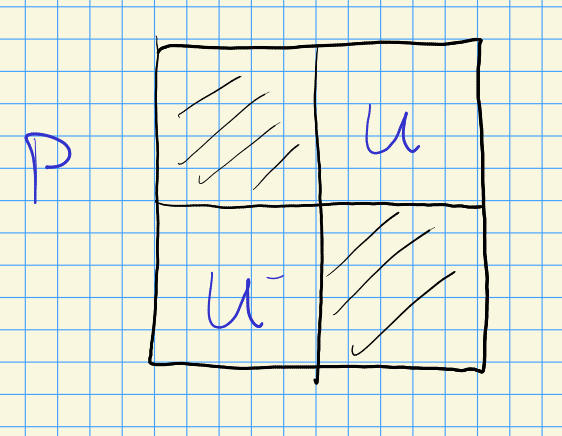

There is an embedding
$$\begin{align*}
U^- &\hookrightarrow G/P\\
u &\mapsto uP/P
.\end{align*}
For \(w\in W_Y'\), we have
\begin{align*}
\eta_w: {}^w U^- &\to G/P \\
wuw^{-1}&\mapsto wuP/P
,\end{align*}
and \({}^w U^- = wU^- w^{-1}\) for \(w\in W= N_G(T)/T\).$$

Let ${\mathbb{P}}^1 = G/P$ for $G= {\operatorname{SL}}_2$. Here $W = \left\{{e, s}\right\}\cong C_2$ and $S = \left\{{s}\right\} \supseteq Y$, and we want $Y = \emptyset$. Any $\lambda \in X^*(T)$ needs to be orthogonal to $\alpha {}^{ \vee }$. We can take a realization ${\operatorname{SL}}_2({\mathbb{C}}, \left\{{2}\right\}, \left\{{1}\right\})$ which yields $X^*(T) = {\mathbb{Z}}$. So ${\left\langle { \lambda},~{ \alpha {}^{ \vee }} \right\rangle} = 0 \iff 1\cdot \lambda \neq 0$, forcing $\lambda\neq 0$ for this to be a flag variety. For $\lambda = k$, we have $\lambda \cdot { \begin{bmatrix} {t} & {0} \\ {0} & {t^{-1}} \end{bmatrix} } = t^k$. We get a line bundle $G\overset{\scriptscriptstyle {B} }{\times} {\mathbb{C}}_{\lambda} \xrightarrow{\pi} G/B={\mathbb{P}}^1$, how does this compare to ${\mathcal{O}}_{{\mathbb{P}}^1}(k)$? The flag varieties look like the following:

[figure not shown]

Here $s, e$ are the two $T{\hbox{-}}$fixed points. We have $U_s \cap U_e \cong {\mathbb{C}}^{\times}$, and we’ll replace $U_s \to {}^s U^-$ and $U_e \to {}^{e}U^- = U^-$. The transition functions read:

[figure not shown]

> Link to Diagram

We have $U_s \cap U_e \cong {\mathbb{C}}^{\times}$, so what map ${\mathbb{C}}^{\times}{\circlearrowleft}$ do we get? Consider $U^-B/B \cap sU^-B/B$, so
$$\begin{align*}
u_{\alpha} (x) = {
\begin{bmatrix}
{1} & {x}
\\
{0} & {1}
\end{bmatrix}
} && u_{-\alpha}(x) = {
\begin{bmatrix}
{1} & {0}
\\
{x} & {1}
\end{bmatrix}
}
.\end{align*}
Then and \(u_{-\alpha}(x) = s u_\alpha(-x)s^{-1}\), so
\begin{align*}
u_{-\alpha}(x) B &= u_{- \alpha}(y) B \\
s u_{\alpha}(-x)s^{-1}B &= s u_{- \alpha}(y) B \\
u_{ \alpha}(-x) s^{-1}B &= u_{-\alpha} B
.\end{align*}$$

Now check that
$$\begin{align*}
{
\begin{bmatrix}
{1} & {-x}
\\
{0} & {1}
\end{bmatrix}
} {
\begin{bmatrix}
{0} & {-1}
\\
{1} & {0}
\end{bmatrix}
} = {
\begin{bmatrix}
{1} & {0}
\\
{y} & {1}
\end{bmatrix}
} {
\begin{bmatrix}
{a} & {b}
\\
{0} & {a^{-1}}
\end{bmatrix}
}&& \text{for some }{
\begin{bmatrix}
{a} & {b}
\\
{0} & {a^{-1}}
\end{bmatrix}
}\in B \\ \\
{
\begin{bmatrix}
{-x} & {-1}
\\
{1} & {0}
\end{bmatrix}
} = {
\begin{bmatrix}
{a} & {b}
\\
{ay} & {yb+a^{-1}}
\end{bmatrix}
}
,\end{align*}
so we have \(-x=y^{-1}\). Thus
\begin{align*}
T_{es}U_s^{\times}\times {\mathbb{C}}&\to U_e^{\times}\times {\mathbb{C}}\\
(x, z) &\mapsto (x^{-1}, x^{-k} z) \\ \\
T_{se}U_e^{\times}\times {\mathbb{C}}&\to U_s^{\times}\times {\mathbb{C}}\\
(x, z) &\mapsto (x^{-1}, x^{-k} z)
.\end{align*}$$

> These computations are hard, even in the case of ${\operatorname{SL}}_2$! Perhaps a motivation for having character formulas.

We then identify $G\overset{\scriptscriptstyle {B} }{\times} {\mathbb{C}}_{ \lambda} \xrightarrow{\pi} G/B$ with ${\mathcal{O}}(-k)$, and ${\mathcal{L}}( \lambda) = G\overset{\scriptscriptstyle {B} }{\times} {\mathbb{C}}_{\lambda}$.

# 17 Kumar Ch. 8: Demazure Character Formulas (Friday, October 01)

For any $\lambda \in D_Y^0$ define the algebraic line bundle ${\mathcal{L}}^Y(- \lambda)$ over $X^Y = {\mathcal{G}}/P_Y$ to be the following pullback:

[figure not shown]

> Link to Diagram

Let $H^Y = {\operatorname{Gr}}_k({\mathbb{C}}^n) = G/P^Y$ for $G\mathrel{\vcenter{:}}=\operatorname{GL}_n$.

Then define a vector bundle
$$\begin{align*}
{\mathcal{E}}\mathrel{\vcenter{:}}=\left\{{ (x, v) \in X^Y \times {\mathbb{C}}^n {~\mathrel{\Big\vert}~}v\in x}\right\} = \left\{{(E, v) \in {\operatorname{Gr}}_k({\mathbb{C}}^n) \times {\mathbb{C}}^n {~\mathrel{\Big\vert}~}v\in E}\right\}
,\end{align*}
and define \({\mathcal{E}}\xrightarrow{\pi} X^Y = {\operatorname{Gr}}_k({\mathbb{C}}^n)\) to be projection to the first factor such that$$

1. $\pi^{-1}(E) \cong E \in {\mathsf{{\mathbb{C}}}{\hbox{-}}\mathsf{Mod}}^{\dim = k}$ is a $k{\hbox{-}}$dimensional vector space for any $E\in X^Y$.
2. $\pi$ is $G{\hbox{-}}$equivariant: $\pi(g\cdot (x, v)) = g \cdot \pi(x, v)$, where the first action is $g\cdot (x, v) = (gx, gv)$, and $\pi(x, v) = gx$. Moreover $G$ acts on fibers linearly, so $g\cdot({-}): \pi^{-1}(x) \to \pi^{-1}(gx)$ which sends $E\to gE$ as subspaces in ${\mathbb{C}}^n$, and we require that this map of subspaces is a ${\mathbb{C}}{\hbox{-}}$linear map.

Equivariant bundles on homogeneous spaces are determined by the representation of the stabilizer on the corresponding fiber. We can pick a base point ${\operatorname{span}}_{\mathbb{C}}\left\{{e_1,\cdots, e_k}\right\} \cong {\mathbb{C}}^k \in {\operatorname{Gr}}_k({\mathbb{C}}^n)$, whence ${\operatorname{Stab}}_G({\mathbb{C}}^k) = P$ is all but the lower-left block:

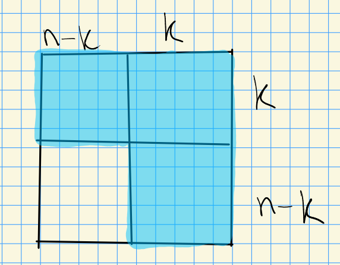

Then $\pi^{-1}({\mathbb{C}}^k) = {\mathbb{C}}^k$. We conclude
$$\begin{align*}
{\mathcal{E}}: G \overset{\scriptscriptstyle {P} }{\times} {\mathbb{C}}^k &\to G/P \\
[g, v] &\mapsto gv
.\end{align*}$$

For $k=1$, we’re considering ${\operatorname{Gr}}_1({\mathbb{C}}^n) = {\mathbb{P}}^{n-1}$.

- $T \subseteq \operatorname{GL}_n$ are diagonal matrices, and $t\curvearrowright{\left[ {x_1, 0, \cdots, 0} \right]} = {\left[ {tx_1, 0, \cdots, 0} \right]}$.
- $Y = \left\{{1\leq i \leq n-1 {~\mathrel{\Big\vert}~}{\left\langle {\lambda},~{\alpha_i {}^{ \vee }} \right\rangle} = 0}\right\} = \left\{{2, \cdots, n-1}\right\}$.
- Taking $\lambda = {\left[ {1, 0,\cdots, 0} \right]}$, we have a character
  $$\begin{align*}
  \lambda: T &\to {\mathbb{C}}^{\times}\\
  \operatorname{diag}(t_1,\cdots, t_n) &\mapsto t_1^1 t_2^0\cdots t_n^0
  .\end{align*}$$
- ${\mathcal{E}}= G\overset{\scriptscriptstyle {P} }{\times} {\mathbb{C}}^1 = G\overset{\scriptscriptstyle {P} }{\times} {\mathbb{C}}_{{\left[ {1, 0, \cdots, 0} \right]}} = {\mathcal{L}}(- \lambda)$.

Note that since this weight $\lambda$ is dominant (and not antidominant), there are no global sections.

Define
$$\begin{align*}
{\mathfrak{h}} {}^{ \vee }_{{\mathbb{Z}}, Y} \mathrel{\vcenter{:}}=\left\{{ \lambda\in {\mathfrak{h}} {}^{ \vee }_{\mathbb{Z}}{~\mathrel{\Big\vert}~}{\left\langle { \lambda},~{ \alpha_i {}^{ \vee }} \right\rangle} = 0, i\in Y}\right\}
.\end{align*}
For any \(\lambda\in {\mathfrak{h}} {}^{ \vee }_{\mathbb{Z}}\) take \(\lambda_1, \lambda_2 \in D_Y^0\) such that \(\lambda= \lambda_1 - \lambda_2\), i.e. we can write any weight as a difference of dominant weights:$$

[figure not shown]

Set
$$\begin{align*}
{\mathcal{L}}( \lambda) \mathrel{\vcenter{:}}=\mathcal{L} ^Y( - \lambda_2) \otimes{\mathcal{L}}( - \lambda_1) {}^{ \vee }
.\end{align*}
For example, given \(T \subseteq G\) and \(\lambda\in X(T)\), we have
\begin{align*}
\mathcal{L} (\lambda) = G\overset{\scriptscriptstyle {P} }{\times} {\mathbb{C}}_{ - \lambda}
.\end{align*}$$

Given $w\in W$, define
$$\begin{align*}
{\mathcal{L}}_w( \lambda) \mathrel{\vcenter{:}}= P_{i_1}\overset{\scriptscriptstyle {B} }{\times} P_{i_2} \overset{\scriptscriptstyle {B} }{\times} \cdots \overset{\scriptscriptstyle {B} }{\times} P_{i_n} \overset{\scriptscriptstyle {B} }{\times} {\mathbb{C}}_{ - \lambda}
.\end{align*}$$

Let

- ${w} = (s_{i_1}, \cdots, s_{i_n})$
- $i_{\lambda}: {\mathcal{G}}/P_Y \to {\mathbb{P}}(L^{\max} ( \lambda))$
- $m_w: Z_w \to {\mathcal{G}}/P_Y$

Then
$$\begin{align*}
{\mathcal{L}}_{w} (\lambda) = m_{w} {}^{ \vee }\mathcal{L} ^Y(\lambda)
.\end{align*}$$

Define
$$\begin{align*}
f: {\mathcal{L}}_{w}( \lambda) &\to Z_w
= P_{i_1}\overset{\scriptscriptstyle {B} }{\times} P_{i_2} \overset{\scriptscriptstyle {B} }{\times} \cdots \overset{\scriptscriptstyle {B} }{\times} P_{i_n} \overset{\scriptscriptstyle {B} }{\times} {\mathbb{C}}_{ - \lambda}
\\
[p_1,p_2, \cdots, p_n, z] &\mapsto [p_1, p_2, \cdots, p_n B/B] \\ \\
g: {\mathcal{L}}_{w}( \lambda) &\to {\mathcal{L}}^Y( \lambda) \\
[p_1,p_2, \cdots, p_n, z] &\mapsto [p_1 \cdot p_2 \cdots p_n, z]
.\end{align*}$$

Check that these maps are well-defined.

Using the universal property of pullbacks, we get a diagram:

[figure not shown]

> Link to Diagram

The claim is that $\phi$ is an isomorphism, we’ll show this by explicitly construction its inverse algebraic morphism. We have $\phi([p_1, \cdots, p_n, z]) = ( [p_1, \cdots, p_n B/B] \times [ p_1p_2\cdots p_n, z] )$. Define
$$\begin{align*}
\psi: m_w^* {\mathcal{L}}^Y( \lambda) &\to {\mathcal{L}}_w( \lambda) \\
[p_1, \cdots, p_nB/B] \times [g, z] &\mapsto [p_1, \cdots, p_n, p_n^{-1}\cdots p_1^{-1}gz]
,\end{align*}
where \(p_1^{-1}\cdots p_1^{-1}g\in P\). This will clearly be an inverse, it remains to show it’s well-defined. Note that
\begin{align*}
p_1\cdots p_n P/P = gP/P \implies f^{-1}p_1\cdots p_n \in P
,\end{align*}
which follows from chasing the fiber product diagram around the two sides.$$

Check that this is well-defined by showing a different representative has the same image. Then compose $\phi, \psi$ in both orders.

# 18 Cohomology of Certain Line Bundles $Z_w$ (Monday, October 04)

Some references:

- Fulton, *Intersection Theory*. Similar difficulty to Hartshorne if you’re going through it yourself!
  - See Young Tableaux books.
- Eisenbud-Harris, *3264 and All That*. A more Vakil-style approach.

The **Chow group** of $X\in{\mathsf{Var}}_{/ {k}}$ is the quotient $A_*(X) \mathrel{\vcenter{:}}= Z(X)/ \operatorname{Rat}(X)$, where $Z(X) = {\mathbb{Z}}[{\mathrm{Sub}}(X)]$, the free ${\mathbb{Z}}{\hbox{-}}$module on subvarieties of $X$. The group $Z(X)$ are **algebraic cycle**, and we mod out by rational equivalence.

If $G\curvearrowright X$, then $Y\sim gY\in A_*(X)$, and something similar happens for many algebraic group actions. Another example is that in ${\mathbb{P}}^1$, $x \sim x'$ for all points $x,x'$ since ${\operatorname{PSL}}_2\curvearrowright{\mathbb{P}}^1$.

Note that there is also an equivariant Chow group/ring. In general, $A_*(X)$ is difficult/impossible to compute (according to Harris) unless there is an affine stratification. In these cases, it coincides with Borel-Moore homology.

If $X$ is smooth, then $A^*(X)$ forms a ring, where the grading is given by codimension of subvarieties. Thus there is a multiplication $[A] \cdot [B] = [A \cap B]$ when $A\pitchfork B$ generically. Here transversality refers to an open condition on tangent spaces.

We have three ways of thinking about line bundles:

- Local trivializations
- Algebraic morphisms with 1-dimensional fibers
- Invertible sheaves

Now we’ll add a fourth in terms of divisors. Define:

- $A_{n-1}(X)\in {\mathsf{Grp}}$, **Weil divisors**
- ${\operatorname{Pic}}(X) \in {\mathsf{Grp}}$, the group of isomorphism classes of algebraic line bundles on $X$ where $[L_1] \cdot [L_2] \mathrel{\vcenter{:}}=[L_1 \oplus L_2]$.

Taking the Chern class yields a group morphism $c_1: {\operatorname{Pic}}(X) \to A_{n-1}(X)$. If the line bundle is generated by global sections, take the zero section of the global section. If $X$ is smooth, $c_1$ is an isomorphism, and we write $c_1({\mathcal{O}}_X(Y)) \mathrel{\vcenter{:}}=[Y]\in A_{n-1}(X)$. Note that this is slightly different to the ideal sheaf definition in Vakil.

See relation to Schubert varieties and Grassmannians in the referenced books. Bott-Samelson-Demazure and flag varieties will be smooth, although we’ll have to be careful for Schubert varieties.

Define the length of a word $w\in W$ to be the number of simple reflections, regardless of whether or not $w$ is reduced. Let $n\mathrel{\vcenter{:}}=\ell(w)$, then there is a formula for the canonical bundle $K_{Z_w}$ of any Bott-Samelson-Demazure variety $Z_w$ (even Kac-Moody types):
$$\begin{align*}
{\mathcal{L}}_w(-\rho) \otimes{\mathcal{O}}_{Z_w}( - \sum_{q=1}^n Z_{w(q)} )
.\end{align*}$$

Here $\rho\in {\mathfrak{h}} {}^{ \vee }_{\mathbb{Z}}$ (e.g. characters of the torus in the semisimple simply connected case) is any element satisfying $\rho( \alpha_i {}^{ \vee }) = 1$ for all $1\leq i \leq \ell$. Recall that
$$\begin{align*}
Z_w = P_{i_1}\overset{\scriptscriptstyle {B} }{\times} \cdots \overset{\scriptscriptstyle {B} }{\times} P_{i_n} / B = \left\{{ {\left[ {p_1, \cdots, p_n B/B } \right]}}\right\}
,\end{align*}
and \(Z_w(q)\) means deleting the \(q\)th factor, so \(Z_w(q) = \left\{{{\left[ {p_1,\cdots, 1,\cdots, p_nB/B} \right]}}\right\}\) has the \(q\)th coordinate set to 1. Note that there is a quotient map \(Z_w \to Z_{w(n)}\), which has a section, and we can use this to induct.$$

Consider $G$ connected and reductive and let $X=G/B$ be the flag variety, which is smooth. Then for $\lambda \in X(T)$ corresponds to the algebraic line bundle ${\mathcal{L}}^{\emptyset}( \lambda) = G\overset{\scriptscriptstyle {B} }{\times} {\mathbb{C}}_{ - \lambda}$. This yields a function $X(T) \to {\operatorname{Pic}}(X) \xrightarrow{c_1} A_{n-1}(X)$ given by forgetting the $G{\hbox{-}}$action. This is a group morphism, where adding characters maps to tensoring bundles.

Note that for $T = {\mathbb{C}}^{\times}$, we have
$$\begin{align*}
X(T) = \mathop{\mathrm{Hom}}_{{\mathsf{Alg}}{\mathsf{Grp}}}({\mathbb{C}}^{\times}, {\mathbb{C}}^{\times})= \left\{{z \mapsto z^k {~\mathrel{\Big\vert}~}k\in {\mathbb{Z}}}\right\} { { \, \xrightarrow{\sim}\, }}_{{\mathsf{Ab}}{\mathsf{Grp}}} {\mathbb{Z}}
,\end{align*}
where negatives are permitted since \(0\not\in {\mathbb{C}}^{\times}\). More generally, \(X(T) { { \, \xrightarrow{\sim}\, }}_{{\mathsf{Ab}}{\mathsf{Grp}}} {\mathbb{Z}}^n\) for \(n=\operatorname{rank}T\), where \({\left[ {{ {t}_1, {t}_2, \cdots, {t}_{n}}} \right]} \xrightarrow{\lambda} \lambda_1^{k_1}\cdots \lambda_n^{k_n}\). Since we have an affine stratification by Schubert cells, we can write \(A_*(X) = \bigoplus_{w\in W} [X_w]\), and in fact \(A_k(X) = \bigoplus _{\ell(w) = k} [X_w]\). Considering the lattice for \(W\), there are \(\ell\) dimension 1 Schubert cells, and identifying them as CW cells and applying Poincare duality, there are \(\ell\) codimension 1 cells:$$

[figure not shown]

> Link to Diagram

It turns out that the map is given as follows:
$$\begin{align*}
{\mathbb{Z}}^n \cong X(T) &\longrightarrow A_{n-1}(X) \cong {\mathbb{Z}}^\ell \\
\lambda&\mapsto \sum_{i=1}^\ell {\left\langle {\lambda},~{ \alpha_i {}^{ \vee }} \right\rangle}[X_{w_0 s_i}] && n\geq \ell
.\end{align*}$$

For $G = {\operatorname{SL}}_2, {\mathcal{L}}( \lambda_k) = {\mathcal{O}}_{{\mathbb{P}}^1}(k)$ and $X(T) \cong {\mathbb{Z}}$. Recall that ${{\Gamma}\qty{{\mathbb{P}}^1, {\mathcal{O}}_{{\mathbb{P}}^1}(k)} } = {\mathbb{C}}[x, y]_k$ are homogeneous polynomials of degree $k$ when $k\geq 0$, otherwise there are no global sections. For example, ${\mathbb{C}}[x, y]_2 = \left\langle{x^2, xy, y^2}\right\rangle$ is dimension $3 = 2 + 1$. All points are rationally equivalent, so we can take the basepoint $B/B$, and so the map will need to track the multiplicity of points. The composition is given by the following:

[figure not shown]

> Link to Diagram

The cotangent bundle of $X$ is given by $G\overset{\scriptscriptstyle {P} }{\times} u = T {}^{ \vee }G/P$ where $P = LU$. The canonical bundle is the top wedge power, and here we get $G\overset{\scriptscriptstyle {B} }{\times} {\mathfrak{n}}= G\overset{\scriptscriptstyle {B} }{\times} {\mathbb{C}}_2 = {\mathcal{L}}(-2)$, noting that the canonical is equal to the cotangent bundle here, and we’ve identified which equivariant bundle this is.

# 19 Friday, October 08

Continuing some stuff from Kumar Ch. 8: the goal is to understand the Demazure and Weyl-Kac character formulas. Open question: how can one compute the singular locus of a given Schubert variety? This is surprisingly a hot topic this semester, c/o multiple Arxiv papers that have come out over the past few months.

Our first goal: showing $X_w^Y$ is normal. Note that most varieties in representation theory are not normal, and this complicates things significantly, so normality is a great condition here.

Recall that for $X\in {\mathsf{Var}}$, the stalks ${\mathcal{O}}_{X, x}$ are local rings, and the **cotangent space at $x$** is defined as ${\mathfrak{m}}_x/{\mathfrak{m}}_x^2$.

> Cohomology vanishing: some of the hardest and most important results in this area!

Let $w = (s_{i_1} \cdots, s_{i_n}) \in W$ be a word and consider $j, k$ such that $1\leq j\leq k\leq n$. Suppose that the subword $v = (s_{i_j} \cdots, s_{i_k})$ is reduced. Considering the associated BSDH-varieties, we have a subvariety
$$\begin{align*}
Z_v \mathrel{\vcenter{:}}= P_{i_j}\overset{\scriptscriptstyle {B} }{\times} \cdots P_{i_k}/B \hookrightarrow
Z_w \mathrel{\vcenter{:}}= P_{i_1}\overset{\scriptscriptstyle {B} }{\times} \cdots P_{i_n}/B
.\end{align*}
Recall that \({\mathcal{L}}^Y(\lambda) \mathrel{\vcenter{:}}= G\overset{\scriptscriptstyle {P_Y} }{\times} {\mathbb{C}}_{- \lambda}\), and
\begin{align*}
{\mathcal{L}}_w( \lambda) \mathrel{\vcenter{:}}= P_{i_1}\overset{\scriptscriptstyle {B} }{\times} \cdots \overset{\scriptscriptstyle {B} }{\times} P_{i_n} {\mathbb{C}}_{- \lambda} = f^* {\mathcal{L}}^Y( \lambda)
,\end{align*}
and we write \(w(n)\) for \(w\) with the \(n\)th letter omitted. Moreover codimension 1 subvarieties correspond to line bundles under the Chern class isomorphism. Then for any integral dominant \(\lambda \in D_{\mathbb{Z}}\), there are 3 vanishing formulas:$$

1. $$\begin{align*}
   H^{\geq 1 } \qty{ Z_w; {\mathcal{L}}_w( \lambda) \otimes{\mathcal{O}}_{Z_w}(- \sum_{q=0}^k Z_{w(q)} ) } &= 0
   .\end{align*}$$
2. $$\begin{align*}
   H^{\geq 1} \qty{Z_w; {\mathcal{L}}_w( \lambda) } &= 0
   .\end{align*}$$
3. If $k<n$ and $v' \mathrel{\vcenter{:}}=(s_{i_k} \cdots, s_{i_k} s_{i_{k+1}})$ is *not* reduced, then

$$\begin{align*}
H^{\geq 0 } \qty{ Z_w; {\mathcal{L}}_w( \lambda) \otimes{\mathcal{O}}_{Z_v}(- \sum_{q=j}^k Z_{w(q)} ) } &= 0 \\
.\end{align*}$$

We’ll often use **Serre duality** in the following form: given a set of nice assumptions, there is a perfect pairing
$$\begin{align*}
H^i(X; {\mathcal{F}}) \times H^{n-i}(X; K_X \otimes{\mathcal{F}} {}^{ \vee }) \to {\mathbb{C}}
,\end{align*}
where \({\mathcal{F}} {}^{ \vee }\mathrel{\vcenter{:}}=\mathop{\mathrm{Hom}}_{{\mathcal{O}}_X}({\mathcal{F}}, {\mathcal{O}}_X)\) and \(K_X\) is the dualizing sheaf. Note that if \(X\) is smooth and projective, one can take \(K_X\) to be the canonical sheaf.$$

For any finite-dimensional representation $M$ of $B{ {}^{ \scriptscriptstyle\times^{n} } }$, there is a functorial assignment a $P_{i_1}{\hbox{-}}$equivariant algebraic vector bundle ${\mathcal{L}}_w(M) \to Z_w$ on the BSDH variety. which is an exact functor on ${\mathsf{B{ {}^{ \scriptscriptstyle\times^{n} } }}{\hbox{-}}\mathsf{Mod}}^{\dim < \infty}$, given by
$$\begin{align*}
{\mathcal{L}}_w( - \lambda ) = {\mathcal{L}}_w( {\mathbb{C}}_{ \lambda})
.\end{align*}
This is induced by \(B{ {}^{ \scriptscriptstyle\times^{n} } } \xrightarrow{{\operatorname{pr}}_n} B \to {\mathbb{C}}_{\lambda}\).$$

Using this formula,
$$\begin{align*}
{\mathcal{L}}(\lambda) {}^{ \vee }= {\mathcal{L}}( {\mathbb{C}}_{- \lambda}) {}^{ \vee }= {\mathcal{L}}({\mathbb{C}}_{- \lambda} {}^{ \vee })
,\end{align*}
where given \(V_{ \lambda}\) a highest weight representation of \(G\) (connected reductive finite type), we have \(V_{ \lambda} {}^{ \vee }= V_{-w_0 \lambda}\). Here \({\mathbb{C}}_{ - \lambda}\) is a representation of the torus, for which \(w_0 = \operatorname{id}\).$$

For $w = v = (s)$ and $1\leq j\leq k \leq n =1$, we have $Z_{(s)} = P_s/B \cong {\mathbb{P}}^1$. Noting $Z_{ \emptyset} = B/B = {\operatorname{pt}}$, using the formula we obtain
$$\begin{align*}
H^p( P_s/B; {\mathcal{L}}_{(s)} ( \lambda) \otimes{\mathcal{O}}_{Z_{(s)}} (-B/B) )
.\end{align*}
This is an (equivariant) line bundle on \({\mathbb{P}}^1\), which are all of the form \({\mathcal{O}}(n)\) – which one is it? Write \(a \mathrel{\vcenter{:}}={\left\langle { \lambda},~{ \alpha {}^{ \vee }} \right\rangle} \in {\mathbb{Z}}_{\geq 0}\) since \(\lambda\) was dominant integral. Forgetting the group action yields an algebraic bundle which we can write as
\begin{align*}
H^p(P_s/B ; {\mathcal{O}}_{{\mathbb{P}}^1}(a) \otimes{\mathcal{O}}_{{\mathbb{P}}^1}(-1) )
.\end{align*}$$

This can also be described by tensoring ${\mathbb{C}}_{ \lambda} \otimes{\mathbb{C}}_{ \mu} \cong {\mathbb{C}}_{ \lambda+ \mu}$. Finally, we can identify this homology with
$$\begin{align*}
H^p(P_s/B ; {\mathcal{O}}_{{\mathbb{P}}^1}(a-1) )
.\end{align*}$$

Note that the canonical for ${\mathbb{P}}^1$ is $G\overset{\scriptscriptstyle {B} }{\times} {\mathbb{C}}_{2} = {\mathcal{L}}(-2) = {\mathcal{O}}(-2)$ (noting that $-n$ has no global sections). So if ${\mathcal{F}}= {\mathcal{O}}(k)$ then ${\mathcal{F}} {}^{ \vee }= {\mathcal{O}}(-k)$. Applying Serre duality yields
$$\begin{align*}
H^i( {\mathbb{P}}^1; {\mathcal{O}}(k) ) \times H^{n-i}({\mathbb{P}}^1; {\mathcal{O}}(-2) \otimes{\mathcal{O}}(-k) ) \to {\mathbb{C}}
.\end{align*}$$

Note that $H^0({\mathbb{P}}^1; {\mathcal{O}}(k)) = 0$ for $k<0$, since these look like homogeneous polynomials in degree $k$ (and there are none of negative degree), so taking $k=-1$ we have $H^0({\mathbb{P}}^1; {\mathcal{O}}(-1)) = 0$. By duality, this pairs with $H^1({\mathbb{P}}^1; {\mathcal{O}}(-1))$, and continuing yields a pairing:

[figure not shown]

Let $w=(s, s), v=(s), v'=(s), \eta = \emptyset, \mu = \emptyset$. Write $\sigma = \psi: Z_w \to Z_v$, which is projection onto the first coordinates in the corresponding BSDH varieties:
$$\begin{align*}
P_s \overset{\scriptscriptstyle {B} }{\times} P_s/B &\to P_s/B \\
[p_1, p_2B/B] &\mapsto [p_1 B/B]
.\end{align*}
Note that
\begin{align*}
{\mathcal{O}}_{Z_w}( -B\overset{\scriptscriptstyle {B} }{\times} P_s /B) = \sigma^* ( {\mathcal{O}}_{Z_v}(-B/B) )
.\end{align*}
There are 3 important facts we’ll revisit:$$

1. A projection formula,
2. Lemma 8.1.5,
3. The Leray spectral sequence.

# 20 Monday, October 11

Chapter 8: actually equivariant ${\mathsf{K}}{\hbox{-}}$theory without saying so! Also deals with Demazure operators. Goal: show that $X^Y_w$ is normal.

Let $X\in {\mathsf{Var}}_{/ {k}}$ be irreducible, then $X$ is **normal** at $x\in X$ iff ${\mathfrak{m}}_x \mathrel{\vcenter{:}}={\mathcal{O}}_{X, x}$ is integrally closed in its field of fractions $\operatorname{ff}({\mathfrak{m}}_x)$.

Note that there are implications smooth $\implies$ factorial $\implies$ normal in ${\mathsf{Var}}_{/ {k}}$. We write $\Sigma(X) \subseteq X$ to be the singular locus, and if $X$ is normal then $\operatorname{codim}_X \Sigma(X) \leq 2$.

Let $f(x,y,z) = x^2-zy^2$ and consider $X \mathrel{\vcenter{:}}= V(f) \subseteq {\mathbb{A}}^3_{/ {{\mathbb{C}}}} \in {\mathsf{Aff}}{\mathsf{Var}}_{/ {{\mathbb{C}}}}$. Checking normality for affine varieties just amounts to checking on regular functions, so $X$ is normal iff ${\mathbb{C}}[X] \hookrightarrow{\mathbb{C}}(X)$ is integrally closed. One direction involves checking that localizations are integrally closed, which is an easy exercise in commutative algebra, while the other direction is harder. Consider $X({\mathbb{R}})$:

[figure not shown]

The claim is that $X$ is not normal. Setting $\xi = x/y$ is not a regular function on $X$ since $y$ vanishes at some points of $X$, but $\xi^2 = x^2/y^2 = z \in {\mathbb{C}}[X]$ is regular.

Motivating question: normality is a local condition, so where can $X$ be non-normal? There is a process of **normalization** which associates to $X$ a unique normal variety $\tilde X$ with a unique finite birational morphism $\nu: \tilde X\to X$. Here *finite* means points have finite fibers and the map is proper.

Some properties: - $\nu$ is unique.

- $\tilde X \xrightarrow{\nu} X$ satisfies a universal property: For $X\to Y$ for any $Y$ normal, then there exists a unique lift

[figure not shown]

> [Link to Diagram](https://q.uiver.app/?q=WzAsMyxbMCwyLCJYIl0sWzIsMiwiWSJdLFswLDAsIlxcdGlsZGUgWCJdLFswLDEsImYiXSxbMCwyLCJcXG51Il0sWzIsMSwiXFxleGlzdHMgISBcXHRpbGRlIGYiLDAseyJzdHlsZSI6eyJib2R5Ijp7Im5hbWUiOiJkb3R0ZWQifX19XV0=)

> See also **Stein factorization** for proper morphisms.
- If $f:X\to Y$ is a birational projective morphism between irreducible varieties and $Y$ is normal, then $f_* {\mathcal{O}}_X = {\mathcal{O}}_Y$.

  > See also **Zariski’s main theorem**.

Let $X$ be the umbrella from above. Consider $\nu(u, v) = {\left[ {uv, v, v^2} \right]}$, so ${\mathbb{A}}^2_{/ {{\mathbb{C}}}} \xrightarrow{\nu} X \subseteq {\mathbb{A}}^3_{/ {{\mathbb{C}}}}$, and let $f(x,y,z) = x^2 - zy^2$, so $f(uv, v, v^w) = (uv)^2 - u^2v^2 = 0$ is a regular function on $X$. One can check that $\Im(\nu) \subseteq X$ so this is surjective, and the conclusion is that $X$ is irreducible with 2-dimensional fibers. Consider the fibers of $\nu$:

1. $\mathbf{x} = 0$ yields $\nu^{-1}(\mathbf{x}) = \left\{{ {\left[ {u, v} \right]} \in {\mathbb{A}}^2 {~\mathrel{\Big\vert}~}{\left[ {uv, v, u^2} \right]} = \mathbf{0}}\right\} = {\operatorname{pt}}$.
2. $\mathbf{x} = {\left[ {0,0, z} \right]}$ with $z\neq 0$ yields $\nu^{-1}(\mathbf{x}) = \left\{{{\left[ {uv, v, u^2} \right]} = {\left[ {0,0,z} \right]}}\right\} = \left\{{p_1, p_2}\right\}$ which have nonzero 2nd coordinates, by choosing a square root of $u$.
3. $\mathbf{x} = {\left[ {x,y,z} \right]}$ with $x\neq 0$ yields $\nu^{-1}(\mathbf{x}) = \left\{{{\left[ {uv, v, u^2} \right]} = {\left[ {x,y,z} \right]}}\right\}$. This forces $v=y$, and $x = uv= uy$ which is nonzero and can be solved for $u$, so we again get a single point $\nu^{-1}(\mathbf{x}) = {\operatorname{pt}}$.

Moral: we can study singularities by looking at fibers.

Next time: Schubert varieties.

# 21 Wednesday, October 13

Goal: show Schubert varieties are normal.

Let $v\leq w\in W$, $\lambda \in D_{\mathbb{Z}}\cap{\mathfrak{h}} {}^{ \vee }_{{\mathbb{Z}}, Y}$ where we take the extension $P_Y \xrightarrow{\lambda} {\mathbb{C}}^{\times}$ to the parabolic. Then part (b) of the theorem states that $X_W^Y$ is normal.

Let $w\in W_Y'$ such that $w'$ is a minimal length representative in $w W_Y$. Write $\pi(w') = w$ for the element obtained by multiplying the elements in the word $w'$, and choose a word $\mathcal{w} \in \mathcal{W}$ such that $\pi \mathcal{w}' = w'$. Then $m_{{\mathcal{W}}}^Y: Z_{{\mathcal{W}}'} \to X_{w'}^Y$ is surjective and birational, and so the following induced hom is an isomorphism
$$\begin{align*}
(m_{{\mathcal{W}}}^Y)^*: H^0(X_W^Y, {\mathcal{L}}_w^Y( \lambda)) { { \, \xrightarrow{\sim}\, }}H^0(Z_{w'}, {\mathcal{L}}_{w'} ( \lambda))
.\end{align*}
Taking any \(\lambda^0 \in D^0_Y\) and applying A.32 (a deep AG fact) to the ample line bundle \({\mathcal{L}}= {\mathcal{L}}_W^Y(\lambda_0)\), we get the following important formula:$$

$$\begin{align*}
(m_{w'}^Y)_* {\mathcal{O}}_{Z_{w'}} = {\mathcal{O}}_{X_W^Y}
.\end{align*}
This is what Kumar spends most of the time showing, and is essentially equivalent to the following:$$

Let $f:X\to Y$ be birational and proper such that $X$ is normal. Then $Y$ is normal iff $f_* {\mathcal{O}}_X = {\mathcal{O}}_Y$, which implies that the fibers are connected. This is proved in Hartshorne.

> Vogan: there are more statements in representation theory that say “**if** normal” than there are that say “**then** normal.”

Recall that the normalization $\tilde Y \xrightarrow{\nu} Y$ satisfies a universal property with respect to maps from normal varieties. Using functoriality, we have
$$\begin{align*}
f_* {\mathcal{O}}_X
&= (\nu \circ \tilde f)_* {\mathcal{O}}_X \\
&= \nu_* (\tilde f_* {\mathcal{O}}_X) \\
&= \nu_* {\mathcal{O}}_{\tilde Y} &&\text{Zariski's Main Theorem, forward direction}\\
&= {\mathcal{O}}_Y &&\text{by assumption}
.\end{align*}
Use that \(\tilde f\) is birational and proper, where properness can be shown by exhibiting it as the pullback of a proper morphism. Using that \(Y\) is normal iff every open affine \(U \subseteq Y\) is normal, we have
\begin{align*}
{\mathcal{O}}_Y(U) = (\nu_* {\mathcal{O}}_{\tilde Y})(U) = {\mathcal{O}}_{\tilde Y}(\nu^{-1}(U))
.\end{align*}$$

## 21.1 Borel-Weil Homomorphism

For any $V\in {\mathsf{{\mathbb{C}}}{\hbox{-}}\mathsf{Mod}}$ with $\dim_{\mathbb{C}}\leq \infty$, define a morphism
$$\begin{align*}
\beta_V: V {}^{ \vee }&\to H^0( {\mathbb{P}}V, {\mathcal{L}}_V {}^{ \vee }) \\
f &\mapsto (\delta \mapsto (\delta, { \left.{{f}} \right|_{{\delta }} }))
,\end{align*}
where taking the dual of the tautological amounts to, for each line \(\delta \in {\mathbb{P}}V\), quotienting by the annihilator to get \(V {}^{ \vee }/ \delta^\perp\). Note that there is a projection \(\pi: {\mathcal{L}}_V {}^{ \vee }\to {\mathbb{P}}V\).$$

How does this relate to representation theory? Let $V$ be an irreducible integrable ${\mathfrak{g}}{\hbox{-}}$module with highest weight $\lambda$, then every $w\in W$ induces $V_w$, and $U({\mathfrak{b}}){\hbox{-}}$submodule generated by extremely weight vectors $w_{w \lambda}$. Then $\beta$ acts by pushing weights “up,” and so e.g. if one has weights $\lambda, w_1 \lambda, w_2 \lambda, \cdots$ one can consider the **Demazure submodule** generated by any given $w_i \lambda$. Often we set $V = L^{\max}(\lambda)$, and so
$$\begin{align*}
(L^{\max} (\lambda))_w = L_w^{\max}( \lambda)
.\end{align*}$$

Going back to part (a) of the theorem, we have isomorphisms:

$$\begin{align*}
\mkern 1.5mu\overline{\mkern-1.5mu\beta\mkern-1.5mu}\mkern 1.5mu_w^Y: L_w^{\max}( \lambda) {}^{ \vee }&{ { \, \xrightarrow{\sim}\, }}H^0( X_w^Y; {\mathcal{L}}_w^Y(\lambda)) \\
\alpha {}^{ \vee }: H^0( X_w^Y; {\mathcal{L}}_w^Y( \lambda)) &{ { \, \xrightarrow{\sim}\, }}H^0(X_w, {\mathcal{L}}_w( \lambda))
.\end{align*}
We have the following geometric picture:$$

[figure not shown]

> Link to Diagram

The connection between representation theory and geometry is th following:
$$\begin{align*}
H^0(Z_\infty; {\mathcal{L}}_\infty ( \lambda ) ) { { \, \xrightarrow{\sim}\, }}L^{\max}( \lambda) {}^{ \vee }
.\end{align*}$$

These statements are easy to remember and use but hard to prove! So we’ll move on and look at the Demazure character formula.

# 22 Ch.8 Continued (Monday, October 18)

Today: looking at more examples of Schubert varieties in detail, e.g. ${\mathsf{Sp}}_{2n}$. One can take $G' \mathrel{\vcenter{:}}=\operatorname{GL}_{2n}$ and define involutions $G' \xrightarrow{\Theta} G'$. One example is $g\mapsto g^{-t}$, whose fixed points are ${\operatorname{O}}_{2n}$, and it’s easy to check that this is an involution:
$$\begin{align*}
(\Theta')^2(g) = \Theta' ({}^t g^{-1}) = {}^t( {}^t g^{-1})^{-1}= {}^t ({}^t g) = g
.\end{align*}
For \({\mathsf{Sp}}_{2n}\), taking
\begin{align*}
\theta(g) = -J^t g J
\end{align*}
where \(J\) is the matrix
\begin{align*}
\begin{bmatrix}
& & & & & & 1 \\
& & & & & \cdots & \\
& & & & 1 & & \\
& & & -+- & & & \\
& & -1 & & & & \\
& \cdots & & & & & \\
-1 & & & & & &
\end{bmatrix}
.\end{align*}$$

We can check that this is an involution:
$$\begin{align*}
\Theta^2(g)
&= \Theta(-J^t g J) \\
&= -J^t(-J^t g J)^{-1}J \\
&= J(Jg^{-t} J)^{-1}J \\
&= JJ g JJ \\
&= g
.\end{align*}$$

$(G')^\Theta \mathrel{\vcenter{:}}=\left\{{g'\in G'{~\mathrel{\Big\vert}~}\Theta(g') = g'}\right\}$ are the fixed points under the involution $\Theta$.

One can write
$$\begin{align*}
(G')^\Theta = \left\{{g\in G' {~\mathrel{\Big\vert}~}\omega(g' x, g' y) = \omega(x, y)}\right\}
.\end{align*}
for \(\omega\) the associated bilinear form \(\omega(x, y) = { {}^t{x}} J y\). Note that \(g'x, g'y\) should be column vectors here.$$

Write the RHS set as $\left\{{g\in G {~\mathrel{\Big\vert}~}{ {}^t{g'}} J g' = J}\right\}$. Then check that if $\theta(g) = g$ for some $g\in G'$,
$$\begin{align*}
\omega(gx, gy)
&= { {}^t{(gx)}} J (gy) \\
&= { {}^t{(x^{-1})}} g J gy \\
&= { {}^t{(x^{-1})}} g J \Theta(g) y \\
&= { {}^t{(x^{-1})}} g J (-J { {}^t{g^{-1}}} J ) y \\
&= { {}^t{x}} Jy
.\end{align*}
So these two act the same on all elements \(x, y\), and thus have the same matrix, yielding \(\subseteq\). For the reverse containment, if \(\omega(gx, gy) = \omega(x, y)\), then
\begin{align*}
{ {}^t{g}} J g &= J \\
\implies Jg &= { {}^t{g^{-1}}} J \\
\implies \Theta(g) &= -J { {}^t{g^{-1}}} J \\
&= -JJ g \\
&= g
.\end{align*}$$

We can realize ${\mathsf{Sp}}_{2n}$ as $(G')^{\Theta}$.

How do we get a Borel? It is a general fact that these can be obtained by intersecting with Borels in the ambient group, so take $B' \cap{\mathsf{Sp}}_{2n}$ for $B' \subseteq G'$ upper triangular. Then $B'$ is $\Theta{\hbox{-}}$stable:

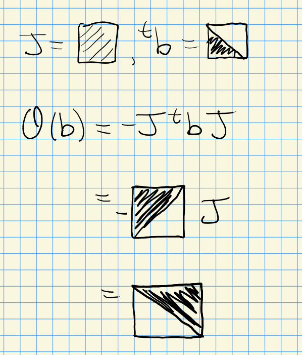

Let $G = (G')^\Theta$, then $G\curvearrowright G'/B'$ with finitely many orbits. So we get closure relations:

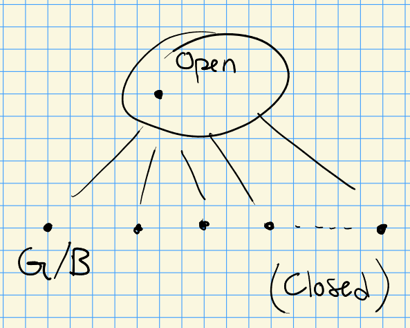

One can also fix $T' \subseteq G'$ as a maximal torus of diagonal matrices, and this is also $\Theta{\hbox{-}}$stable. Then $T' \cap G$ is of the following form:

$$\begin{align*}
\begin{bmatrix}
t_1 & & & & & \\
& \ddots & & & & \\
& & t_n & & & \\
& & & t_n^{-1}& & \\
& & & & \ddots & \\
& & & & & t_1^{-1}
\end{bmatrix}
\cong ({\mathbb{C}}^{\times}){ {}^{ \scriptscriptstyle\times^{n} } }
.\end{align*}$$

Writing $G'/B' = \left\{{ F^\bullet \text{ complete flags}}\right\} = G' \cdot {\mathbb{C}}^\bullet$ for the standard flag ${\mathbb{C}}^\bullet \mathrel{\vcenter{:}}=(0 \subseteq {\mathbb{C}}^1 \subseteq {\mathbb{C}}^2 \subseteq \cdots \subseteq {\mathbb{C}}^{2n})$. We can write this set as $\left\{{F^\bullet {~\mathrel{\Big\vert}~}(F^k)^\perp = F^{2n+1-k}}\right\}$, where $(F^k)^\perp \mathrel{\vcenter{:}}=\left\{{ x\in {\mathbb{C}}^{2n} {~\mathrel{\Big\vert}~}\omega(x, y) = 0 \,\,\forall y\in F^k}\right\}$. Generally the former will be flags ${\mathbb{C}}^{2n} =F^{2n} \to F^{2n-1} \to \cdots \to F^1\to 0$, and this says we can describe this more compactly as flags ${\mathbb{C}}^{2n} \to F^n \to F^{n-1} \to \cdots \to F^1\to 0$ where the $F^k$ are isotropic, by inserting their orthogonal complements into the chain appropriately.

What are the Schubert varieties in $G/B$?

This produces a large collection of normal varieties: start with flags and add conditions.

# 23 Wednesday, October 20

Last time: Schubert varieties for $G \leq G'$ for $G \mathrel{\vcenter{:}}={\mathsf{Sp}}_{2n}$ and $G' \mathrel{\vcenter{:}}=\operatorname{GL}_{2n}$. There are Weyl groups $W \leq W'$ where here $W' = S_{2n}$ and $W = \left\{{w\in S_{2n} {~\mathrel{\Big\vert}~}w(k) + w(2n+1-k) = 2n+1-k }\right\}$. For ${\mathsf{Sp}}_2 \leq \operatorname{GL}_4$, e.g. we can take $w = (1,3 \mathrel{\Big|}2, 4)$ and $X_W = \left\{{F^\bullet \in G'/B' {~\mathrel{\Big\vert}~}{\mathbb{C}}^4\to {\mathbb{C}}^3 \to F^2\to {\mathbb{C}}^1 \to 0}\right\} \cong {\mathbb{P}}^1$.

For $G' = \operatorname{GL}_4$, we can produce a singular Schubert variety. Take $G/P$ for $P = P_Y$ where $Y = \left\{{1, 3}\right\}$, so $G/P = {\operatorname{Gr}}_2({\mathbb{C}}^4)$. Take the following Young diagram:

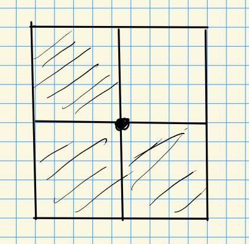

So $X_\lambda^Y = \left\{{E^2 \in {\operatorname{Gr}}_2({\mathbb{C}}^4) {~\mathrel{\Big\vert}~}\dim ({\mathbb{C}}^2 \cap E^2) \geq 1}\right\}$, and $X_W = \pi^{-1}(X_\lambda^Y)$. The minimal length permutation is $w' = (2,4 \mathrel{\Big|}1,3)$ (obtained from the Young diagram above) and the maximal is $w=(4,2 \mathrel{\Big|}3, 1)$. Note this satisfies $w(k) + 2(2n +1) = 2n + 1$ for $n=2$ since $4+1 = 2+3 = 5$, so $w\in W = W({\mathsf{Sp}}_4)$.

For this $Y$, we have a map
$$\begin{align*}
\pi: G/B &\to G/P \\
F^\bullet &\mapsto F^2
,\end{align*}
where the full preimage is \(\pi^{-1}(P/P) = P/B\). Writing \(X_W' = \left\{{F^\bullet \in G'/B' {~\mathrel{\Big\vert}~}\dim({\mathbb{C}}^2 \cap F^2) \geq 1 }\right\} \subseteq G'/B'\), we can realize
\begin{align*}
X_W = \left\{{ F^\bullet \in G/B {~\mathrel{\Big\vert}~}\dim({\mathbb{C}}^2 \cap F^2) \geq 1, (F^1)^\perp = F^3, (F^2)^\perp = F^2}\right\}
.\end{align*}$$

For $G = {\mathsf{Sp}}_4$, $S = \left\{{1, 2}\right\}$, $Y = \left\{{1}\right\}$, and $G/P_Y = \left\{{{\mathbb{C}}^4 \to F^2 \to 0 {~\mathrel{\Big\vert}~}F^2 = (F^2)^\perp}\right\}$ since the $1\in Y$ implies omitting $F^1$, and we also omit $(F^1)^\perp = F^3$. This yields the **Lagrangian flag variety**.

Let $s_1 = (2,1,4,3)$ and $s_2 = (1,3,2,4)$, then $ws_1 = (4,2,3,1)(2,1,3,4) = (2,4,1,3)$ and notably $\ell(2,4,1,3) < \ell(4,2,3,1)$ and the length has strictly decreased. So $w$ is maximal length in $wW_Y$.

We can conclude $X_w^Y = \left\{{F^2 \in {\mathcal{L}}\mathrel{\vcenter{:}}={\operatorname{Gr}}^0_2({\mathbb{C}}^4) {~\mathrel{\Big\vert}~}\dim({\mathbb{C}}^2 \cap F^2) \geq 1 }\right\}$ where ${\operatorname{Gr}}^0$ denotes isotropic subspaces. So this yields a normal but not smooth variety.

## 23.1 Statements in Equivariant ${\mathsf{K}}{\hbox{-}}$theory

> See Chris-Ginzburg

On flat pullback: for $f:X\to Y$ a $G{\hbox{-}}$equivariant morphism of $G{\hbox{-}}$spaces, if $f$ is flat (so tensor-exact) then there is a morphism of $G{\hbox{-}}$equivariant ${\mathsf{K}}{\hbox{-}}$theories:
$$\begin{align*}
f^*: K_i^G(Y) \to K_i^G(X)
\end{align*}
induced by an exact pullback functor
\begin{align*}
f^*: {\mathsf{Coh}}^G(Y) & \to {\mathsf{Coh}}^G(X) \\
{\mathcal{F}}&\mapsto f^* {\mathcal{F}}= {\mathcal{O}}_{X} \otimes_{f^{-1}{\mathcal{O}}_Y} f^{-1}{\mathcal{F}}
.\end{align*}$$

Flat implies sameness among fibers in a bundle.

## 23.2 Flat Pullback

### 23.2.1 Equivariant Descent

A principal $G{\hbox{-}}$bundle can mean several things. The difference between local triviality in the Zariski vs étale topology[^3] Then $\pi:P\to X \in \mathop{\mathrm{Prin}}{ {\mathsf{Bun}}\qty{G} }$, since étale implies flat there is an equivalence of categories ${\mathsf{Coh}}(X) { { \, \xrightarrow{\sim}\, }}{\mathsf{Coh}}^G(P)$. Thus there is an isomorphism $\pi^*: K(X) { { \, \xrightarrow{\sim}\, }}K^G(P)$.

### 23.2.2 Restriction/Induction

For $H \leq G$ a closed subgroup and $X$ an $H{\hbox{-}}$space, then $G\overset{\scriptscriptstyle {H} }{\times} X$ is always an algebraic variety. E.g. for $X = {\operatorname{pt}}$, $G\overset{\scriptscriptstyle {H} }{\times} {\operatorname{pt}}= G/H$. Note that there is a projection $G\times X \to G$ where $H$ acts diagonally on the left and $G$ is an $H{\hbox{-}}$space, and this map is $H{\hbox{-}}$ equivariant, so there is an induced map $G\overset{\scriptscriptstyle {H} }{\times}X\to G/H$. What’s hard is showing there are varieties. This is flat with fiber $X$ since it’s a fiber bundle in our case.

There is a functor
$$\begin{align*}
\operatorname{Ind}_H^G: {\mathsf{Coh}}^H(X) &\to {\mathsf{Coh}}^G(G\overset{\scriptscriptstyle {H} }{\times} X)
.\end{align*}$$

For $p:G\times X\to X$ and ${\mathcal{F}}\in {\mathsf{Sh}}^H(X)$ an $H{\hbox{-}}$equivariant sheaf, we can use a diagonal action to obtain $p^* {\mathcal{F}}\in {\mathsf{Sh}}^H(X)$ and write
$$\begin{align*}
\operatorname{Ind}_H^G = p^* {\mathcal{F}}\in {\mathsf{Coh}}(G\overset{\scriptscriptstyle {H} }{\times} X) { { \, \xrightarrow{\sim}\, }}{\mathsf{Coh}}^H(G\times H)
.\end{align*}
This defines a \(G{\hbox{-}}\)equivariant structure on \(p^* {\mathcal{F}}\).$$

# 24 Toward the Demazure Character Formula (Friday, October 22)

> References: Chris-Ginzburg

Recall that we discussed proper pushforward and flat pullback.

For $H\leq G\in {\mathsf{Alg}}{\mathsf{Grp}}$ linear groups and $X\in {H}{\hbox{-}}{\mathsf{Spaces}}$, it is a fact that $G\overset{\scriptscriptstyle {H} }{\times} X \in {G}{\hbox{-}}{\mathsf{Spaces}}$. There is a functor inducing an equivalence of categories:
$$\begin{align*}
\operatorname{Ind}_H^G: {\mathsf{Coh}}^H(X) { { \, \xrightarrow{\sim}\, }}{\mathsf{Coh}}^G(X)
,\end{align*}
yielding an isomorphism of groups \(K_i^H(X) \to K_i^G(G\overset{\scriptscriptstyle {H} }{\times} X)\). Induction can be constructed by quotienting the projection map:$$

[figure not shown]

> Link to Diagram

There is also a restriction functor inducing $\mathop{\mathrm{Res}}: K_i^G(X) \to K_i^H(X)$:

[figure not shown]

> [Link to Diagram](https://q.uiver.app/?q=WzAsNCxbMCwwLCJYIl0sWzIsMCwiR1xcbWl4e0h9IFgiXSxbMCwyLCJIL0giXSxbMiwyLCJHL0giXSxbMCwxXSxbMCwyXSxbMiwzXSxbMSwzXV0=)

Any linear $G\in {\mathsf{Alg}}{\mathsf{Grp}}$ can be written as $G\cong R\rtimes U$ where $R$ is reductive and $U$ is unipotent.

For any $X\in {G}{\hbox{-}}{\mathsf{Spaces}}$,
$$\begin{align*}
K^G(X) \cong K^R(X)
.\end{align*}$$

Only the reductive groups matter for equivariant ${\mathsf{K}}{\hbox{-}}$theory.

Define the morphism $K^G(X)\to K^R(X)$ by forgetting the action away from the subgroup $R \leq X$:
$$\begin{align*}
G\overset{\scriptscriptstyle {R} }{\times} X &\xrightarrow{\phi} G/R \times X \\
[g, x] &\mapsto (gR/R, gx)
.\end{align*}
This induces
\begin{align*}
{\mathsf{K}}^R(X) \xrightarrow{\operatorname{Ind}_R^G} {\mathsf{K}}^G(G\overset{\scriptscriptstyle {R} }{\times} X) \underset{{\mathsf{K}}\phi }{{ { \, \xrightarrow{\sim}\, }}} {\mathsf{K}}^G(G/R \times X) { { \, \xrightarrow{\sim}\, }}{\mathsf{K}}^G(X)
,\end{align*}
using that \(G/R\) is affine.$$

> More generally, for $E\to X\in { {\mathsf{Bun}}\qty{\operatorname{GL}_r} }^G$, the fibers are contractible and thus ${\mathsf{K}}^G(E) \cong {\mathsf{K}}^G(X)$. See the Thom isomorphism, referenced in Borbo-Brylinksi-MacPherson.

Let $\pi: G/B \to G/P$ where $P$ corresponds to the simple reflection $s$, so $P$ is the smallest parabolic not equal to the Borel. Then

- Any map between projective varieties is proper, so $\pi$ is proper and the fibers are copies of ${\mathbb{P}}^1$, i.e. $\pi^{-1}(gP/P) = gP/B \cong {\mathbb{P}}^1$.
- $\pi$ is smooth in the sense of Hartshorne, i.e. so smooth fibers that are “the same.”

Consequently, $\pi$ is flat, and $G/B \cong G\overset{\scriptscriptstyle {P} }{\times} P/B \to G/P$ with $G/B\to G/P$ flat. We can push forward along proper maps and pull back along flat maps, so here we can do both. So define a map
$$\begin{align*}
D: {\mathsf{K}}^G(G/B) &\to {\mathsf{K}}^G(G/B) \\
[{\mathcal{F}}] &\mapsto \pi^*\pi_*[{\mathcal{F}}]
.\end{align*}
Note that this factors as \({\mathsf{K}}^G(G/B) \xrightarrow{\pi_*} {\mathsf{K}}^G(G/P) \xrightarrow{\pi_*} {\mathsf{K}}^G(G/B)\). The question is now what \(\pi^* \pi_* [{\mathcal{F}}]\) actually is.$$

The idea: we can recover representations as ${\mathsf{K}}^G({\operatorname{pt}})$, which is hard, so we apply these $D$ operators to larger parabolics to get to a point one step at a time.

We have $A(T) = {\mathbb{Z}}[X(T)] \cong {\mathsf{K}}^T({\operatorname{pt}})$ for $A(T)$ representations of the torus. On notation: write $\lambda \in X(T)$ as $e^{\lambda} \in A(T)$. Note that ${\mathsf{K}}^P(P/B) { { \, \xrightarrow{\sim}\, }}{\mathsf{K}}^P(P\overset{\scriptscriptstyle {B} }{\times} {\operatorname{pt}}) { { \, \xrightarrow{\sim}\, }}{\mathsf{K}}^B({\operatorname{pt}})$ and $A(T) { { \, \xrightarrow{\sim}\, }}{\mathsf{K}}^T({\operatorname{pt}})$, so writing $B = T\rtimes U$, there is an isomorphism
$$\begin{align*}
A(T) &{ { \, \xrightarrow{\sim}\, }}{\mathsf{K}}^P(P/B) \\
C^{\lambda} &\mapsto [P\overset{\scriptscriptstyle {B} }{\times} {\mathbb{C}}_{ \lambda}] \mapsto [G\overset{\scriptscriptstyle {B} }{\times} {\mathbb{C}}_{\lambda}]
,\end{align*}
which is a composition \(\operatorname{Ind}_P^B \circ \operatorname{Ind}_T^P\). One can regard this as a line bundle on \({\mathbb{CP}}^1\) via the projection \(P\overset{\scriptscriptstyle {B} }{\times} {\mathbb{C}}_{\lambda} \to P/B { { \, \xrightarrow{\sim}\, }}{\mathbb{P}}^1\).$$

A trick: recovering ${\mathsf{K}}^G$ from ${\mathsf{K}}^T$ and the Weyl group action on it. This is why we reduce to ${\mathsf{K}}^T$ so often! Write ${\mathsf{K}}^G({\operatorname{pt}}) = R(G)$ on one hand and $A(T)^W$ on the other (taking Weyl group invariants), define a map $[V] \mapsto \sum_{\lambda \in X(T)} n_\lambda e^{\lambda}$. Now assemble some maps:

[figure not shown]

> Link to Diagram

What is $D_s(e^{\lambda})$? By defining of pushforward along proper morphisms, we can write Using these identifications, write
$$\begin{align*}
\pi_*[G\overset{\scriptscriptstyle {B} }{\times} {\mathbb{C}}_{\lambda}]
&= \pi_* [P\overset{\scriptscriptstyle {B} }{\times} {\mathbb{C}}_{\lambda}] \\
&= \sum_i (-1)^i [{\mathbb{R}}^i \pi_* (P\overset{\scriptscriptstyle {B} }{\times} {\mathbb{C}}_{ \lambda}) ] \\
&= [H^0(P/B, e^{\lambda})] - [H^1(P/B, e^{ \lambda})] \\
&= [H^0({\mathbb{P}}^1, e^{\lambda})] - [H^1({\mathbb{P}}^1, e^{ \lambda}) ]
.\end{align*}
Recall that for \({\mathcal{O}}(k)\), we have a pairing \(-1, 0 \iff -2, 1 \iff -3, \cdots\) and \({\left\langle { \lambda},~{ \alpha {}^{ \vee }} \right\rangle} = k\).$$

Next time: the Demazure character formula.

# 25 Demazure Character Formula (Monday, October 25)

> See Anderson 1985

Today: $A(T) = {\mathbb{Z}}[X(T)] \cong {\mathsf{K}}_T({\operatorname{pt}})$, where we write characters multiplicatively as $e^{\lambda}$. For $\pi: G/B\to G/P$ for $P$ a simple parabolic corresponding to $s\in S$, we can push-pull to get an endomorphism of ${\mathsf{K}}_G(G/B)$, using that this morphism is both flat and proper. The goal is to compute $\pi^* \pi_*[G\overset{\scriptscriptstyle {B} }{\times} {\mathbb{C}}_{\lambda}]$, and the major tool in ${\mathsf{K}}{\hbox{-}}$theory is induction. Write $G/B = G\overset{\scriptscriptstyle {P} }{\times} P/B = G\overset{\scriptscriptstyle {B} }{\times} {\operatorname{pt}}$ and $P = LU$, then there is a diagram

[figure not shown]

${\mathsf{K}}_G({\operatorname{pt}}) = {\mathsf{K}}_T({\operatorname{pt}})^W$.

Writing $W = X^T \subseteq X = G/B$, we can use something due Bill Graham. It’s a fact that $i^* {\mathsf{K}}_T(X) \to {\mathsf{K}}_T(X^T)$ is injective, and Bill shows $i^*$ is an isomorphism after inverting certain elements.

The composite $i^*i_* {\mathsf{K}}_T(X^T) \to {\mathsf{K}}_T(X^T)$ is multiplication by $\lambda_T$, so here $\lambda_{-1}$. Moreover
$$\begin{align*}
\lambda_T = \sum (-1)^i \Lambda^i N {}^{ \vee }\in {\mathsf{K}}_T(X_T)
\end{align*}
where \(N {}^{ \vee }\) is the conormal.$$

For $X = {\mathbb{P}}^1$ and $W = \left\{{1, s}\right\}$, we have

- ${\mathbf{T}}_{B/B}(G/B) = {\mathfrak{g}}/{\mathfrak{b}}= {\mathbb{C}}_{-\alpha}$,
- ${\mathbf{T}}_{sB/B}(G/B) = {\mathfrak{g}}/s{\mathfrak{b}}= {\mathbb{C}}_{\alpha}$,
- $N_1 {}^{ \vee }= {\mathbb{C}}_{\alpha}$,
- $N_s {}^{ \vee }= {\mathbb{C}}_{-\alpha}$.

A formula due to Bill, there is an element:
$$\begin{align*}
{\mathsf{K}}_T(X) \ni \alpha = \sum_{w\in X^T} (i_w)_* \qty{ (i_w)^* \alpha \over \lambda_{-1} (N {}^{ \vee }_w)}
.\end{align*}$$

Write $\pi:G/B\to G/P$ and its restriction $P/B\to P/P$. Pullbacks are easy enough to compute, and we have formulas

- $(i_1)^* [P\overset{\scriptscriptstyle {B} }{\times} {\mathbb{C}}_{\lambda}] = [B\overset{\scriptscriptstyle {B} }{\times} {\mathbb{C}}_{\lambda}]$,
- $(i_s)^*[P\overset{\scriptscriptstyle {B} }{\times} {\mathbb{C}}_{\lambda}] = [sB \overset{\scriptscriptstyle {B} }{\times} {\mathbb{C}}_{ \lambda}]$.

For $[P\overset{\scriptscriptstyle {B} }{\times} \in {\mathbb{C}}_{\lambda}]$, we can compute
$$\begin{align*}
\pi_*[ P\overset{\scriptscriptstyle {B} }{\times} {\mathbb{C}}_{ \lambda}] &=
\pi_* \sum_{1, s} (i_w)_* \qty{ (i_w)^* [P\overset{\scriptscriptstyle {B} }{\times} {\mathbb{C}}_{ \lambda}] \over \lambda_{-1} (N_w {}^{ \vee }) } \\
&=
\pi_* \qty{
(i_1)_* \qty{ [B\overset{\scriptscriptstyle {B} }{\times} {\mathbb{C}}_{ \lambda}] \over 1 - e^{\alpha}}
+
(i_s)_* \qty{ [sB\overset{\scriptscriptstyle {B} }{\times} {\mathbb{C}}_{ \lambda}] \over 1 - e^{-\alpha}}
}\\
&=
\pi_* \qty{
(i_1)_* \qty{ e^{ \lambda} \over 1- e^{ \lambda}}
+
(i_s)_* \qty{ e^{ s\lambda} \over 1- e^{ \lambda}}
}\\
&=
\qty{ e^{ \lambda} \over 1- e^{ \lambda}}
+
\qty{ e^{ s\lambda} \over 1- e^{ \lambda}}
\in A(T)
.\end{align*}$$

$$\begin{align*}
\pi_* [P\overset{\scriptscriptstyle {B} }{\times} {\mathbb{C}}_{\lambda}] = {e^{\lambda} - s^{s \lambda + \alpha} \over 1 - e^{ \alpha}}
.\end{align*}$$

Let $q = e^{\alpha}$ and $k \mathrel{\vcenter{:}}={\left\langle {\lambda},~{ \alpha {}^{ \vee }} \right\rangle}$. Note that
$$\begin{align*}
s \lambda- \lambda = \lambda- {\left\langle {\lambda},~{ \alpha {}^{ \vee }} \right\rangle} - \lambda = -{\left\langle {\lambda},~{\alpha {}^{ \vee }} \right\rangle} \alpha
.\end{align*}
Then
\begin{align*}
(e^{ \lambda} - e^{ s \lambda+ \alpha})( 1- e^{ \alpha})
= e^{\lambda}(1 - e^{ - \alpha}) + e^{s \lambda}(1 - e^{ \alpha})
,\end{align*}
and we can write the RHS as
\begin{align*}
e^{ \lambda}\qty{ 1 - e^{ s \lambda- \lambda+ \alpha} \over 1 - e^{- \alpha }}
=
e^{ \lambda}\qty{ 1 - q^{1-k} \over 1 - q}
= e^{\lambda} c(q)
\end{align*}
where
\begin{align*}
c(q)
&=
\begin{cases}
1 + q + \cdots + q^{-k} & k\leq 0 \\
0 & k=0 \\
-\qty{q^{1-k} + q^{2-k} + \cdots + q^{-1}}& k\geq 1.
\end{cases}\\ \\
&=
\begin{cases}
e^{ \lambda} + e^{ \lambda+ \alpha} + \cdots + e^{s \lambda}& k\leq 0 \\
0 & k=0 \\
-\qty{ e^{s \lambda+ \alpha} + e^{s \lambda+ 2 \alpha} + \cdots + e^{s \lambda + (k-1) \alpha} }& k\geq 1.
\end{cases}
.\end{align*}$$

By Kumar,
$$\begin{align*}
D_s(e^{ \lambda}) \mathrel{\vcenter{:}}={e ^{ \lambda} - e^{s \lambda- \alpha} \over 1 - e^{- \alpha}}
,\end{align*}
where \(e^{ \lambda}\) corresponds to \({\mathcal{L}}( \lambda)\).$$

For any $w\in W$, not necessarily reduced, and finite dimensional $M$ of $B$,

1. There is an Euler characteristic formula
   $$\begin{align*}
   \chi(Z_w, {\mathcal{L}}_w(M)) = \mkern 1.5mu\overline{\mkern-1.5muD\mkern-1.5mu}\mkern 1.5mu_w(\mkern 1.5mu\overline{\mkern-1.5mu\operatorname{ch}M\mkern-1.5mu}\mkern 1.5mu)
   ,\end{align*}
   where \(\chi\) is given by \(\sum (-1)^p \operatorname{ch}\qty{H^p(Z_w, {\mathcal{L}}_w(M))} \in A(T)\).$$
2. $\chi(X_w, {\mathcal{L}}_w( \lambda)) = \mkern 1.5mu\overline{\mkern-1.5muD\mkern-1.5mu}\mkern 1.5mu_w(e^{\lambda})$.

Then if $\lambda \in D_{\mathbb{Z}}$,

3. $\operatorname{ch}H^0(X_w, {\mathcal{L}}_w( \lambda)) = \mkern 1.5mu\overline{\mkern-1.5muD\mkern-1.5mu}\mkern 1.5mu_w (e ^{\lambda})$
4. $\operatorname{ch}L_w^{\max}( \lambda) = D_w(e^{ \lambda})$.

# 26 Wednesday, October 27

If $H \leq G \in {\mathsf{Alg}}{\mathsf{Grp}}$ is a closed linear subgroup and $Y\in{G}{\hbox{-}}{\mathsf{Spaces}}$, then there is a commuting diagram

[figure not shown]

> Link to Diagram

The isomorphism $\phi$ is given by
$$\begin{align*}
[g ,y] &\mapsto (\mkern 1.5mu\overline{\mkern-1.5mug\mkern-1.5mu}\mkern 1.5mu, gy) \\
[g, g^{-1}y] &\mapsfrom (g, y)
.\end{align*}$$

More generally, if $Y \subseteq X$ one often has $H \leq G$ with $H\curvearrowright Y$ and $G\curvearrowright X$. In this case, $\phi: G\overset{\scriptscriptstyle {H} }{\times} Y \xrightarrow{\phi} G/H \times X$ may be an embedding instead.

For $G$ connected reductive and $T\leq G$ is a maximal torus,
$$\begin{align*}
R_G =
{\mathsf{K}}_G({\operatorname{pt}}) \cong {\mathsf{K}}_T({\operatorname{pt}})^W
= R_T^W
.\end{align*}$$

To compute $G{\hbox{-}}$equivariant ${\mathsf{K}}{\hbox{-}}$theory, it suffices to understand $T{\hbox{-}}$equivariant ${\mathsf{K}}{\hbox{-}}$theory and the action of the Weyl group.

Define $\rho R_G\to R_T$ by restriction to $T$, so explicitly $\rho[v] = \sum_{ \lambda} m_{\lambda}e^{\lambda} \in R_T^W$ where the $m_{\lambda}$ are the multiplicities of $e^{\lambda}$ in $V_{ \lambda}$. Set $G^{sr}$ to be the **semisimple regular** elements in $G$. Note that a regular element $t\in T$ satisfies $t\not\in \ker \alpha$, and

1. $G^{sr} \hookrightarrow G$ is open and dense.
2. Every $g\in G^{rs}$ is conjugate to some $t\in T$.

Let $f\in {\mathbb{C}}[G]^G$ be function invariant under $G{\hbox{-}}$conjugation, i.e. a class function, and suppose ${ \left.{{f}} \right|_{{T}} } = 0$. By (ii), ${ \left.{{f}} \right|_{{G^{sr}}} } = 0$, so by (i) $f\equiv 0$ on $G$ since $f$ is continuous and zero on a dense subset. There is a diagram:

[figure not shown]

> Link to Diagram

Here the bottom map is injective by the previous argument. To prove $\rho$ is surjective, fix $f\in R(T)^W$, then we’ll produce an $h\in {\mathbb{C}}[G]^G$ such that ${ \left.{{h}} \right|_{{T}} } = f$. Choosing $B \supseteq T$ a Borel, then for any such Borel containing $T$ is a canonical isomorphism $T \subseteq B \to B/U$ where we write $B = T\rtimes U$. So identify $f$ with an element of $R(B/U)^W$. Let $Z\mathrel{\vcenter{:}}= G\overset{\scriptscriptstyle {B} }{\times} B$, and instead of having the same action of $B$ on both factors (which would be isomorphic to $G$ by mapping to $B/B$ with fiber $G$) let $B\curvearrowright G$ by conjugation. Define a map
$$\begin{align*}
\mu: Z\to G \\
[g, b] &\mapsto gbg^{-1}
,\end{align*}
which is a \(G{\hbox{-}}\)equivariant algebraic morphism. Then \(\mu^{-1}(g) = \left\{{B' \supseteq g}\right\}\) are the Borels containing \(g\): note the similarity to the Springer resolution with the nilpotent radical.$$

Prove this – a hint is that $G\overset{\scriptscriptstyle {B} }{\times} B \xrightarrow{\subseteq} G/B\times G$.

Note the two extremal cases:

1. $\mu^{-1}(1) = G/B$.
2. For $g\in G^{sr}$ regular semisimple, use conditions on dimensions of centralizers and $\dim T \mathrel{\vcenter{:}}=\dim Z(T)$, how many Borels contain a fixed maximal torus $T$? There are at least two, since $T \subseteq B \implies T \subseteq B^-$. One can think of the flag variety as parameterizing Borels, so these correspond to $T{\hbox{-}}$fixed points in the flag variety. The key is that $W$ acts simply transitively, so $\mu^{-1}(g) \cong W$.

Define a map
$$\begin{align*}
\nu: Z = G\overset{\scriptscriptstyle {B} }{\times} B &\to (G\times U)\overset{\scriptscriptstyle {B} }{\times} B
\xrightarrow{{-}/U} G\overset{\scriptscriptstyle {B} }{\times} B/U
{ { \, \xrightarrow{\sim}\, }}G/B \times B/U
\xrightarrow{{\operatorname{pr}}_2} B/U \\
[g,b] &\mapsto (\mkern 1.5mu\overline{\mkern-1.5mug\mkern-1.5mu}\mkern 1.5mu, \mkern 1.5mu\overline{\mkern-1.5mugb\mkern-1.5mu}\mkern 1.5mu) \xrightarrow{\text{trivial action}} \mkern 1.5mu\overline{\mkern-1.5mub\mkern-1.5mu}\mkern 1.5mu
,\end{align*}
where we’ve used that relevant actions commute. Note that this composite map is rare, but allows defining an abstract Cartan. We can then pull back \(f\) to a regular function on \(Z\), so set \(\tilde f \mathrel{\vcenter{:}}=\nu_* f\), so \(\tilde f[g, b] = f(\mkern 1.5mu\overline{\mkern-1.5mub\mkern-1.5mu}\mkern 1.5mu)\).$$

$\tilde f\in {\mathbb{C}}[Z]^B$.

Next restrict $\tilde f$ to $Z^{sr} = \mu^{-1}(G^{sr})$, then $W\curvearrowright Z^{sr}$ freely and $\nu$ is $W{\hbox{-}}$equivariant. Since $f$ is $W{\hbox{-}}$invariant, ${ \left.{{ \tilde f}} \right|_{{Z^{sr}}} }$ to be $W{\hbox{-}}$invariant and ${ \left.{{ \tilde f}} \right|_{{Z^{sr}}} } \in {\mathbb{C}}[Z^{sr}]^W$.

If $\xi:X\to Y$ is a quotient by a free action of a finite group, then $\xi$ is **generically Galois**, i.e. $\mu^*: {\mathbb{C}}(G^{sr}) { { \, \xrightarrow{\sim}\, }}{\mathbb{C}}(Z^{sr})^W$.

$h$ is regular on $G$, i.e. $h\in {\mathbb{C}}[G]$.

> See Chriss-Ginzburg 3.1.3.

Next time: equivariant cohomology.

# 27 Equivariant ${\mathsf{K}}{\hbox{-}}$theory of $G/P$ (Monday, November 01)

We’ll stick to the finite-type case for today. Setup: let $G\in {\mathsf{Alg}}{\mathsf{Grp}}_{/ {{\mathbb{C}}}}$ be connected, semisimple, simply connected, with $T\leq G$ a maximal torus. Goal: describe ${\mathsf{K}}_T(G/P)$.

Note that
$$\begin{align*}
{\mathsf{K}}_G(G/B) { { \, \xrightarrow{\sim}\, }}{\mathsf{K}}_G(G\overset{\scriptscriptstyle {B} }{\times} {\operatorname{pt}}) { { \, \xrightarrow{\sim}\, }}{\mathsf{K}}_B({\operatorname{pt}}) { { \, \xrightarrow{\sim}\, }}{\mathsf{K}}_T({\operatorname{pt}})
,\end{align*}
which we sometimes write as \({\mathsf{K}}_T\) or \(A(T)\), the representation ring of \(T\). General pattern: for \({\mathsf{K}}_G({-})\), look at \({\mathsf{K}}_T({-})^W\) instead, using that \({\mathsf{K}}_G({\operatorname{pt}}) = {\mathsf{K}}_T({\operatorname{pt}})^W = A(T)^W\). Writing \(P = LU\supseteq T\) for \(P\) a parabolic and \(L\) a Levi, we have
\begin{align*}
{\mathsf{K}}_G(G/P) { { \, \xrightarrow{\sim}\, }}{\mathsf{K}}_P({\operatorname{pt}}) { { \, \xrightarrow{\sim}\, }}{\mathsf{K}}_L({\operatorname{pt}}) { { \, \xrightarrow{\sim}\, }}{\mathsf{K}}_T({\operatorname{pt}})^{W_Y} { { \, \xrightarrow{\sim}\, }}A(T)^{W_Y}
.\end{align*}$$

Thus there is a chain of isomorphisms:
$$\begin{align*}
{\mathsf{K}}_T(G/P)
&{ { \, \xrightarrow{\sim}\, }}{\mathsf{K}}_B(G/P) && \text{doesn't see unipotent radical} \\
&{ { \, \xrightarrow{\sim}\, }}{\mathsf{K}}_G(G\overset{\scriptscriptstyle {B} }{\times} G/P) && \text{induction}\\
&{ { \, \xrightarrow{\sim}\, }}{\mathsf{K}}_G(G/B \overset{\scriptscriptstyle {B} }{\times} G/P) && \text{trivialization for algebraic fiber bundles} \\
&{ { \, \xrightarrow{\sim}\, }}{\mathsf{K}}_G(G/B) \otimes_{{\mathsf{K}}_G({\operatorname{pt}})} {\mathsf{K}}_G(G/P) && \text{Kunneth} \\
&{ { \, \xrightarrow{\sim}\, }}A(T) \otimes_{A(T)^W} A(T)^{W_Y}
.\end{align*}
Note that \(A(T) = {\mathbb{Z}}[X(T)] = {\mathbb{Z}}{ {}^{ \scriptscriptstyle\times^{\ell} } }\) for some \(\ell\).$$

This formula may hold in more generality, but we’re sticking with what’s in the literature for now.

Phrasing this in terms of equivariant line bundles: starting with $\lambda\in X(T)$, we write it as $e ^{\lambda} \in A(T)$, and we have two morphisms $A(T) \to {\mathsf{K}}_T(G/B)$:

1. $F_1: e^{ \lambda} \to G/B \times {\mathbb{C}}_{\lambda} \in {\mathsf{K}}_T(G/B)$.
2. $F_2: e^{\lambda} \to G\overset{\scriptscriptstyle {B} }{\times} {\mathbb{C}}_{ \lambda}\in {\mathsf{K}}_T(G/B)$.

Note that the latter can be projected onto $G/B$. If $e^{\lambda}\in R(G) = A(T)^W$, then $G\overset{\scriptscriptstyle {B} }{\times} {\mathbb{C}}_{\lambda} \cong G/B \times {\mathbb{C}}_{\lambda}$ since the $B{\hbox{-}}$action extends to a $G{\hbox{-}}$action. So these assemble to a map
$$\begin{align*}
F_1 \otimes F_2: A(T) \otimes_{A(T)^W} A(T) \to {\mathsf{K}}_T(G/B)
.\end{align*}
The claim is that this is equivalent to the isomorphism from above.$$

## 27.1 Equivariant Cohomology

> Perhaps don’t try to learn this from Kumar as a first pass! See [Anderson-Fulton](https://people.math.osu.edu/anderson.2804/eilenberg/) for a good treatment. For fiber bundles, see *Husemoller*. For algebraic topology, see May’s “Concise Course..” chapter 18.

Studying the equivariant geometry of a space $X$ is the same as studying fiber bundles with fiber $X$.

Recalling some notions of axiomatic cellular cohomology: fix $M\in {\mathsf{Ab}}{\mathsf{Grp}}$ and consider pairs $(X, A)\in {\mathsf{Top}}$. Then there exist functors $H^k(X, A; M): {\mathsf{ho}}{\mathsf{Top}}{ {}^{ \scriptscriptstyle\times^{2} } } \to {\mathsf{Ab}}{\mathsf{Grp}}$ with natural transformations $\delta: H^k(A; M) \to H^{k+1}(X, A; M)$, where $H^k(A; M)\mathrel{\vcenter{:}}= H^k(A, \emptyset; M)$. These satisfy and are characterized by a set of 5 axioms, which we’ll omit. Note that these constructions will work for any space we run into in this setting.

If $B \subseteq A \subseteq X$, show that there is a LES

[figure not shown]

> [Link to Diagram](https://q.uiver.app/?q=WzAsNSxbMCwyLCJIXmsoWCwgQTsgTSkiXSxbMiwyLCJIXmsoWCwgQjsgTSkiXSxbNCwyLCJIXmsoQSwgQjsgTSkiXSxbMCwwLCJIXntrKzF9KFgsIEE7IE0pIl0sWzIsMCwiXFxjZG90cyJdLFswLDFdLFsxLDJdLFsyLDNdLFszLDRdXQ==)

Let $G\in \operatorname{Lie}{\mathsf{Grp}}$ with $G\curvearrowright X\in {\mathsf{Top}}$ acting on the left.[^4] Write $E\in {\mathsf{Top}}$ for any contractible space with a free right $G{\hbox{-}}$action, then define the **$G{\hbox{-}}$equivariant cohomology** of $X$ as
$$\begin{align*}
H_G^k(X) \mathrel{\vcenter{:}}= H^k(E \overset{\scriptscriptstyle {G} }{\times} X)
.\end{align*}$$

Some facts:

- $X \simeq E\times X$.
- $H_G^k(X)$ does not depend on the homotopy representative of $E$
- ${\mathbf{B}}G \mathrel{\vcenter{:}}= E/G$ is the **classifying space** of $G$.
- If $\xi:X\to Y$ equivariant with respect to $\phi:G\to H$, there is a map $EG\overset{\scriptscriptstyle {G} }{\times} X\to EH\overset{\scriptscriptstyle {H} }{\times} Y$ which induces $\xi^*: H_H^*(Y) \to H_G^*(X)$. In particular, $X\to {\operatorname{pt}}$ always exists, which is why $H^*({\mathbf{B}}G)$ plays a large role.
- If $G\supseteq H$ and $EG$ is given, then $EH = EG$.

$$\begin{align*}
H_G^*({\operatorname{pt}}) { { \, \xrightarrow{\sim}\, }}H^*(E\overset{\scriptscriptstyle {G} }{\times} {\operatorname{pt}}) { { \, \xrightarrow{\sim}\, }}H^*(E/G) { { \, \xrightarrow{\sim}\, }}H^*({\mathbf{B}}G)
.\end{align*}$$

Examples of ${{\mathbf{B}}G}$:

- For $G = {\mathbb{C}}^n$, we have ${\mathsf{E} G}= G = {\mathbb{C}}^n$ and $H_G^*({\operatorname{pt}}) = H^*({\operatorname{pt}})= M$.
- For $G = {\mathbb{C}}^{\times}$, $E = {\mathbb{C}}^\infty\setminus\left\{{0}\right\}$ which is a contractible Ind-variety, and ${{\mathbf{B}}G}= {\mathsf{E} G}/G = {\mathbb{P}}^\infty_{/ {{\mathbb{C}}}}$.

# 28 Chern Classes and Intersection Theory (Wednesday, November 03)

## 28.1 Chern Classes

> See Eisenbud and Harris, 3264 and All That, and Fulton.

Let $G \in {\mathsf{Alg}}{\mathsf{Grp}}$ act transitively on $X$ over $k = { \mkern 1.5mu\overline{\mkern-1.5muk\mkern-1.5mu}\mkern 1.5mu }$ with $\operatorname{ch}k = 0$ and let $Y \leq X$ be a subvariety.

1. If $Z\leq X$ is a subvariety then there is an open dense subset of group elements $U \subseteq G$ such that $gZ \pitchfork Y$ generically.
2. If $\phi: Z\to X$ is a morphism of varieties, then for a generic $g\in G$, the preimage $\phi^{-1}(gY)$ is generally reduced and is of the same codimension as $Y$.
3. If $G$ is affine then $[gY] = [Y]$ in the Chow group $A(X)$.

See ELC article, a consequence is Bertini’s theorem.

Suppose ${\mathcal{E}}\in { {\mathsf{Bun}}\qty{\operatorname{GL}_{r}} }_{/ {Y}}$ and let $1\leq i\leq r$. Let $\sigma_0, \cdots, \sigma_{r-i}$ be global sections of ${\mathcal{E}}$ and $Y_{\sigma} = Y( \sigma_0 \vee\cdots \vee\sigma_{r-i})$ be the degeneracy locus where they are linearly dependent, so $\sigma_0 \vee\cdots \vee\sigma_{r-i}$ are sections of $\bigwedge\nolimits^{r-i+1} {\mathcal{E}}\to Y$. Then

1. No component of $Y_{ \sigma}$ has codimension greater than $i$,
2. If the $\sigma_i$ are general elements of ${\mathsf{{\mathbb{C}}}{\hbox{-}}\mathsf{Mod}}$ and $V \subseteq H^0({\mathcal{E}})$ be a subset of global sections generating ${\mathcal{E}}$, then $Y_{ \sigma}$ is generically reduced with codimension $i$ in $Y$.

[figure not shown]

For affine $Y$, locally thinking of functions, either $f$ hits or misses completely any given irreducible component.

Let $V\in{\mathsf{{\mathbb{C}}}{\hbox{-}}\mathsf{Mod}}$ with $\dim_{\mathbb{C}}V = m$ be the module of global sections $\sigma_0, \cdots, \sigma_{m-1}$ generating ${\mathcal{E}}$, and let $\phi:Y\to {\operatorname{Gr}}_{m-r}(V)$ be given by $y \mapsto \ker(V\to {\mathcal{E}}_y)$. If $W \leq V$ is a submodule of dimension $r-i+1$ spanned by $\sigma_0, \cdots, \sigma_{r-i}$, then the locus $Y_{ \sigma} \subseteq Y$ is the preimage $\phi^{-1}(X_{\lambda}(W))$.

We can write $X = {\operatorname{Gr}}_{m-r}(V) = G/P$ for $G = \operatorname{GL}(V)$ to realize it as a projective homogeneous variety. Then $X_{\lambda}(W) = \left\{{E \in {\operatorname{Gr}}_{m-r}(V) {~\mathrel{\Big\vert}~}\dim(W \cap E ) \geq 1}\right\}$ is a Schubert variety for any subspace $0 \leq W \leq V$. In Young diagrams for a partition $\lambda$, this condition corresponds to a valley:

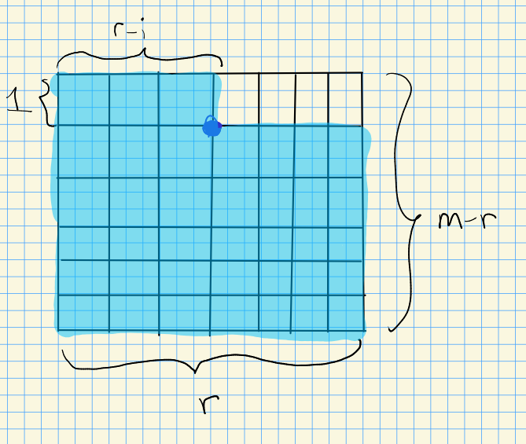

There is a unique way of assigning to each vector bundle ${\mathcal{E}}$ on a $X$ (assumed smooth) a class $c({\mathcal{E}}) = 1 + c_1({\mathcal{E}}) + c_2({\mathcal{E}}) + \cdots \in A(X)$, noting that smooth $X$ guarantees a ring structure on the Chow group. These satisfy

1. (Line bundles): If ${\mathcal{L}}\to X$ is a line bundle then $c({\mathcal{L}}) = 1 + c_1({\mathcal{L}})$ where $c_1({\mathcal{L}}) \in A^1(X)$ is the class of the divisor of zeros minus the divisor of poles of any rational section of ${\mathcal{L}}$, defined up to rational equivalence in $A(X)$.
2. (Degeneracy locus): If $\sigma_0, \cdots, \sigma_{r-i}$ are global sections of ${\mathcal{E}}$ and the degeneracy/dependence locus $Y_{ \sigma} \subseteq X$ has codimension $i$, then $c_i({\mathcal{E}}) = [X_{ \sigma} ] \in A^i(X)$
3. (Whitney’s formula): If $0 \to {\mathcal{E}}\to {\mathcal{F}}\to {\mathcal{G}}\to 0$ is a SES in ${ {\mathsf{Bun}}\qty{\operatorname{GL}_r} }_{/ {X}}$, then $c({\mathcal{F}}) = c({\mathcal{E}})c({\mathcal{G}}) \in A(X)$.
4. (Functoriality/compatibility with pullback): If $\phi:X\to Y$ then $\phi^*(c({\mathcal{E}})) = c(\phi^*({\mathcal{E}}))$.

This induces a map $c: {\mathsf{K}}(X) \to A(X)$. Note that you can compose this with the cycle class map $A(X)\to H^*_{{\mathrm{sing}}}(X)$.

## 28.2 Singular Cohomology

> See Anderson-Fulton.

We can define a total Chern class $c({\mathcal{E}}) = \sum_i c_i({\mathcal{E}}) u^i \in R[u]$ for $R\mathrel{\vcenter{:}}= H^*_{{\mathrm{sing}}}(X)$.

Setup: take $X$ paracompact and Hausdorff/T2, which will be necessary for partitions of unity. For ${\mathcal{E}}\xrightarrow{\pi} X \in { {\mathsf{Bun}}\qty{\operatorname{GL}_r} }({\mathbb{C}})_{/ {X}}$, there exist $c_i({\mathcal{E}})\in H^{2i}(X)$ satisfying

1. If $f:X\to Y \in {\mathsf{Top}}$ then $f^*(c_i({\mathcal{E}})) = c_i(f^* {\mathcal{E}})$.
2. $c_i({\mathcal{E}}) = 0$ unless $o\leq i \leq r\mathrel{\vcenter{:}}=\operatorname{rank}({\mathcal{E}})$, and $c_0({\mathcal{E}}) = 1$
3. Exact sequences of vector bundles yield Whitney’s formula.

If additionally $X$ is smooth,

4. If ${\mathcal{L}}, {\mathcal{M}}$ are line bundles, then $c_1({\mathcal{L}}\otimes{\mathcal{M}}) = c_1({\mathcal{L}}) + c_1({\mathcal{M}})$.
5. If $s:X\to {\mathcal{L}}$ is a nonzero section, writing $Z(s) \subseteq X$ for its zero set, $[Z(s)] = c_1({\mathcal{L}}) \in H^2(X)$.
6. For the projectivization $\pi: {\mathbb{P}}({\mathcal{E}})\to X$, there is a Poincaré duality: considering ${\mathcal{O}}(-1) \subseteq \pi^* {\mathcal{E}}$ and its dual ${\mathcal{O}}(1)$,
   $$\begin{align*}
   H^*({\mathbb{P}}({\mathcal{E}})) = H^*(X)[\zeta] / \left\langle{ \zeta^r - c_1({\mathcal{E}} {}^{ \vee })\zeta^{r-1} + \cdots + (-1)^r c_r({\mathcal{E}} {}^{ \vee }) }\right\rangle
   .\end{align*}$$

> This is the tautological bundle, to be continued on Friday!

# 29 Friday, November 05

> References: Chriss-Ginzburg (for an introduction), Fulton’s *Intersect Theory* (does a lot).

Today: Borel-Moore homology. For example, characteristic cycles of $D{\hbox{-}}$modules live here. Useful because e.g. $H_*({\mathbb{C}}; {\mathbb{Z}}) = {\mathbb{C}}[0]$, which doesn’t see that $\dim_{\mathbb{R}}{\mathbb{C}}= 2$. On the other hand, $\mkern 1.5mu\overline{\mkern-1.5muH\mkern-1.5mu}\mkern 1.5mu_*({\mathbb{C}}; {\mathbb{Z}}) = {\mathbb{C}}[2]$, where $\mkern 1.5mu\overline{\mkern-1.5muH\mkern-1.5mu}\mkern 1.5mu_*$ denotes taking Borel-Moore homology. It turns out that if $X$ is compact, then $\mkern 1.5mu\overline{\mkern-1.5muH\mkern-1.5mu}\mkern 1.5mu_* \cong H_*$.

If $X \hookrightarrow G/P$ be a closed embedding, or more generally $X\hookrightarrow M$ for $M$ any smooth complex manifold (or quasiprojective variety?) with $\dim_{\mathbb{C}}M = n$, define
$$\begin{align*}
\mkern 1.5mu\overline{\mkern-1.5muH\mkern-1.5mu}\mkern 1.5mu_k(X) \mathrel{\vcenter{:}}= H^{2n-k}(G/P, (G/P)\setminus X)
.\end{align*}$$

Goal: show this homology contains certain fundamental classes in top degree $[X] \in \mkern 1.5mu\overline{\mkern-1.5muH\mkern-1.5mu}\mkern 1.5mu_{2n} (X)$.

There is a group morphism, the **cycle class map**,
$$\begin{align*}
{ \operatorname{cl}} : A_*(X) \to\mkern 1.5mu\overline{\mkern-1.5muH\mkern-1.5mu}\mkern 1.5mu_*(X)
,\end{align*}
such that$$

- ${ \operatorname{cl}}$ is compatible with proper pushforward, i.e. covariant with respect to proper morphisms. When $X \xrightarrow{f} Y$ is proper, consider the pushforwards $f_*: A_*(X) \to A_*(Y)$ and $f_*' \mkern 1.5mu\overline{\mkern-1.5muH\mkern-1.5mu}\mkern 1.5mu_*(X) \to \mkern 1.5mu\overline{\mkern-1.5muH\mkern-1.5mu}\mkern 1.5mu_*(Y)$. For $Z \subseteq X$, we can write
  $$\begin{align*}
  f_*[Z] =
  \begin{cases}
  d [f(Z)] & { \left.{{f}} \right|_{{Z}} } \text{ degree } d
  \\
  0 & \text{else}.
  \end{cases}
  .\end{align*}$$
- ${ \operatorname{cl}}$ is compatible with Chern classes of vector bundles.

Fulton sets up $A_*$ to mimic Borel-Moore homology.

If $\dim_{\mathbb{C}}(X) = n$ then $\mkern 1.5mu\overline{\mkern-1.5muH\mkern-1.5mu}\mkern 1.5mu_{>2n}(X) = 0$ and $\mkern 1.5mu\overline{\mkern-1.5muH\mkern-1.5mu}\mkern 1.5mu_{2n}(X; {\mathbb{Z}})$ is a free abelian group with one generator for each irreducible component of $X$.

On restrictions to opens: Let $U \hookrightarrow X$ be open with $X \hookrightarrow G/P$ closed, so that $Y\mathrel{\vcenter{:}}= X\setminus U \hookrightarrow X$ is closed. Then $U \subset (G/P)\setminus Y = (G/P) \setminus(X\setminus U) \subseteq G/P$ is open. A mnemonic:

[figure not shown]

> Link to Diagram

Then
$$\begin{align*}
\qty{ (G/P)\setminus Y, (G/P\setminus Y)\setminus U } \subseteq \qty{ G/P, (G/P)\setminus X}
,\end{align*}
which yields a map
\begin{align*}
\mkern 1.5mu\overline{\mkern-1.5muH\mkern-1.5mu}\mkern 1.5mu_k(X) = H^{2n-k}(G/P, (G/P)\setminus X) \to
H^{2n-k}((G/P)\setminus Y, (G/P \setminus Y) \setminus U) = \mkern 1.5mu\overline{\mkern-1.5muH\mkern-1.5mu}\mkern 1.5mu_k(U)
.\end{align*}$$

using that a subvariety of a smooth variety is again smooth of the same dimension. So we have a map $\mkern 1.5mu\overline{\mkern-1.5muH\mkern-1.5mu}\mkern 1.5mu_k(X) \to \mkern 1.5mu\overline{\mkern-1.5muH\mkern-1.5mu}\mkern 1.5mu_k(U)$, and this yields a LES:

For $U \subseteq X$ closed with $X \subseteq G/P$ and $Y\mathrel{\vcenter{:}}= X\setminus U$, there is a LES corresponding to
$$\begin{align*}
(G/P) \setminus X \subseteq (G/P) \setminus Y \subset G/P
,\end{align*}
given by$$

[figure not shown]

> Link to Diagram

For $\mkern 1.5mu\overline{\mkern-1.5muH\mkern-1.5mu}\mkern 1.5mu$, this corresponds to

[figure not shown]

> Link to Diagram

Recall that for $B \subseteq A \subseteq X$, we got an inclusion of pairs $(A, B) \subseteq (X, B) \subseteq (X, A)$. Also note that we used
$$\begin{align*}
(G/P) \setminus X = ( (G/P) \setminus Y)\setminus U
\end{align*}
where \(Y \mathrel{\vcenter{:}}= X\setminus U\).$$

Let $Y$ be the singular locus of $X$ with $n\mathrel{\vcenter{:}}=\dim_{\mathbb{C}}X$, then

- $Y \subseteq X$ is closed, and
- $\dim_{\mathbb{C}}Y < \dim_{\mathbb{C}}X$ is strictly smaller.

Strategy: induct on $\dim X$ and use the LES applied to $U \mathrel{\vcenter{:}}= X\setminus Y$ and $Y$. Note that $U$ is smooth. We have
$$\begin{align*}
\mkern 1.5mu\overline{\mkern-1.5muH\mkern-1.5mu}\mkern 1.5mu_{2n}(Y) \to \mkern 1.5mu\overline{\mkern-1.5muH\mkern-1.5mu}\mkern 1.5mu_{2n}(X) \to \mkern 1.5mu\overline{\mkern-1.5muH\mkern-1.5mu}\mkern 1.5mu_{2n}(U) \xrightarrow{\delta} \mkern 1.5mu\overline{\mkern-1.5muH\mkern-1.5mu}\mkern 1.5mu_{2n-1}(Y)
,\end{align*}
and \(\mkern 1.5mu\overline{\mkern-1.5muH\mkern-1.5mu}\mkern 1.5mu_{2n}(Y) = 0\) since \(\dim Y < 2n\) and \(\mkern 1.5mu\overline{\mkern-1.5muH\mkern-1.5mu}\mkern 1.5mu_{2n-1}(Y) = 0\) for the same reason, making the middle map an isomorphism. Write \(U = \displaystyle\coprod_{0\leq i\leq \ell} U_i\) as a union of irreducible (so connected) components. Then
\begin{align*}
\mkern 1.5mu\overline{\mkern-1.5muH\mkern-1.5mu}\mkern 1.5mu_{2n}(U) = H^{2n-2n}(U, U \setminus U) = H^0(U) = {\mathbb{Z}}{ {}^{ \scriptscriptstyle\oplus^{\ell} } }
\end{align*}
where we can choose to embed \(U \hookrightarrow U\) into itself since \(U\) is smooth. Any Zariski open has to intersect every irreducible component, so each such component yields a fundamental class.$$

# 30 Monday, November 08

Today: Poincaré duality, relates to *smooth* loci, and rational (i.e. ${\mathbb{Q}}$) smoothness. Take all varieties to be quasiprojective subvarieties of a flag variety $G/B$.

From algebraic topology, there is a relative cup product in singular cohomology:
$$\begin{align*}
\smile: H^i(X, U; {\mathbb{Z}}) \otimes_{\mathbb{Z}}H^j(X, U; {\mathbb{Z}}) \to H^{i+j}(X, U_1\cup U_2)
.\end{align*}
Even better, we have a pairing with Borel-Moore homology for \(Y \leq X\) a closed subvariety:
\begin{align*}
\frown: H^j(X, X\setminus Y) \otimes_{\mathbb{Z}}\mkern 1.5mu\overline{\mkern-1.5muH\mkern-1.5mu}\mkern 1.5mu_j(X) &\to \mkern 1.5mu\overline{\mkern-1.5muH\mkern-1.5mu}\mkern 1.5mu_{j-i}(Y)
.\end{align*}
This yields
\begin{align*}
\frown: H^j(X, X\setminus Y) \otimes H^{2n-j}(G/P, (G/P)\setminus X) \to H^{2n-j+i}(G/P, (G/P) \setminus Y)
.\end{align*}
Think of \(H^j(A, B)\) as chains in \(A\) vanishing along \(B\):$$

[figure not shown]

For $X$ smooth and irreducible, capping against the fundamental class induces an isomorphism
$$\begin{align*}
H^i(X) &{ { \, \xrightarrow{\sim}\, }}H_{2n-i}(X) \\
\alpha &\mapsto \alpha \frown[X]
,\end{align*}
which is induced by
\begin{align*}
H^i(X) \times \mkern 1.5mu\overline{\mkern-1.5muH\mkern-1.5mu}\mkern 1.5mu_{2n}(X) &\to \mkern 1.5mu\overline{\mkern-1.5muH\mkern-1.5mu}\mkern 1.5mu_{2n-i}(X) \\
(\alpha, [X]) &\mapsto \alpha \frown[X]
.\end{align*}$$

Recall that there is an affine stratification $G/P_Y = \displaystyle\coprod_{w\in W^Y} BwP_Y/P_Y$, and
$$\begin{align*}
\mkern 1.5mu\overline{\mkern-1.5muH\mkern-1.5mu}\mkern 1.5mu_{2k} (G/P) = \bigoplus_{\substack{ w\in W^Y \\ \ell(w) = k }} {\mathbb{Z}}[X_w^Y]
.\end{align*}
Pulling back along the isomorphism there is some element such that \(d_{X_w^Y} \frown[G/P] = [X_w^Y]\), so we often identify \(d_{X_w^Y} = [X_w^Y]\).$$

An alternative perspective on Chern classes: compose the maps

[figure not shown]

> Link to Diagram

Here $Z(s)$ is the zero divisor of a section $s$ coming from the class of a bundle in ${\mathsf{K}}(X)$. For a line bundle ${\mathcal{L}}$, we have $c_1({\mathcal{L}}) \in A^1(X) { { \, \xrightarrow{\sim}\, }}\mkern 1.5mu\overline{\mkern-1.5muH\mkern-1.5mu}\mkern 1.5mu_{2n-2} { { \, \xrightarrow{\sim}\, }}H^2(X)$.

TFAE:

- $H^i(X, X\setminus\left\{{x}\right\} ) = {\mathbb{Q}}[2n]$
- ${\mathbb{R}}{{\Gamma}\qty{X, \operatorname{\mathcal{IC}}_X} } = {\mathbb{Q}}[0]$

Mentioned by Geordie: $\operatorname{\mathcal{IC}}_X \cong {\mathbb{Q}}_X$, the constant sheaf.

Let
$$\begin{align*}
f(x,y,z) = x^3 + y^3 - xyz
.\end{align*}
Let \(X\mathrel{\vcenter{:}}= V(f) \subseteq {\mathbb{P}}^2_{/ {{\mathbb{C}}}}\), and define
\begin{align*}
\xi: {\mathbb{P}}^1_{/ {{\mathbb{C}}}} &\to X \\
[a: b] &\mapsto [ab^2: a^2b : a^3 + b^3]
.\end{align*}$$

Check that this is well-defined:
$$\begin{align*}
(ab^2)^3 + (a^2b)^3 - a^3b^3 (a^3 + b^3)
.\end{align*}
Note \(\xi\) is projective and thus proper, and finite since it is quasifinite (finite fibers). One can check
\begin{align*}
\xi^{-1}[0:0:1] &= \left\{{ [0:1], [1:0] }\right\} \\
\xi^{-1}[x:y:z] &= \left\{{{\operatorname{pt}}}\right\}
.\end{align*}$$

Check that $\xi$ is birational.

Thus $\xi$ is the normalization of $X$, but isn’t an isomorphism, so smoothness must fail.

Is $X$ *rationally* smooth?

Since $X$ is compact, $\mkern 1.5mu\overline{\mkern-1.5muH\mkern-1.5mu}\mkern 1.5mu_k(X) { { \, \xrightarrow{\sim}\, }}H_k(X)$. Since $X$ is connected we get $H^0 = {\mathbb{Q}}$, and by duality $H^2(X) \cong H_2(X) \cong \mkern 1.5mu\overline{\mkern-1.5muH\mkern-1.5mu}\mkern 1.5mu_2(X) \cong {\mathbb{Q}}$, we have $H^k(X) = {\mathbb{Q}}[0] \oplus {\mathbb{Q}}[1] \oplus {\mathbb{Q}}[2]$. Note that the Poincaré polynomial $p(q) = 1 + q + q^2$ has symmetric coefficients. What this morphism looks like:

[figure not shown]

$X$ is not rationally smooth.

By the projection formula,
$$\begin{align*}
\xi_*(\xi^* \alpha\frown\beta) = \alpha\frown\xi_* \beta
.\end{align*}
Let \(\alpha \in H^1(X)\) be nonzero, then
\begin{align*}
\alpha\frown[X] = a \frown\xi_* [ {\mathbb{P}}^1] = \xi_*(\xi^* \alpha \frown[{\mathbb{P}}^1] )
.\end{align*}
Since \(\xi\) is birational, \(\xi_* [{\mathbb{P}}^1] = [X]\) and \(H^k({\mathbb{P}}^1) = {\mathbb{Q}}[0] \oplus {\mathbb{Q}}[2]\). Rationally smooth implies PD, and since PD doesn’t hold here we can’t have rational smoothness.$$

# 31 Friday, November 12

Let $G\curvearrowright X \in {\mathsf{{\mathbb{C}}}{\hbox{-}}\mathsf{Mod}}^{\dim = n}$ be a linear algebraic group acting on a ${\mathbb{C}}{\hbox{-}}$module of dimension $n$, then there is a morphism $G\to \operatorname{GL}_n$ and we’ll regard $G \subseteq \operatorname{GL}_n$. Then $G\curvearrowright{\mathbb{P}}^n$:

- ${\mathbb{P}}(V) = \leftquotient{{\mathbb{C}}^{\times}}{V\setminus\left\{{0}\right\}}$, and $G$ acts linearly and commutes with scalar multiplication.
- ${\mathbb{P}}(V) = \operatorname{GL}_n / P$ and the $G{\hbox{-}}$action descends since the projection $\operatorname{GL}_n\to \operatorname{GL}_n/P$ is $\operatorname{GL}_n{\hbox{-}}$equivariant.

Note that $G$ also acts on the tautological bundle ${\mathcal{O}}(-1)$, since these are lines. We can write ${\mathcal{O}}(-1) = \operatorname{GL}_n \overset{\scriptscriptstyle {P} }{\times} {\mathbb{C}}_{{\left[ {1,0,\cdots, 0} \right]}}$, using the identification $X^*(T) = {\mathbb{Z}}{ {}^{ \scriptscriptstyle\times^{n} } }$ and taking the character associated to ${\left[ {t_1,\cdots, t_n} \right]}\mapsto t_1$. Note that ${\mathcal{O}}(-1) \to\operatorname{GL}_n/P$ is $\operatorname{GL}_n$ equivariant. Write $\zeta \mathrel{\vcenter{:}}= c_1^G({\mathcal{O}}(1)) \in H_G^2({\mathbb{P}}(V))$ for the equivariant Chern classes.

Recall that if $\operatorname{GL}_n \overset{\scriptscriptstyle {P} }{\times} {\mathbb{C}}_{\lambda} \to \operatorname{GL}_n/P$ for $\lambda \in X^*(T)$ is a $G{\hbox{-}}$equivariant bundle, we can construct $E\overset{\scriptscriptstyle {G} }{\times} \operatorname{GL}_n\overset{\scriptscriptstyle {P} }{\times} {\mathbb{C}}_{\lambda} \to E\overset{\scriptscriptstyle {G} }{\times} \operatorname{GL}_n/P \cong E\overset{\scriptscriptstyle {G} }{\times} \times {\mathbb{P}}^{n-1}$, and the base here corresponds to $H^*_G({\mathbb{P}}^{n-1})$. This induces $E\overset{\scriptscriptstyle {G} }{\times} {\mathbb{P}}^{n-1} \to E/G = {{\mathbf{B}}G}$, where now the base corresponds to $H^*_G({\operatorname{pt}})$.

$$\begin{align*}
H^*_G({\mathbb{P}}(V)) { { \, \xrightarrow{\sim}\, }}H^*_G({\operatorname{pt}})[\zeta] / \left\langle{\sum_{k=0}^n c_k \zeta^{n-k}}\right\rangle
.\end{align*}$$

Given ${\mathcal{E}}\to X$, we know $H^*({\mathbb{P}}({\mathcal{E}}))$ in terms of $H^*({\operatorname{pt}})$. We have

[figure not shown]

> Link to Diagram

So $\xi$ is a hyperplane class for a projective bundle, and thus $c_i^G(V) = c_i(E\overset{\scriptscriptstyle {G} }{\times} V)$.

For $G = \operatorname{GL}_n$, we have $H^*_G({\operatorname{pt}}) = {\mathbb{Z}}[c_1,\cdots, c_n] \subseteq {\mathbb{Z}}[t_1,\cdots, t_n] = H^*_T({\operatorname{pt}})$. So $H^*_G {\mathbb{P}}(V) = {\mathbb{Z}}[c_1,\cdots, c_n][\zeta]/\left\langle{\zeta^n + c_1\zeta^{n-1} + \cdots + c_n}\right\rangle$.

For $G=T$, $H^*_T({\mathbb{P}}(V)) = {\mathbb{Z}}[t_1,\cdots, t_n][\zeta] / \left\langle{\prod_{1\leq i \leq n} \zeta + t_i}\right\rangle$ where $c_i^T(V) = e_2(t_1,\cdots, t_n)$.

Let $X$ be an $n{\hbox{-}}$dimensional smooth algebraic variety with finitely many $T{\hbox{-}}$fixed points. Write $X^T$ for the fixed point locus, write $c \mathrel{\vcenter{:}}=\prod_{p\in X^T} c_n^T({\mathbf{T}}_p X) \in H^*_T({\operatorname{pt}})$, noting that since $X$ is smooth these are all the same dimension. Let $S \subseteq H^*_T({\operatorname{pt}})$ be a multiplicative set containing $c$, which is nonzero since the fixed points are isolated. Assume there are $m\leq {\sharp}X^T$ classes in $H_T^*(X)$ restricting to a basis of $H^*(X)$. Then there are isomorphisms induced by
$$\begin{align*}
H^*_T(X) \left[ { \scriptstyle { {S}^{-1}} } \right] &\xrightarrow{S^{-1}i^*} H^*_T(X^T) \left[ { \scriptstyle { {S}^{-1}} } \right] \\
H^*_T(X^T) \left[ { \scriptstyle { {S}^{-1}} } \right] &\xrightarrow{S^{-1}i_*} H^*_T(X) \left[ { \scriptstyle { {S}^{-1}} } \right]
.\end{align*}
Note that \(X^T \xrightarrow{i} X\) is \(T{\hbox{-}}\)equivariant, so \(i^*\) on \(H^*\) descends to \(H_T^*\). By Poincaré duality, we get \(\mkern 1.5mu\overline{\mkern-1.5muH\mkern-1.5mu}\mkern 1.5mu(X^T) \to \mkern 1.5mu\overline{\mkern-1.5muH\mkern-1.5mu}\mkern 1.5mu(X)\). Without the localization, there is still an injection:
\begin{align*}
H_T^*(X) \xrightarrow{\iota^*} H^*_T(X^T) = \bigoplus H^*_T({\operatorname{pt}})
.\end{align*}$$

Note that $H^*_T({\operatorname{pt}}; {\mathbb{Z}}) = {\mathbb{Z}}[t_1,\cdots, t_n]$ and $H^*({\operatorname{pt}}; {\mathbb{C}}) = {\mathbb{C}}[t_1,\cdots, t_n] = S({\mathfrak{h}} {}^{ \vee })$, the symmetric algebra on the Cartan. This comes up when looking at Soergel bimodules. Compare to ${\mathsf{K}}^T({\operatorname{pt}}) = R(T)$, the representation ring.

For projective space, let $T$ be any torus that acts linearly on a $n{\hbox{-}}$dimensional ${\mathbb{C}}{\hbox{-}}$module. Then $V = \bigoplus_i C_{\lambda_i}$ for some characters $\lambda_i$. Assume the $\lambda_i$ are distinct, then
$$\begin{align*}
H^*_T({\mathbb{P}}^{n-1}) = H^*_T({\operatorname{pt}})[\zeta]/\left\langle{\prod \zeta + \lambda_i}\right\rangle
,\end{align*}
where \(\zeta = c_1^T({\mathcal{O}}(1))\). So write \(X^T\) as the set of coordinate lines for \(X = {\mathbb{P}}^{n-1} = {\mathbb{P}}(V)\), i.e. for \(p_i\mathrel{\vcenter{:}}={\left[ {0,0,\cdots, 0,1,0,\cdots,0} \right]}\), \(X^T = \left\{{p_1,\cdots, p_n}\right\}\). The tangent spaces are given by \({\mathbf{T}}_{p_i} {\mathbb{P}}^{n-1} = \bigoplus_{j\neq i} {\mathbb{C}}_{\lambda_j - \lambda_i} = {\mathbf{T}}_{p_i} U_i\) where \(U_i \cong {\mathbb{C}}^{n-1}\) by dividing out by the \(i\)th coordinate, so
\begin{align*}
t{\left[ {x_1: \cdots : 1:\cdots x_n} \right]}
&= {\left[ {t_1x_1: \cdots : t_i \cdot 1: \cdots t_n x_n } \right]} \\
&= {\left[ {{t_1\over t_i} x_1 : \cdots: 1 : \cdots {t_n \over t_i} x_n} \right]}
.\end{align*}
Thus \((\lambda_j - \lambda_i)(t) = t_1/t_i\). Thus \(c_{n-1}^T({\mathbf{T}}_{p_i} {\mathbb{P}}^{n-1}) = \prod_{j\neq i} (\lambda_j - \lambda_i)\).$$

A self-intersection formula: if $i:Y\hookrightarrow X$ is a closed embedding of codimension $d$ with normal bundle $N$ of rank $d$, then
$$\begin{align*}
i^* i_* ( \alpha) = c_d(N) \alpha
.\end{align*}$$

Show that the following composite is diagonal:
$$\begin{align*}
H_T{ {}^{ \scriptscriptstyle\oplus^{n} } } \to H_T({\mathbb{P}}^{n-1}) \to H_T{ {}^{ \scriptscriptstyle\oplus^{n} } }
.\end{align*}
What is the determinant?$$

# 32 Monday, November 22

Considering the infinite dimensional case, $\tilde A_2$. Here $W = W(\tilde A_2) = \left\langle{s_1,s-2,s_3 {~\mathrel{\Big\vert}~}s_i^2=1, (s_i s_j)^3=1}\right\rangle$, and we can form $X_w \subseteq G/B$ for any $w\in W$. This will be a finite dimensional projective variety with a Torus action, and there are BSDH resolutions for reduced words given by $T{\hbox{-}}$equivariant maps
$$\begin{align*}
P_{i_1}\overset{\scriptscriptstyle {B} }{\times} \cdots P_{i_n}/B \xrightarrow{\mu} X_w
.\end{align*}
These are resolutions of singularities, and in particular birational. Note that \(W\) is infinite here.$$

Article by Graham-Li: say $w\in W$ is **spiral** iff $w = (s_j s_j s_k)^\ell$ for $i,j,k \in \left\{{1,2,3}\right\}$. This produces a nice family of Schubert varieties. For $\operatorname{rank}A = 2$, we have $\dim {\mathfrak{h}}= 3+1=4$. Up to a change of coordinates, we can use $\alpha_1 {}^{ \vee }= {\left[ {1,0} \right]}^t$ and $\alpha_2 {}^{ \vee }= {\left[ {1,0} \right]}^t$ and let $V \mathrel{\vcenter{:}}= R \otimes_{\mathbb{Z}}\left\{{\alpha_1 {}^{ \vee }, \alpha_2 {}^{ \vee }}\right\}$ be the ambient Euclidean space and set $L\mathrel{\vcenter{:}}={\mathbb{Z}}\left\langle{ \alpha_1, \alpha_2}\right\rangle$. Then use the action of $W$ to define $W_{\text{aff}} \mathrel{\vcenter{:}}= L \rtimes W_f$ where $W_f = W(A {}^{ \vee })$, and $s_i(\chi) = \chi - {\left\langle { \alpha, \lambda},~{\alpha} \right\rangle} {}^{ \vee }$. Here we think of $L$ as translations. The dual roots are $\alpha_1 = {\left[ {2, -1} \right]}^t. \alpha_2 = {\left[ {-1, 2} \right]}$ and so $\tilde \alpha = \alpha_1 + \alpha_2 = {\left[ {1,1} \right]}^t$ Define hyperplanes $H_{\alpha, n} \mathrel{\vcenter{:}}=\left\{{v\in V {~\mathrel{\Big\vert}~}{\left\langle {\alpha},~{v} \right\rangle} = n \in {\mathbb{Z}}}\right\}$. There is a *fundamental alcove* enclosed by the positive sides of the various hyperplanes and within distance 1 of $H_{\tilde \alpha, 0}$. If you draw the picture and now act on the fundamental alcove by simple reflections, the image “spirals” out away from the origin.

The article doesn’t use BSDH resolutions, maybe compare and contrast with what we’ve done.

Back to $\mu$. For $\ell = 1$, we have
$$\begin{align*}
P_1 \overset{\scriptscriptstyle {B} }{\times} P_2 \overset{\scriptscriptstyle {B} }{\times} P_3/B \xrightarrow{\mu} X_w
.\end{align*}$$

The Bruhat order yields

[figure not shown]

> Link to Diagram

Note that there are no braid relations. We can consider the $T{\hbox{-}}$equivariant multiplicity ${\mathcal{E}}_x^T X_w = \sum_{z\in \mu^{-1}(x)^T} {\mathcal{E}}_z^T(z)$ given by summing over the $T{\hbox{-}}$equivariant fixed points in the fiber. Here this just equals ${\mathcal{E}}_z^T(z)$ where $\mu(z) = x$, since there is a unique $T{\hbox{-}}$fixed point in the fiber. A basic AG argument shows that the resolution is an isomorphism and thus $X_w$ is smooth, so there is no singular locus. The paper gives a nice formula for $\ell \geq 6$.

Starting the calculation:

1. Consider $e_x X_w\in \operatorname{ff}(S({\mathfrak{h}} {}^{ \vee }))$ the equivariant multiplicity, then $x\in X_w$ is smooth iff a certain change of basis $c_{w, x}$ corresponds to the equivariant multiplicity.
2. In the rationally smooth locus, they show smoothness iff there is a single $T{\hbox{-}}$fixed point in the fiber.

# 33 Sasha’s Talk (Monday, November 29)

Topic: Segal-Sagawara construction. Define $\mathrm{Witt} = \operatorname{Lie}(\operatorname{Diff}^+ S^1)$, regarded as polynomial vector fields on $S^1$. $H^2(\mathrm{Witt}; {\mathbb{C}}) = {\mathbb{C}}$, so there is a 1-dimensional space of central extensions, with a distinguished one: the Virasoro algebra. There is a SES $0 \to{\mathbb{C}}\mathrm{charge} \to \mathrm{Vir} \to \mathrm{Witt}\to 0$, and for $LG\mathrel{\vcenter{:}}= C^\infty(S^1, G)$, a SES $0\to S^1 \to \tilde{LG} \to LG\to 0$. Here $\mathrm{charge}$ is some distinguished central element. Does the Virasoro group act on this extension? Not quite, but almost – pass to Lie algebras to get $0\to {\mathbb{C}}\to \tilde{L{\mathfrak{g}}}\to {\mathfrak{g}}\to 0$. Theorem: for $\rho: \tilde{L{\mathfrak{g}}} \to \mathop{\mathrm{End}}_{\mathbb{C}}(V)$ an admissible representation, there is a representation $\rho': \mathrm{Vir}\to \mathop{\mathrm{End}}_{\mathbb{C}}(V)$. Note $L{\mathfrak{g}}\mathrel{\vcenter{:}}={\mathfrak{g}}\otimes_{\mathbb{C}}{\mathbb{C}}[t, t^{-1}]$. Write $X_i \left\langle{m}\right\rangle \mathrel{\vcenter{:}}= X_i\otimes m$.

Admissible representations: for all $v\in V$ and $X\in{\mathfrak{g}}$, there exists an $m$ such that $\rho(X\left\langle{m}\right\rangle)(v) = 0$. Define the Casimir element $\sum_i X_i X^i \in Z({\mathcal{U}}({\mathfrak{g}}))$. Levels: level $\ell$ if $\mathrm{charge}$ acts by $\ell \cdot \operatorname{id}$. Critical level: $\ell \neq \cdots$ some constant (roughly the dual Coxeter number), avoid this $\ell$ for the reps in the theorem statement.

# 34 Appendix: Preliminary Notions

To define

- Sheaves
  - Coherent sheaves
- Complete variety
- Homogeneous variety
- Algebraic group
  - Morphisms of algebraic groups
  - Reductive group
- Borel
- Parabolic
- Equivariant
- ${\mathbf{B}}G$
  - Some examples? ${\mathbb{CP}}^\infty, {\mathbf{B}}\operatorname{GL}_n({\mathbb{R}})$, etc.
- ${\mathsf{K}}{\hbox{-}}$theory of an abelian category.
- Segre embedding
- Weyl group
- Modular representation
- Polar variety
- Chern class
- Borel-Moore homology
- Relative homology
- Ind-varieties and Ind-schemes

# 35 Bibliography

[^1]: So the simple reflection changes the sign of only the corresponding simple root, and preserves the sign of all other simple roots.
[^2]: See Fulton for an explicit description, taking a Plucker embedding and studying actual equations.
[^3]: Zariski locally trivial implies étale locally trivial.
[^4]: Note that ${\mathsf{Alg}}{\mathsf{Grp}}_{/ {{\mathbb{C}}}} \leq \operatorname{Lie}{\mathsf{Grp}}$!